# Reactive Oxygen Species Production and Scavenging; Genomic Patterns Across Marine Phytoplankton

Naaman M. Omar<sup>1</sup>, Katherine Fleury<sup>1,2</sup>, Brian Beardsall<sup>1,3</sup>, Ondřej Prášil<sup>4</sup>, and Douglas A. Campbell<sup>1,✉</sup>

2022-06-06

<sup>1</sup> Department of Biology, Mount Allison University, 53 York St., Sackville NB, Canada, E4L 1C9.  
<sup>2</sup> Faculty of Veterinary Medicine, University of Calgary, 3280 Hospital Dr NW, Calgary, AB, T2N 4Z6.  
<sup>3</sup> Faculty of Computer Science, Dalhousie University, 6050 University Ave, Halifax, NS, B3H 1W5.  
<sup>4</sup> Center Algatech, Laboratory of Photosynthesis, Novohradska 237, Trebon, CZ 37981, Czech Republic.

<sup>✉</sup> Correspondence: Douglas A. Campbell <dcampbel@mta.ca>

# Abstract

Marine phytoplankton both produce and scavenge Reactive Oxygen Species (ROS), to support cellular processes, while limiting damaging reactions. Some prokaryotic picophytoplankton have lost all genes encoding capacity to scavenge hydrogen peroxide and rely upon co-occurring cells to scavenge hydrogen peroxide. Such losses of metabolic function can only apply to those ROS, including hydrogen peroxide, which potentially traverse the cell membrane, before provoking excessive damaging intracellular reactions. We therefore hypothesized that cell radius influences which elements of ROS metabolism can potentially be out-sourced to co-occurring cells. We investigated genomes and transcriptomes from diverse eukaryotic phytoplankton, ranging from 0.4 to 44 µm radius, to analyze the genomic allocations to produce enzymes metabolizing three distinct ROS. Superoxide has high reactivity, short intracellular and extracellular lifetimes and limited membrane permeability. Genes encoding superoxide scavenging were ubiquitous, but the fractional gene allocation decreased with increasing cell radius, consistent with superoxide metabolism served by a nearly fixed set of core genes, scavenging intracellular and extracellular superoxide pools, separated by the cell membrane. Hydrogen peroxide has lower reactivity, longer intracellular and extracellular lifetimes and readily crosses cell membranes. Eukaryotic phytoplankton genomic allocations to hydrogen peroxide production decrease with increasing cell radius, more than do genomic allocations to scavenging of hydrogen peroxide, consistent with maintenance of ROS homeostasis in the face of slower diffusional losses of hydrogen peroxide from larger cells. Gene allocations to hydrogen peroxide metabolism are influenced by capacity for colony formation, suggesting more active hydrogen peroxide metabolism among the closely spaced cells of colonies compared to single cells; and by presence of flagella suggesting a role in maintenance of ROS homeostasis. Nitric Oxide has low reactivity, long intracellular and extracellular lifetimes and readily crosses cell membranes. Neither nitric oxide production nor scavenging genomic capacities changed with increasing cell radius. Centric vs. pennate diatoms, however, show contrasting gene allocations to nitric oxide metabolism, consistent with diverse regulatory roles of nitric oxide across taxa.

# Introduction

Phytoplankton cells span a large size range, from picoplankton (<2µm), nanoplankton (2 to 20µm), microplankton (20 to 200µm) to macroplankton (200 to <2000µm) [1]. Cell size interacts with multiple selective pressures, including cellular metabolic rate, light absorption, nutrient uptake, cell nutrient quotas, trophic interactions and diffusional exchanges with the environment [1–3]. For example smaller cells absorb more light per pigment content because they suffer less from internal self-shading [4], but small cells can be more prone to grazing by some microzooplankton [5]. Beyond simple size, cells of different shapes differ in surface area to volume ratio. For example, more elongated cells, such as pennate diatoms, have a larger surface area to volume ratio compared to more rounded cells, such as centric diatoms, of equivalent biovolume [6], which can in turn influence diffusional exchanges between cells and their environment.

## Characteristics of Reactive Oxygen Species

Phytoplankton both produce and scavenge Reactive Oxygen Species (ROS), both within and outside the cell membrane. Some ROS readily cross the cell membrane, connecting intra- and extra-cellular pools. Other ROS rarely cross cell membranes and therefore intra- and extra-cellular pools are not directly connected (Table 1).

Table 1: Diffusion and Stability of Different ROS

| ROS | ROSSymbol | SeawaterLow_M | SeawaterHigh_M | ConcentrationCitation | DiffusionDistance_nm | DiffusionDistanceCitation | LifetimeLow_s | LifetimeHigh_s | LifetimeCitation | CrossesCellMembrane | CrossesCellMembraneCitation | AbioticProductionLow_Ms<sup>-1</sup> | AbioticProductionHigh_Ms<sup>-1</sup> | AbioticProductionRatesCitation | DiffCoef_um<sup>2</sup>us | DiffCoefCitation |
| --- | --- | --- | --- | --- | --- | --- | --- | --- | --- | --- | --- | --- | --- | --- | --- | --- |
| Hydrogen Peroxide | H<sub>2</sub>O<sub>2</sub> | 1e-09 | 1e-06 | [7,8] | NA | NA | 3.6e+03 | 1.2e+05 | [7–9] | Yes | [10–13] | 1e-13 | 1e-11 | [14] | 1500 | [15] |
| Superoxide | O<sub>2</sub><sup>•−</sup> | 1e-12 | 1e-09 | [7,16] | 320 | [9] | 1.0e-03 | 6.0e+01 | [7,16] | No | [17] | 1e-14 | 1e-10 | [14] | 210 | [18] |
| Nitric Oxide | NO<sup>•</sup> | 1e-12 | 1e-10 | [16,19] | NA | NA | 2.0e+00 | 2.0e+01 | [16,20] | Yes | [21] | 1e-13 | 1e-11 | [16] | 2210 | [22] |
| Hydroxyl Radical | HO<sup>•</sup> | 1e-18 | 1e-15 | [7] | 4.5 | [9] | 1.0e-06 | 1.0e-06 | [7] | NA | NA | NA | NA | NA | NA | NA |
| Singlet Oxygen | <sup>1</sup>O<sub>2</sub> | 1e-13 | 1e-14 | [23] | 82 | [9] | 1.0e-06 | 1.0e-06 | [9] | NA | NA | NA | NA | NA | 2100 | [24] |
| Peroxynitrite | ONOO<sup>−</sup> | 1e-12 | 1e-11 | [16] | NA | NA | 1.0e-03 | 1.0e-03 | [16,25] | Yes | [26] | 1e-11 | 1e-09 | [16] | NA | NA |

Superoxide (O<sub>2</sub><sup>•−</sup>) is a radical anion generated through the monovalent reduction of O<sub>2</sub> to O<sub>2</sub><sup>•−</sup> [27], present in the oceans at concentrations of 10<sup>-12</sup> to 10<sup>-9</sup> [7,16]. O<sub>2</sub><sup>•−</sup> is highly reactive [28] with organic compounds including thiols [29] and metals [30,31] and is indeed believed to be responsible for over half of Fe(III) reduction in the ocean [32]. As the first of ROS species in a sequential series of reductions of O<sub>2</sub>, superoxide is a ‘gateway’ to production of other species of ROS. O<sub>2</sub><sup>•−</sup> is produced as a by-product of enzymatic reactions, and also produced non-enzymatically, both inside and outside a cell, but shows limited diffusion across the hydrophobic cell membrane [17].

Electron transfers to O<sub>2</sub> from multiple sites of the photosynthetic and mitochondrial electron transport chains generate intracellular O<sub>2</sub><sup>•−</sup> as a by-product[33–38]. Multiple oxidases encoded by genes included in this study (Table 4) reduce O<sub>2</sub> and generate either H<sub>2</sub>O [39], or alternately O<sub>2</sub><sup>•−</sup> and/or H<sub>2</sub>O<sub>2</sub> [40,41]. Biogenic production of extracellular ROS mediated by taxa ranging from heterotrophic bacteria to diatoms is significant in marine environments [7,32,42–48]. Increasing cell density leads to decreased superoxide production per cell [47,49,50]. Extracellular superoxide production likely contributes to cell growth, in that the removal of extracellular ROS from cultures of the heterotrophic bacteria *Roseobacter* inhibits its growth [49]. Superoxide in coastal waters is primarily attributable to extracellular production by eukaryotic phytoplankton [51], while *Prochlorococcus* MED4 shows the least extracellular production of O<sub>2</sub><sup>•−</sup> among microbes analyzed to date [47]. Superoxide production patterns vary even within a genus. [46] found three species of *Thalassiosira* produced more extracellular O<sub>2</sub><sup>•−</sup> in the presence of light (dead or alive), showing that within *Thalassiosira* superoxide is formed through passive light driven reactions. *T. pseudonana* and *T. oceanica* produced more O<sub>2</sub><sup>•−</sup> when alive, indicating additional active O<sub>2</sub><sup>•−</sup> production, whereas in *T. weissflogii* extracellular O<sub>2</sub><sup>•−</sup> production did not change between living and dead cells [46].

Two known enzymes mediate conversion of O<sub>2</sub><sup>•−</sup> to H<sub>2</sub>O<sub>2</sub>; the ubiquitous dismutation of O<sub>2</sub><sup>•−</sup> catalyzed by diverse Superoxide Dismutases (SOD) or the less prevalent reduction of O<sub>2</sub><sup>•−</sup>, catalyzed by Superoxide Reductase at the expense of metabolic reductant. O<sub>2</sub><sup>•−</sup> also dismutates spontaneously to produce H<sub>2</sub>O<sub>2</sub> and O<sub>2</sub> [52], although [53] found that ~52% of dark O<sub>2</sub><sup>•−</sup> production instead likely undergoes oxidation back to O<sub>2</sub>. About 1% of O<sub>2</sub><sup>•−</sup> decay in seawater results from O<sub>2</sub><sup>•−</sup> reacting with its protonated conjugate (HOO) [45], but O<sub>2</sub><sup>•−</sup> interactions with species of Cu and Fe are a larger total sink for O<sub>2</sub><sup>•−</sup>[54,55]. Extracellular production of O<sub>2</sub><sup>•−</sup> thus indirectly contributes to extracellular H<sub>2</sub>O<sub>2</sub> [46,47,56,57].

Hydrogen peroxide (H<sub>2</sub>O<sub>2</sub>) is an uncharged compound, present in the ocean at concentrations of 10<sup>-9</sup> to 10<sup>-6</sup> mol L<sup>-1</sup> [7], depending upon location and conditions including temperature, light level, depth of the mixed layer and the concentration of total dissolved organic carbon [58]. In aquatic systems, H<sub>2</sub>O<sub>2</sub> has lifetimes of hours to days (Table 1) [7,9]. H<sub>2</sub>O<sub>2</sub> passively traverses cell membranes [59], primarily through aquaporins [10–13], allowing exchange of intracellular and extracellular pools of H<sub>2</sub>O<sub>2</sub>, although cells can maintain a concentration gradient between internal and external H<sub>2</sub>O<sub>2</sub> [60].

H<sub>2</sub>O<sub>2</sub> is acutely toxic to most cells in the range of 10<sup>-5</sup> to 10<sup>-4</sup> mol L<sup>-1</sup> [59] (Table 1). Although only weakly directly reactive, H<sub>2</sub>O<sub>2</sub> can react with thiols and methionine [29] and can interfere with gene expression [61]. Cytotoxic effects of H<sub>2</sub>O<sub>2</sub>, including lipid damage, are primarily caused by H<sub>2</sub>O<sub>2</sub> dismutating into the hydroxyl radical, which is strongly oxidative [9]. H<sub>2</sub>O<sub>2</sub> concentrations in seawater follow a diurnal cycle with a peak at mid-day [58,62,63], which suggests significant direct or indirect photochemical or photobiological generation of H<sub>2</sub>O<sub>2</sub>. Some marine H<sub>2</sub>O<sub>2</sub> production is indeed linked directly to biological processes, although it is not the dominant source of H<sub>2</sub>O<sub>2</sub> [63] in seawater.H<sub>2</sub>O<sub>2</sub> spontaneously, though slowly, decomposes into water and oxygen [64]. Photochemically driven H<sub>2</sub>O<sub>2</sub> decomposition may account for ~5% of H<sub>2</sub>O<sub>2</sub> decomposition in seawater [65]. Abiotic decomposition of H<sub>2</sub>O<sub>2</sub> can be mediated by interactions with metals. In seawater, H<sub>2</sub>O<sub>2</sub> is indeed found in high enough concentrations to significantly contribute to the redox cycling of copper and iron [66,67].

A significant amount of biotic H<sub>2</sub>O<sub>2</sub> detoxification in aqueous systems may be attributed to heterotroph mediated activity, although heterotrophs do not contribute much of the H<sub>2</sub>O<sub>2</sub> production [68].  
*Prochlorococcus* and some strains of *Synechococcus* lack genes encoding catalase and are therefore difficult to grow in axenic cultures, particularly at high cell densities. Growth and survival of these strains improves when co-cultured with other ‘helper’ bacteria which carry genes for catalase [69–72]. Helper bacteria can be substituted by direct addition of catalase or ROS scavengers to the media to keep H<sub>2</sub>O<sub>2</sub> levels below their toxic threshold. These were found at 5 × 10<sup>5</sup> to 1 × 10<sup>6</sup> *Prochlorococcus* cells mL<sup>-1</sup> * in culture, somewhat higher than typical ocean cell densities of 1 × 10<sup>5</sup> to 3 × 10<sup>5</sup> *Prochlorococcus* cells ml<sup>−1</sup> [73], where auto-intoxication from metabolism of the *Prochlorococcus* cell population might be less prevalent [74]. In the open ocean, H<sub>2</sub>O<sub>2</sub> levels generally remain below the cytotoxic threshold of ~1 x 10<sup>-5</sup> M, perhaps partly through activity of co-occuring helper microorganisms that retain capacity to produce catalase [62,69].

Despite its radical nature and ability to react with biomolecules, <sup>•</sup>NO is more commonly described as a signaling molecule rather than a ROS/RNS. The induced overexpression of <sup>•</sup>NO producing genes in diatoms results in reduced growth, photosynthetic activity and ability to adhere to surfaces, and would therefore lead to a decrease in biofilm formation [75]. [75] further suggest that <sup>•</sup>NO controls cell motility in that diatoms increase <sup>•</sup>NO production under stressful conditions thereby decreasing cellular adhesion, freeing the cell to find a more suitable habitat to which to adhere. <sup>•</sup>NO may also react with reduced glutathione (GSH) to form S-nitrosoglutathione (GSNO) [21,76]. In *Chlamydomonas reinhardtii*, intracellular GSNO levels and GSNO reductase activity are essential for adapting to salt stress [77].

Most cellular damage mediated by <sup>•</sup>NO is attributed to the reaction of <sup>•</sup>NO with O<sub>2</sub><sup>−</sup> to produce Peroxinitrite (ONOO<sup>−</sup>). The reaction of <sup>•</sup>NO with O<sub>2</sub><sup>•−</sup> to produce ONOO<sup>-</sup> is limited by the concentration of <sup>•</sup>NO and is not a major <sup>•</sup>NO sink in seawater [16]. The efflux of photochemically produced <sup>•</sup>NO from the sea to the air is a daytime source of atmospheric NO<sub>x</sub> and is a loss term for <sup>•</sup>NO from seawater [16].

In diatoms, intracellular <sup>•</sup>NO is localized to the nucleus and chloroplasts [78,79]. Optimal *in vivo* concentrations of <sup>•</sup>NO for phytoplankton growth vary significantly whereby the raphidophyte *Heterosigma akawisho* has an optimum extracellular concentration of 10<sup>−8</sup> mol <sup>•</sup>NO L<sup>-1</sup> for growth. The diatom *Chaetoceros curvisetus* also shows optimum growth at 10<sup>−8</sup> mol extracellular <sup>•</sup>NO L<sup>-1</sup> while the optimum for the diatom *Skeletonema costatum* is 10<sup>−9</sup> mol extracellular <sup>•</sup>NO L<sup>-1</sup> [80].

Other important ROS, Singlet Oxygen (<sup>1</sup>O<sub>2</sub>), Peroxynitrite (ONOO<sup>-</sup>) and Hydroxyl Radical (HO<sup>•</sup>) are not known to be directly produced nor scavenged by enzymatic processes, but the hydroxyl radical can be formed through the Haber-Weiss reaction, which involves O<sub>2</sub><sup>•-</sup> and H<sub>2</sub>O<sub>2</sub> [81]. HO<sup>•</sup> is the most reactive ROS [82], is highly electrophilic and highly reactive with most organic compounds including nucleic acids, sugars, proteins and lipids [59,83–86]. In seawater, HO<sup>•</sup> is present in concentrations of 10<sup>−18</sup> to 10<sup>−15</sup> mol L<sup>-1</sup>, has a diffusion distance of only ~4.5 nm before destruction with a lifetime of µs [7,9]. Because to the high reactivity of HO<sup>•</sup>, it is unlikely that there are any scavengers dedicated to scavenge HO<sup>•</sup> specifically [59], although reactions with Dissolved Organic Matter non-specifically scavenge extracellular HO<sup>•</sup> [87].

## The Black Queen Hypothesis

The Black Queen Hypothesis states that loss of function mutations may proceed so long as some interacting community members retain the function, and the function can occur outside a given cell [88]. The Black Queen Hypothesis was formulated on the basis of *Prochlorococcus* and H<sub>2</sub>O<sub>2</sub>. *Prochlorococcus* (the beneficiary) lost the gene encoding the enzyme *katG* which scavenges H<sub>2</sub>O<sub>2</sub> . Instead *Prochlorococcus* appears to allow H<sub>2</sub>O<sub>2</sub> to move outwards across the cell membrane to be dealt with by community members retainig the capacity to scavenge H<sub>2</sub>O<sub>2</sub>, thus saving *Prochlorococcus* the cost of maintaining the genes and metabolism for scavenging H<sub>2</sub>O<sub>2</sub> [70,88]. In this study, the Black Queen Hypothesis will be tested with respect to Reactive Oxygen Species interacting with many taxa of phytoplankton spanning a wide range of sizes and latitudes of origin.

## Hypotheses and Significance

Given that ROS show differential abilities to cross cell membranes, and have widely different diffusion distances before destruction, we sought to study whether cell radius, or diatom cell shape influence genomic allocations to ROS production and scavenging.

**Hypothesis 1** **Phytoplankton do not differentially allocate a changing fraction of their total gene content to O<sub>2</sub><sup>•−</sup> production nor scavenging.** Noting that O<sub>2</sub><sup>•−</sup> is not readily able to cross biological membranes [17], there are separate pools of intracellular and extracellular O<sub>2</sub><sup>•−</sup>, separated by a cell membrane. O<sub>2</sub><sup>•−</sup> is also a mild oxidant and can release Fe(II) from iron complexes and iron sulfur proteins, which leads to production of highly reactive HO<sup>•</sup> through the Haber-Weiss reaction [89]. As O<sub>2</sub><sup>•−</sup> is not membrane permeable, diffusional losses of O<sub>2</sub><sup>•−</sup> from cells are limited and will be little influenced by cell size. Therefore, we hypothesize that phytoplankton of different sizes do not differentially allocate a changing fraction of their total gene content to O<sub>2</sub><sup>•−</sup> production nor scavenging.

**Hypothesis 2** **Large phytoplankton allocate a smaller fraction of their total gene content to H<sub>2</sub>O<sub>2</sub> and <sup>•</sup>NO production.** H<sub>2</sub>O<sub>2</sub> and <sup>•</sup>NO are used in cellular processes including iron uptake [30] and intracellular cell signalling [21]. H<sub>2</sub>O<sub>2</sub> and <sup>•</sup>NO have relatively low reactivity, with long intracellular and extracellular lifetimes leading to long potential diffusion paths before destruction. Although polar, both H<sub>2</sub>O<sub>2</sub> and <sup>•</sup>NO are uncharged and readily cross cell membranes (Table 1). Large cells have longer intracellular diffusional paths and a lower surface to volume ratios than do smaller cells [1]. Large cells are thus less prone to diffusional losses of intracellular H<sub>2</sub>O<sub>2</sub> and <sup>•</sup>NO. We therefore hypothesize that large phytoplankton taxa will allocate a smaller fraction of their gene contents to H<sub>2</sub>O<sub>2</sub> and to <sup>•</sup>NO production, to maintain H<sub>2</sub>O<sub>2</sub> and <sup>•</sup>NO homeostasis in the face of slower diffusional losses of H<sub>2</sub>O<sub>2</sub> or <sup>•</sup>NO out of the cells to the environment.

**Hypothesis 3** **Large phytoplankton allocate a larger fraction of their total gene content to H<sub>2</sub>O<sub>2</sub> and <sup>•</sup>NO scavenging.** Since H<sub>2</sub>O<sub>2</sub> and <sup>•</sup>NO diffuse out of cells, and such diffusional losses are expected to be lower in larger than in smaller phytoplankton, loss of function mutations on enzymes that scavenge H<sub>2</sub>O<sub>2</sub> and <sup>•</sup>NO would be more deleterious in large cells than in smaller cells, as indeed found for differential losses of *katG* in picoprokaryotes [70,88] of different sizes. Losses of genes encoding H<sub>2</sub>O<sub>2</sub> or <sup>•</sup>NO scavenging are predicted particularly in cases where the radius of the cell is smaller than the expected diffusion distance of the H<sub>2</sub>O<sub>2</sub> or <sup>•</sup>NO before destruction or reaction, since H<sub>2</sub>O<sub>2</sub> or <sup>•</sup>NO are able to cross the cell membrane, thereby connecting intracellular and extracellular pools. Therefore, we hypothesize that larger phytoplankton allocate a larger fraction of their gene content to H<sub>2</sub>O<sub>2</sub> or <sup>•</sup>NO scavenging compared to smaller phytoplankton which have better diffusional connectivity between intracellular and extracellular pools of H<sub>2</sub>O<sub>2</sub> or <sup>•</sup>NO and therefore higher potential to outsource detoxification of H<sub>2</sub>O<sub>2</sub> and <sup>•</sup>NO.

**Hypothesis 4** **Pennate Diatoms allocate a larger fraction of their total gene content to H<sub>2</sub>O<sub>2</sub> and <sup>•</sup>NO production, and a smaller fraction of their total gene content to H<sub>2</sub>O<sub>2</sub> and <sup>•</sup>NO scavenging than do Centric Diatoms.** Pennate Diatoms maintain a small minimum radii even at large biovolumes due to their elongated shape [90]. As a result, the cell shape of pennate diatoms allows for more diffusion of H<sub>2</sub>O<sub>2</sub> and <sup>•</sup>NO across the cell membrane due to the short mean diffusion paths to the cell surface and high surface area to volume ratio. Noting that H<sub>2</sub>O<sub>2</sub> and <sup>•</sup>NO are permeable across biological membranes (Table 1), we hypothesize that pennate diatoms will allocate a larger fraction of their total gene content to H<sub>2</sub>O<sub>2</sub> and <sup>•</sup>NO production compared to centric diatoms. At the same time, we hypothesize that pennate diatoms will allocate a smaller fraction of their gene content to H<sub>2</sub>O<sub>2</sub> and <sup>•</sup>NO scavenging, compared to centric diatoms.

**Hypothesis 5** **Colony forming phytoplankton have a smaller fraction of their total gene content encoding H<sub>2</sub>O<sub>2</sub> and <sup>•</sup>NO production, and a larger fraction of their total gene content encoding H<sub>2</sub>O<sub>2</sub> and <sup>•</sup>NO scavenging.** Cell spacing in colony forming phytoplankton is so small that the diffusional spheres of H<sub>2</sub>O<sub>2</sub> or <sup>•</sup>NO diffusing outwards from cells overlap with nearby cells [74], thereby shifting the requirements to maintain homeostasis within cells of a colony.

**Hypothesis 6** **Flagellated phytoplankton have a larger fraction of their total gene content encoding H<sub>2</sub>O<sub>2</sub> and <sup>•</sup>NO production, and a smaller fraction of their total gene content encoding H<sub>2</sub>O<sub>2</sub> and <sup>•</sup>NO scavenging.** Increased motility in flagellated cells, allows movement away from cytotoxic levels of H<sub>2</sub>O<sub>2</sub> and <sup>•</sup>NO.

# Methods

## Data Dictionary

Table 2 contains a data dictionary of variable names used in our analysis, their definitions and locations in code and data objects.

## Bioinformatic Pipeline

We downloaded Genomes and/or Transcriptomes of 146 diverse marine phytoplankton (Table 4) from the National Center for Biotechnology Information (NCBI) [91]; Joint Genome Institute (JGI) [92,93]; iMicrobe [94], European Nucleotide Archive (ENA) [95]; pico-PLAZA [96], 1000 Plants (1KP) [97]; or the Reef Genomics Database [98] (Figure 1).

We implemented an automated pipeline using Snakemake [99] to pass gene sequences from downloaded genomes or transciptomes, in .fasta format, to the eggNOG 5.0 database [100], and then used eggNOG-Mapper 2.0.6 [101,102] and the DIAMOND algorithm [103], to annotate potential orthologs in each analyzed genome or transcriptome, using the following parameters: seed_ortholog_evalue = 0.001, seed_ortholog_score = 60, tax_scope = “auto,” go_evidence = “non-electronic,” query_cover = 20 and subject_cover = 0. The annotation generated for each gene model included (when available): the name of the matching ortholog (coded by eggNOG as ‘seed_eggNOG_ortholog’); E-value (coded by eggNOG as ‘seed_ortholog_evalue’); Score (coded by eggNOG as ‘seed_ortholog_score’); EC number (coded by eggNOG as ‘EC’); Kegg Orthology (KO) number (coded by eggNOG as ‘KEGG_ko’); Kegg Pathway (coded by eggNOG as ‘KEGG_Pathway’); Kegg Module (coded by eggNOG as ‘KEGG_Module’); Kegg Reaction (coded by eggNOG as ‘KEGG_Reaction’); Kegg Reaction Class (coded by eggNOG as ‘KEGG_rclass’); the predicted protein family (coded by eggNOG as ‘PFAMs’); Gene Ontology (GO) annotation (coded by eggNOG as ‘Gos’); as well as a description from eggNOG of the source organism of the matching ortholog (coded by eggNOG as ‘best_og_desc’). Note that the output from sequences passed through the eggNOG 5.0 database are non-supervised orthology annotations, and may be subject to error if the underlying eggNOG annotation was inaccurate, or for functionally divergent orthologous gene sequences. The output of automatically annotated orthologs, from each genome or transcriptome, from the bioinformatic pipeline was compiled into one file `CombinedHits.csv` (to be submitted to the DRYAD database) (Figure 1).

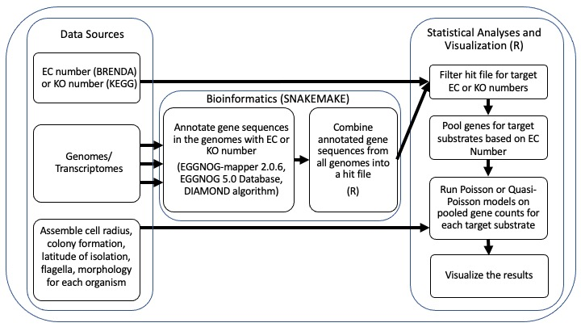

Figure 1: **Summary Flowchart of Methods.**

## Overview of Data Analysis

`CombinedHits.csv` was imported into a data frame (coded as ‘CombinedHits’) for analysis using R [104] running under RStudio [105], using the ‘tidyverse’ [106], ‘broom’ [107], ‘magrittr’ [108], ‘dplyr’ [109], ‘chngpt’ [110], ‘rcompanion’ [111], ‘gmodels’ [112], ‘stats’ [104] and ‘smatr’ [113] packages. Graphics and tables were generated using the ‘ggplot2’ [114], ‘cowplot’ [115], ‘glue’ [116], ‘kableExtra’ [117], ‘corrplot’ [118], ‘ggfortify’ [119,120], ‘AER’ [121] and ‘ggforce’ [122] packages (Figure 1). Citations were managed using the Zotero (www.zotero.org) open access reference manager connected to RStudio using the ‘citr’ [123] package. The Zotero library of citations is available at (https://www.zotero.org/groups/2333131/ros_phytoplankton). Formatted outputs were generated from RMarkdown files using the ‘knitr’ [124–126] and ‘bookdown’ [127] packages.

In parallel we assembled metadata from the literature and culture collection databases for each genome or transcriptome source organism, including the cell radii in µm from 100% of organisms; colony formation for 84% of organisms; cell shape from diatoms from 100% of diatoms; presence or absence of flagella as an index of potential motility coded as ‘Flagella’ from 100% of organisms, the genome size from all genomes and the total number of predicted gene models from 80% of organisms (Table 4); all stored in `CellGenomeMetrics.csv` (Figure 1). For organisms for which only transcriptomes were available, we only included datasets for which the total number of detected different transcripts was available, as a proxy for the total number of predicted genes. Strains of brackish origin were included but we did not include true freshwater strains in our analyses.

We compared the Enzyme Commission Number (EC number) to the BRENDA enzyme database [128] to identify enzymes metabolizing H<sub>2</sub>O<sub>2</sub>, O<sub>2</sub><sup>•−</sup> or <sup>•</sup>NO *in vivo* (annotated by BRENDA as ‘natural product’ or ‘natural substrate’) (Table 3; Figure 1). We then used the EC Number to filter ‘CombinedHits’ to generate a subset containing only those orthologs encoding enzymes mediating metabolism of H<sub>2</sub>O<sub>2</sub> (Production or Scavenging), O<sub>2</sub><sup>•−</sup> (Production or Scavenging) and <sup>•</sup>NO (Production or Scavenging). Genes that code for the production of non-enzymatic ROS scavengers such as carotenoids and tocopherols were not included in subsequent analyses.

From the subset of ‘CombinedHits’ containing information on ROS metabolizing enzymes, we grouped orthologs together by EC number and their Kegg Orthology number (KO number) and determined the number of occurrences of individual orthologs encoding each EC number (or KO number when EC number was not available) in a given organism. We merged this data subset with `CellGenomeMetrics.csv` to generate a dataset of the total number of genes encoding a ROS; EC numbers; KO Numbers; and Gene Ontology annotations; that code for the production of a ROS metabolizing enzyme, as defined by the EC or KO number, along with characters of the source organism (combined into ‘MergedData’).

H<sub>2</sub>O<sub>2</sub>, O<sub>2</sub><sup>•−</sup> and <sup>•</sup>NO are vastly different in reactivity, stability, diffusion distance, effects on biomolecules and roles in cell signaling (Table 1), so it would not be a valid to pool counts of orthologs encoding production or scavenging of all these diverse ROS. We therefore generated the total gene counts coding for the production or scavenging of a given ROS in a given organism, which were used to generate Poisson or Quasi-Poisson regressions (Figure 1).

## Data Validation & Justification of Statistical Analyses

Figure 12 shows a significant correlation (Correlation of 0.87, p = 1.6×10<sup>-49</sup>) between manually generated ‘ROSGene_count’ and the automated ‘ROSGene_count’ from the snakemake pipeline.

From the ‘CombinedHits’ data frame, we filtered out some enzymes whose BRENDA annotation of ‘natural product’ and ‘natural substrate’ was questionable, in particular:

- Superoxide oxidase (EC:1.10.3.17) carries a BRENDA annotation of ‘natural product’ for superoxide, despite the BRENDA citation stating that superoxide production from superoxide oxidase was only documented *in vitro* with an excess of ubiquinone [131].
- D-amino-acid oxidase was removed from the H<sub>2</sub>O<sub>2</sub> production calculations as the enzyme does not produce H<sub>2</sub>O<sub>2</sub> *in vivo* [132].

Some enzymes were listed for a given substrate under both *natural product* and *natural substrate*, as for example when a reaction is reversible. Bacterial non heme ferritin is listed under H<sub>2</sub>O<sub>2</sub> production and scavenging as it produces H<sub>2</sub>O<sub>2</sub> in the first of a two-step reaction and scavenges H<sub>2</sub>O<sub>2</sub> in the second step [133].

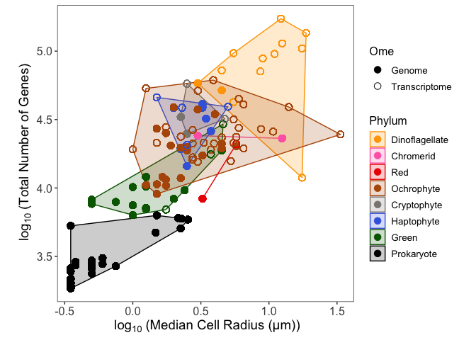

Figure 2: **Comparison of log<sub>10</sub> of the total number of genes in an organism (‘log_GeneModels_count’) to log<sub>10</sub> of the median cell radius in µm (‘log_Radius_um’).** Colour corresponds to the taxonomic lineage (‘Phylum’), whereas symbol shape corresponds to the source of the data, whether Genome or Transcriptome (‘Ome’). Citations for data sources are in Supplementary Table S3.

Figure 13 shows that the total number of genes encoding the metabolism of O<sub>2</sub><sup>•−</sup>, H<sub>2</sub>O<sub>2</sub> or <sup>•</sup>NO are not normally distributed (Shapiro-Wilk Test [134] with a p value of 6.4×10<sup>-30</sup> for O<sub>2</sub><sup>•−</sup> scavenging, 9.4×10<sup>-24</sup> for H<sub>2</sub>O<sub>2</sub> production, 5×10<sup>-25</sup> for H<sub>2</sub>O<sub>2</sub> scavenging, 1.2×10<sup>-18</sup> for <sup>•</sup>NO production and 1.5×10<sup>-30</sup> for <sup>•</sup>NO scavenging), and follows a Poisson distribution. Therefore, for subsequent analyses we used Poisson or Quasi-Poisson regressions to compare the total number of genes that encode the production or scavenging of O<sub>2</sub><sup>•−</sup>, H<sub>2</sub>O<sub>2</sub> or <sup>•</sup>NO, with an offset of the total number of genes in the organism, to log<sub>10</sub> of the median cell radius in µm. Quasi-Poisson regressions were used when the Poisson regression was over-dispersed (dispersion > 1, p < 0.05) as determined by the ‘AER’ package [121]. Because our data followed a Poisson distribution (Figure 13), a Poisson regression followed by a chi-squared test or a Quasi-Poisson regression followed by an F test, is statistically when obtaining the p-value [135]. An alpha value of ≤0.05 was used as the threshold for statistical significance of regressions.

The total number of genes in each organism, increased with the median cell radius, and also varied among the taxonomic lineages (coded as Phylum) (Figure 2). Taxonomic lineage, in turn, interacts strongly with the median cell radius. For our analyses, we sought to detect effects of cell radius upon the fraction of total genes encoding ROS metabolism. We therefore normalized the total number of genes encoding the production or scavenging of H<sub>2</sub>O<sub>2</sub>, O<sub>2</sub><sup>•−</sup> or <sup>•</sup>NO to ‘GeneModel_count’ to account for the general increase in ‘GeneModel_count’ with increasing the median cell radius. Because of the strong interaction between the median cell radius and taxonomic lineage (Figure 10), we did not include Phylum as a co-variate in our subsequent regressions of normalized gene counts vs. median cell radius. Thus, we did not analyze specific influences of Phylum.

To investigate the influence of colony formation, the presence of flagella or diatom cell shape (pennate or centric), upon the total number of genes that encode the metabolism of H<sub>2</sub>O<sub>2</sub>, O<sub>2</sub><sup>•−</sup> or <sup>•</sup>NO, with an offset of the total number of genes, we used a Wilcoxon test from the ‘ggpubr’ to compare organisms from which we had data.

# Results and Discussion

## Superoxide

### Influence of Cell Size on Gene Counts for Enzymes Metabolizing O<sub>2</sub><sup>•−</sup>

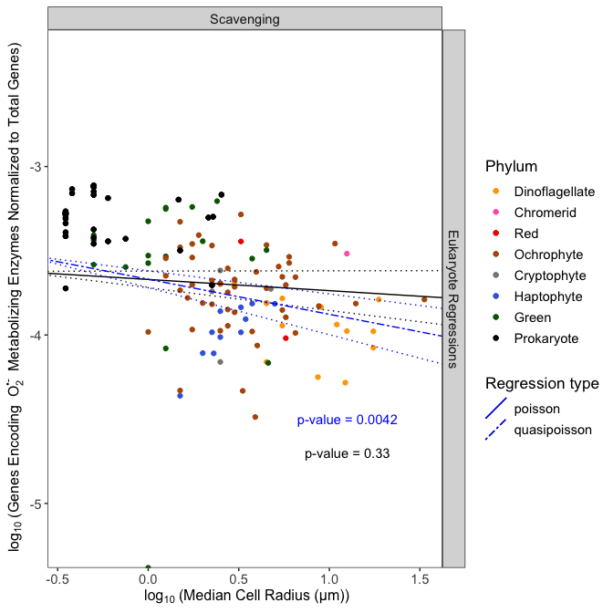

Figure 3: **Comparison of log<sub>10</sub> (Total number of genes encoding O<sub>2</sub><sup>•−</sup> metabolizing enzymes (‘SupOx_count’) normalized to the total number of genes present in each organism (‘GeneModels_count’)) vs. the log<sub>10</sub> (median cell radius in µm (‘log_Radius_um’)).** Poisson (solid line) or Quasi-Poisson (dashed line) regressions fitted to data ± Standard Error (dotted line). Regressions were run with (black line) or without (blue line) ‘Colony’ and ‘Flagella’ as co-variates. Selected prokaryote genomes are presented for comparison, but excluded from the presented regressions. Symbol color corresponds to taxon lineage (‘Phylum’).

With increasing cell radius, eukaryotic phytoplankton have a smaller fraction of their total genes that scavenge O<sub>2</sub><sup>•−</sup>, as shown by the negative slope of the quasipoisson regression (Figure 3, Blue line, Slope = -2.1×10<sup>-1</sup> ± 7.1×10<sup>-2</sup>, p = 4.2×10<sup>-3</sup>). The negative slope does not support our Hypothesis 1 that phytoplankton do not differentially allocate a changing fraction of their total gene content to O<sub>2</sub><sup>•−</sup> production nor scavenging. Including ‘Flagella’ and ‘Colony’ as co-variates in the regression results, however, in a slope that is not statistically different from zero (Figure 3, Black line, Slope = -6.7×10<sup>-2</sup> ± 6.8×10<sup>-2</sup>, p = 3.3×10<sup>-1</sup>), driven by the influence of ‘Flagella’ (p-value = 3.7×10<sup>-2</sup>) but not ‘Colony’ (p-value = 8.6×10<sup>-1</sup>). Including data from selected prokaryotic phytoplankton did not qualitatively alter these results. O<sub>2</sub><sup>•−</sup> metabolism in phytoplankton appears to be mediated by a nearly fixed set of core genes that do not change with increasing gene count, thus the fractional gene allocation to O<sub>2</sub><sup>•−</sup> decreases as cell radius (and the co-varying total gene count) increases.

### Influences of Flagella, Colony Formation and Cell Shape on Gene Counts for Enzymes Metabolizing O<sub>2</sub><sup>•−</sup>

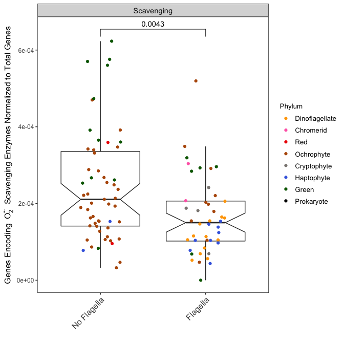

Figure 4: **Comparison of total number of genes encoding O<sub>2</sub><sup>•−</sup> scavenging enzymes (‘SupOx_count’) normalized to the total number of genes present in each organism (‘GeneModels_count’)) vs. the presence or absence of flagella in the organism.** Symbol color corresponds to taxon lineage (‘Phylum’). Notch spans ± standard error of the median. Box spans median ± 1 quartile of the data. Whiskers span the range excluding outliers in the data. Citations for data sources can be found in Supplementary Table S3.

Consistent with the significant influence of flagella on the regressions vs median cell radius (Figure 3), flagellated phytoplankton have a smaller proportion of their total gene content encoding O<sub>2</sub><sup>•−</sup> scavenging (Figure 4, p = 4.3×10<sup>-3</sup>), than do non-flagellated phytoplankton. This suggests that cellular motility contributes to phytoplankton homeostasis of O<sub>2</sub><sup>•−</sup>.

Setting aside any influence of cell size, colony and non-colony forming phytoplankton do not significantly differ in the fraction of their total gene content encoding O<sub>2</sub><sup>•−</sup> scavenging (p = 8.1×10<sup>-1</sup>) (Data not presented).

Pennate and centric diatoms O<sub>2</sub><sup>•−</sup> have similar fractions of their genomes encoding O<sub>2</sub><sup>•−</sup> scavenging (p = 9.7×10<sup>-1</sup>) (Data not presented). Our results support our hypothesis that differential diffusional exchange across diatoms of different shape does not influence the fraction of total gene content that encodes O<sub>2</sub><sup>•−</sup> scavenging enzymes, because O<sub>2</sub><sup>•−</sup> diffusion is blocked by the cell membrane irrespective of cell shape. Given that the O<sub>2</sub><sup>•−</sup> is poorly diffusible across membranes, intracellularly produced O<sub>2</sub><sup>•−</sup> has to be scavenged to limit detrimental reactions of O<sub>2</sub><sup>•−</sup> [89]. As a result, cells universally maintain the genomic capacity to scavenge O<sub>2</sub><sup>•−</sup>. Differences between genomic patterns of pennate and centric diatoms may arise when comparing metallo-forms of SOD, noting that [136] found that pennate diatoms transcribe Cu/Zn-SOD but not Fe-SOD, whereas centric diatoms transcribe Fe-SOD more frequently than they transcribe Cu/Zn-SOD.

## Hydrogen Peroxide

### Influence of Cell Size on Gene Counts for Enzymes Metabolizing H<sub>2</sub>O<sub>2</sub>

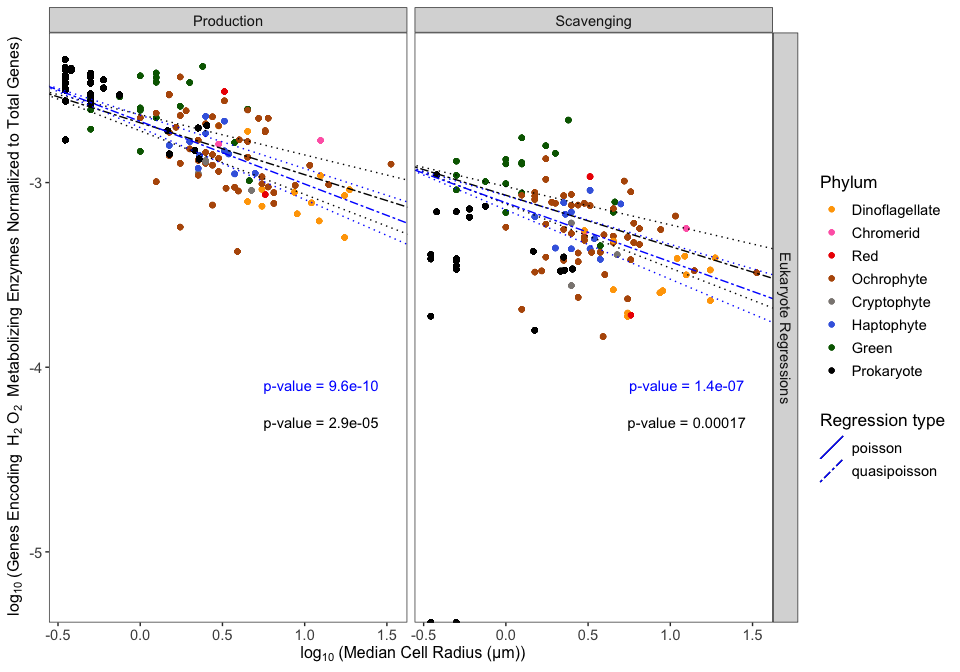

Figure 5: **Comparison of log<sub>10</sub> (Total number of genes encoding H<sub>2</sub>O<sub>2</sub> metabolizing enzymes (‘HyPe_count’) normalized to the total number of genes present in each organism (‘GeneModels_count’)) vs. the log<sub>10</sub>( median cell radius in µm (‘log_Radius_um’)).** Poisson (solid line) or Quasi-Poisson (dashed line) regressions fitted to data ± Standard Error (dotted line). Regressions were run with (black line) or without (blue line) ‘Colony’ and ‘Flagella’ as co-variates. Selected prokaryote genomes are presented for comparison, but excluded from the presented regressions. Symbol color corresponds to taxon lineage (‘Phylum’). Citations for data sources are in Supplementary Table S3.

With increasing cell radius, eukaryotic phytoplankton have a smaller fraction of their total genes that encode the production of H<sub>2</sub>O<sub>2</sub>, as shown by the negative slope of the quasipoisson regression (Figure 5, Blue line, Slope = -3.4×10<sup>-1</sup> ± 5×10<sup>-2</sup>, p = 9.6×10<sup>-10</sup>). Including ‘Flagella’ and ‘Colony’ as co-variates did not influence the slope of the fraction of total genes encoding H<sub>2</sub>O<sub>2</sub> production with increasing median cell radius (Black line, ‘Flagella’ p-value = 8.4×10<sup>-1</sup>, ‘Colony’ p-value = 4.7×10<sup>-1</sup>). Including data from selected prokaryotic phytoplankton did not qualitatively alter these results. The pattern of a smaller fraction of total genes for H<sub>2</sub>O<sub>2</sub> production with increasing cell radius supports our Hypothesis 2 that large phytoplankton counter decreasing diffusional loss of H<sub>2</sub>O<sub>2</sub> out of cells by having lower genomic capacity for H<sub>2</sub>O<sub>2</sub> production, while losses of genes encoding H<sub>2</sub>O<sub>2</sub> producing enzymes is more costly to small phytoplankton (Figure 5). [7] found that a major factor that influences the capacity for production of H<sub>2</sub>O<sub>2</sub> is whether or not the organism can form blooms, in that bloom forming species produce more H<sub>2</sub>O<sub>2</sub>. The ability to form blooms was not analyzed in our data.

With increasing cell radius, eukaryotic phytoplankton have a smaller fraction of their total genes that encode the capacity to scavenge H<sub>2</sub>O<sub>2</sub>, as shown by the negative slope of the quasipoisson regression (Figure 5, Blue line, Slope = -3.2×10<sup>-1</sup> ± 5.6×10<sup>-2</sup>, p = 1.4×10<sup>-7</sup>). Including ‘Flagella’ and ‘Colony’ as co-variates did not influence the slope of the fraction of total genes encoding H<sub>2</sub>O<sub>2</sub> scavenging with increasing median cell radius (Figure 5, Black line, ‘Flagella’ p-value = 4.1×10<sup>-1</sup>, ‘Colony’ p-value = 1.6×10<sup>-1</sup>). Including data from selected prokaryotic phytoplankton did not qualitatively alter these results. A similar study solely focusing on small phytoplankton such as pico-cyanobacteria and pico-prasinophytes might yield different results as more genomes are sequenced, especially considering that [137] found that H2O2 added to seawater at a concentration of 1.6 mg L<sup>−1</sup> did not affect cells with a radius larger than 1 to 1.5 μm, and mainly harmed the prasinophyte *Micromonas pusilla*.

Noting that the fraction of total genes allocated to both H<sub>2</sub>O<sub>2</sub> production and scavenging decrease with increasing median cell radius, we found that the fraction of total genes that encode production of H<sub>2</sub>O<sub>2</sub> decreases proportionally more with increasing cell radius than does the fraction of total genes that encode scavenging of H<sub>2</sub>O<sub>2</sub> (4.6×10<sup>-50</sup>). The difference in slopes again supports our Hypothesis 2 that large phytoplankton counter decreasing diffusional loss of H<sub>2</sub>O<sub>2</sub> out of cells by having lower genomic capacity for H<sub>2</sub>O<sub>2</sub> production relative to H<sub>2</sub>O<sub>2</sub> scavenging. Because median cell radius co-varied with Phylum, we generally excluded co-variate from our regressions, in order to focus on any cross-taxon patterns with changing median cell radius. Nevertheless, representatives of the Ochrophyte Phylum alone spanned more than an order of magnitude in median cell radius. We therefore tested whether the log<sub>10</sub>(total number of genes encoding the metabolism of O<sub>2</sub><sup>•−</sup>, H<sub>2</sub>O<sub>2</sub> or <sup>•</sup>NO) varied with the log<sub>10</sub> (median cell radius) across the Ochrophytes alone (Figure 15). We found that across Ochrophytes, the fraction of total genes encoding the production of H<sub>2</sub>O<sub>2</sub> decreased with increasing cell radius (Slope = -1.6×10<sup>-1</sup> ± 9.4×10<sup>-2</sup>), although the p value for the regression was 1×10<sup>-1</sup>. This marginal decrease in the total number of genes encoding H<sub>2</sub>O<sub>2</sub> production with increasing median cell radius in Ochrophytes again tends to support our Hypothesis 2, with data from within a single phylum.

### Influences of Flagella, Colony Formation and Cell Shape on Gene Counts for Enzymes Metabolizing H<sub>2</sub>O<sub>2</sub>

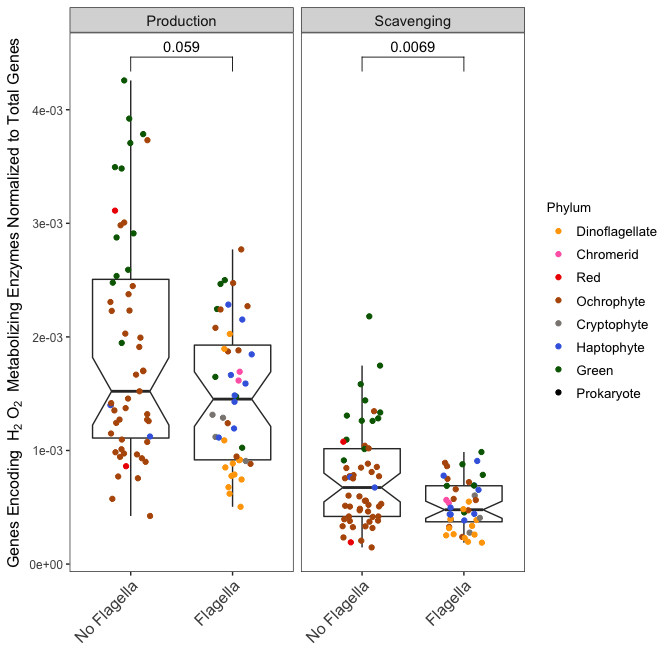

Figure 6: **Comparison of total number of genes encoding H<sub>2</sub>O<sub>2</sub> metabolizing enzymes (‘HyPe_count’) normalized to the total number of genes present in each organism (‘GeneModels_count’) vs. the presence or absence of flagella in the organism.** Symbol color corresponds to taxon lineage (‘Phylum’). Notch spans ± standard error of the median. Box spans median ± 1 quartile of the data. Whiskers span the range excluding outliers in the data. Citations for data sources can be found in Supplementary Table S3.

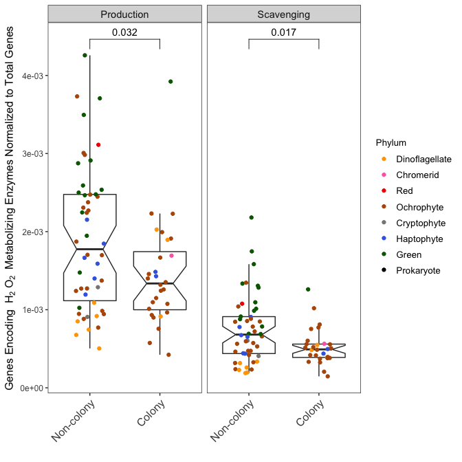

Figure 7: **Comparison of total number of genes encoding H<sub>2</sub>O<sub>2</sub> metabolizing enzymes (‘HyPe_count’) normalized to the total number of genes present in each organism (‘GeneModels_count’) vs. the ability of the organism to form colonies.** Symbol color corresponds to taxon lineage (‘Phylum’). Notch spans ± standard error of the median. Box spans median ± 1 quartile of the data. Whiskers span the range excluding outliers in the data. Citations for data sources can be found in Supplementary Table S3.

Pennate and centric diatoms do not show statistically significant differences in the fraction of their total gene content encoding the production (p = 1.9×10<sup>-1</sup>) nor the scavenging of H<sub>2</sub>O<sub>2</sub> (p = 9.6×10<sup>-2</sup>). This result does not support our Hypothesis 4 that pennates have more genes encoding H<sub>2</sub>O<sub>2</sub> producing enzymes due to their higher surface area to volume ratio (Data not presented).

## Nitric Oxide

### Influence of Cell Size on Gene Counts for Enzymes Metabolizing <sup>•</sup>NO

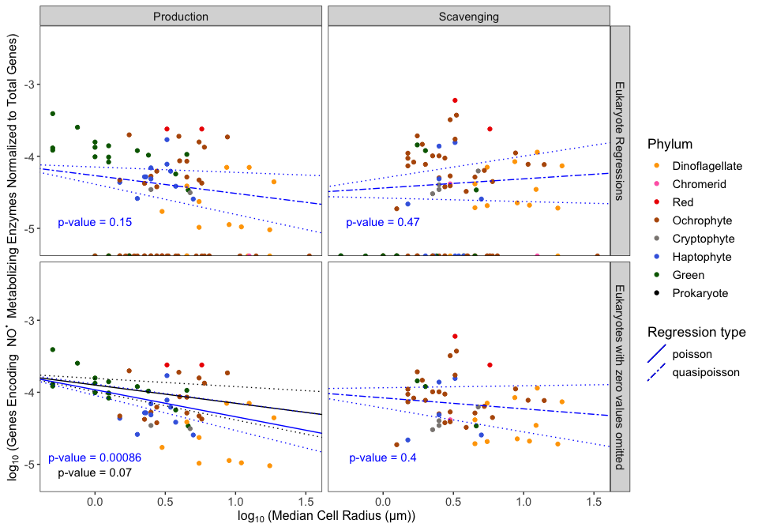

Figure 8: **Comparison of log<sub>10</sub> (Total number of genes encoding <sup>•</sup>NO metabolizing enzymes (‘NitOx_count’) normalized to the total number of genes present in each organism (‘GeneModels_count’)) vs. the log<sub>10</sub> (median cell radius in µm (‘log_Radius_um’)).** Poisson (solid line) or Quasi-Poisson (dashed line) regressions fitted to data ± Standard Error (dotted line). Regressions were run with (black line) or without (blue line) ‘Colony’ and ‘Flagella’ as co-variates. Selected prokaryote genomes are presented for comparison, but excluded from the presented regressions. Symbol color corresponds to taxon lineage (‘Phylum’).

With increasing cell radius, eukaryotic phytoplankton do not have a varying fraction of their total genes to the capacity to produce <sup>•</sup>NO, as seen in the quasipoisson regression in Figure 8 (Blue line, Slope = -2.5×10<sup>-1</sup> ± 1.7×10<sup>-1</sup>, p = 1.5×10<sup>-1</sup>). Including prokaryotes in the regression in Figure 8 does not substantially alter the interpretation. We re-ran the quasipoisson, excluding those organisms that completely lack genes encoding enzymes for <sup>•</sup>NO production (NitOx_count = 0, points along the x-axis), which resulted in a decreasing slope with increasing cell radius. Thus those phytoplankton with any detected capacity to produce <sup>•</sup>NO indeed have a smaller fraction of their total genes encoding <sup>•</sup>NO production with increasing radius (Figure 8, Blue line, Slope = -3.7×10<sup>-1</sup> ± 1.1×10<sup>-1</sup>, p value = 8.6×10<sup>-4</sup>). Including ‘Flagella’ and ‘Colony’ as co-factors to the regression that solely looks at organisms with the genomic capacity to produce <sup>•</sup>NO resulted in a slope that is no longer significantly different from zero (Figure 8, Black line, Slope = -2.5×10<sup>-1</sup> ± 1.4×10<sup>-1</sup>, p = 7×10<sup>-2</sup>), driven by the influence of ‘Flagella’ (p-value = 1.4×10<sup>-4</sup>), but not ‘Colony’ (p-value = 1.8×10<sup>-1</sup>).

With increasing cell radius, eukaryotic phytoplankton do not alter the fraction of their total genes to the capacity to scavenge <sup>•</sup>NO, as seen in the quasipoisson regression slope not significantly different from zero (Figure 8, Blue line, Slope = 1.3×10<sup>-1</sup> ± 1.8×10<sup>-1</sup>, p = 4.7×10<sup>-1</sup>). Including prokaryotes in the quasipoisson regression from Figure 8 does not alter the interpretation, as the slope of the quasipoisson regression is still not significantly different from zero. We re-ran the quasipoisson, excluding those organisms that completely lack genes encoding enzymes for <sup>•</sup>NO scavenging (NitOx_count = 0, points along the x-axis), did not contribute to explaining the fraction of total genes encoding <sup>•</sup>NO scavenging with increasing radius. Non-enzymatic paths contribute to intracellular and extracellular <sup>•</sup>NO production [138], and may explain the absences of genes encoding <sup>•</sup>NO production across some genomes across all taxonomic lineages. Alternately, <sup>•</sup>NO homeostastis may be achieved in some lineages by regulating the active cellular uptake and release of intracellular <sup>•</sup>NO, as has been recently demonstrated in humans [139]. Although nitric oxide dioxygenase sequences have only been identified once before from phytoplankton through metatranscriptomic analyses (in diatoms and dinoflagellates) [140], there is limited understanding as to what may contribute to the active removal of <sup>•</sup>NO, and the lack of <sup>•</sup>NO scavenging genes across multiple organisms. More research is needed on NOD in the active removal of <sup>•</sup>NO, as well as the NOS sequences detected in Synechococcus that also display nitric oxide dioxygenase-like activity [141]. Perhaps the low reactivity of <sup>•</sup>NO does not warrant the active removal of <sup>•</sup>NO as long as the concentration does not exceed the toxic threshold. This explanation is plausible given that *Platymonas helgolandica*, *Platymonas subcordiformis*, *Skeletonema costatum*, *Gymnodinium sp.*, and *Prorocentrum donghaiense* showed optimum growth in the presence of <sup>•</sup>NO concentrations between 10<sup>-9</sup> and 10<sup>-6</sup> mol L<sup>−1</sup> [142], which are higher than the concentrations found in the ocean (Table 1).

### Influences of Flagella, Colony Formation and Cell Shape on Gene Counts for Enzymes Metabolizing <sup>•</sup>NO

Setting aside the influence of cell size, non-flagellated and flagellated phytoplankton do not show statistically significant differences in the fractions of total gene content encoding <sup>•</sup>NO production (p = 6.3×10<sup>-1</sup>) nor <sup>•</sup>NO scavenging (p = 8.9×10<sup>-1</sup>) (Data not presented), suggesting <sup>•</sup>NO does not have a generalized interaction with flagella across eukaryotic phytoplankton groups.

Comparing non-colony to colony forming phytoplankton does not show a statistically significant difference in the fraction of total gene content encoding <sup>•</sup>NO production (p = 7.7×10<sup>-1</sup>) nor <sup>•</sup>NO scavenging (p = 2.7×10<sup>-1</sup>) (Data not presented), suggesting <sup>•</sup>NO metabolism does not have a generalized role in colony formation across eukaryotic phytoplankton groups.

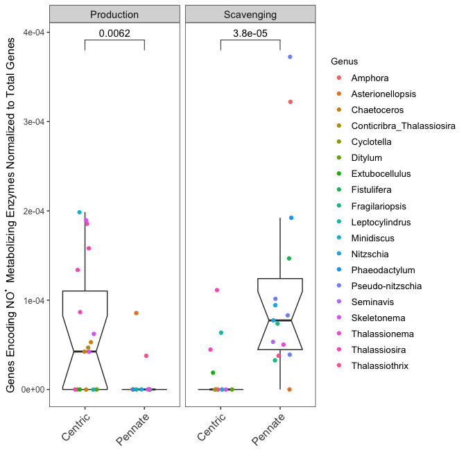

The larger fractional gene allocation to <sup>•</sup>NO production, and smaller fraction of genes that encode <sup>•</sup>NO scavenging enzymes, in centric diatoms (Figure 9) counters our hypothesis that diffusion from pennate diatoms would drive gene allocations in favor of <sup>•</sup>NO production (Hypothesis 4). Given the strong contrast in annotated <sup>•</sup>NO metabolism genes, it is likely that <sup>•</sup>NO has regulatory or signaling roles that vary systematically between pennate and centric diatoms, outside any diffusional influences. For example, <sup>•</sup>NO inhibits diatom adhesion to substrate [75,143]. Pennates are more likely to grow adhered in biofilms [144], which may explain the striking differences in total gene allocation to <sup>•</sup>NO production and scavenging. Alternately, [145] identified nitric oxide synthase sequences in the transcriptomes of three Pennate Diatom species (*Pseudo-nitzschia arenysensis*, *Pseudo-nitzschia delicatissima* and *Pseudo-nitzschia multistriata*), so it is possible the apparent lack of <sup>•</sup>NO producing sequences in pennates is due to errors in the unsupervised annotations from eggNOG.

## Summary

H<sub>2</sub>O<sub>2</sub>, O<sub>2</sub><sup>•−</sup> and <sup>•</sup>NO have multiple intracellular and extracellular roles across phytoplankton taxa [21,21,30,47,146]. The differential reactivities, diffusion distances, diffusibilities across cell membranes, and roles in cell signaling of H<sub>2</sub>O<sub>2</sub>, O<sub>2</sub><sup>•−</sup> and <sup>•</sup>NO (Table 1) influence genomic allocation patterns for the production and scavenging of these three ROS.

Our work analyzed the fraction of the total genes in a genome associated with the metabolism of a particular ROS. The presence or absence of genes encoding specific ROS metabolizing enzymes may be caused by genetic drift, or may relate to a selective advantage linked to other metabolites of the same enzyme, rather than an enzymatic role in ROS metabolism, *per se*. Furthermore, the presence of a gene in a genome does not necessarily mean the encoded enzyme will be active, and closely related enzymes may mediate different activities in different organisms.

Patterns of genomic allocations to production and scavenging of different ROS vary significantly by substrate.

O<sub>2</sub><sup>•−</sup> has relatively high reactivity, short intracellular and extracellular lifetimes and limited cell membrane crossing. We did not find genes specifically encoding O<sub>2</sub><sup>•−</sup> production in eukaryotic phytoplankton genomes. As expected, genes encoding O<sub>2</sub><sup>•−</sup> scavenging were ubiquitous, but the fractional gene allocation to O<sub>2</sub><sup>•−</sup> scavenging decreases as cell radius (and the co-varying total gene count) increases, consistent with a nearly fixed set of core genes that do not change with increasing gene count.

H<sub>2</sub>O<sub>2</sub> has low reactivity, long intracellular and extracellular lifetimes and readily crosses cell membranes. Across eukaryotic phytoplankton, fraction of the total genes encoding H<sub>2</sub>O<sub>2</sub> producing enzymes decreases with increasing cell radius, consistent with maintenance of ROS homeostasis in the face of slower diffusional losses from larger cells. The fraction of the total genes encoding H<sub>2</sub>O<sub>2</sub> scavenging enzymes also decreases with increasing cell radius, but with a slope smaller than that for H<sub>2</sub>O<sub>2</sub> producing enzymes. Presence of flagella and colony formation appear to influence H<sub>2</sub>O<sub>2</sub> metabolism.

<sup>•</sup>NO has low reactivity, long intracellular and extracellular lifetimes and readily crosses cell membranes. Neither the fraction of the total genes for <sup>•</sup>NO production nor for scavenging changed significantly with increasing cell radius, consistent with relatively low cytotoxicity and roles of <sup>•</sup>NO in taxonomically diverse regulatory systems. Pennate diatoms frequently lack genes annotated as encoding <sup>•</sup>NO producing enzymes, whereas centric diatoms frequently lack genes annotated as encoding <sup>•</sup>NO scavenging enzymes. This finding is not explicable by differential diffusional losses of <sup>•</sup>NO, but may reflect distinct roles of <sup>•</sup>NO in the regulatory systems of diatom lineages.

# Open Data Statement

Code, genes annotated for ROS metabolism (MergedData.csv), MetaData.csv and DataDictionary.csv are stored on https://github.com/NaamanOmar/ROS_bioinfo/ROSGenomicPatternsAcrossMarinePhytoplankton.

Annotations of all genes from genomes or transcriptomes of organisms used in this study, MetaData.csv and DataDictionary.csv are stored on DRYAD (DOI pending) to facilitate reuse for other purposes.

# Supplementary Materials

## Supplementary Figures

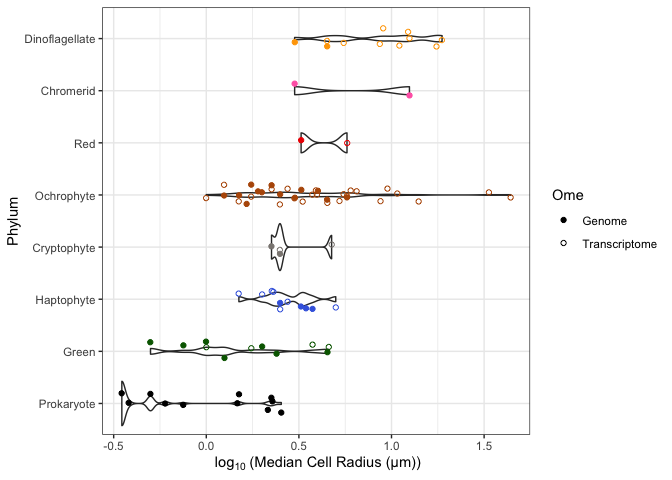

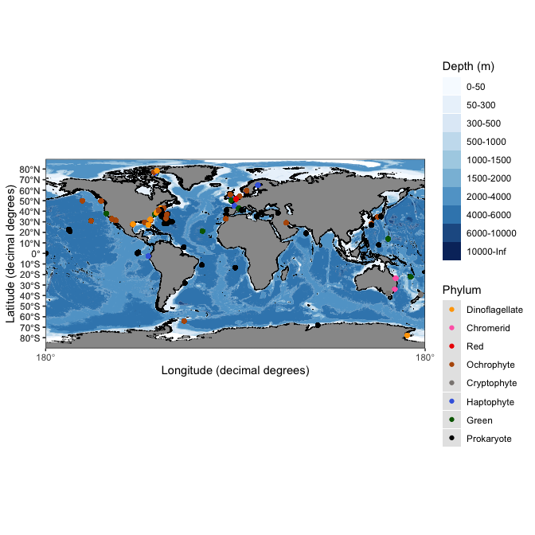

Figure 11: Longitude and Latitude of isolation of analyzed organisms, overlaid on a world map Point colour corresponds to the taxonomic lineage (‘Phylum’). Ocean colour corresponds to depth Citations for data sources are in Supplementary Table S3. Data used to generate world map produced from the ‘ggOceanMaps’ R package [147]

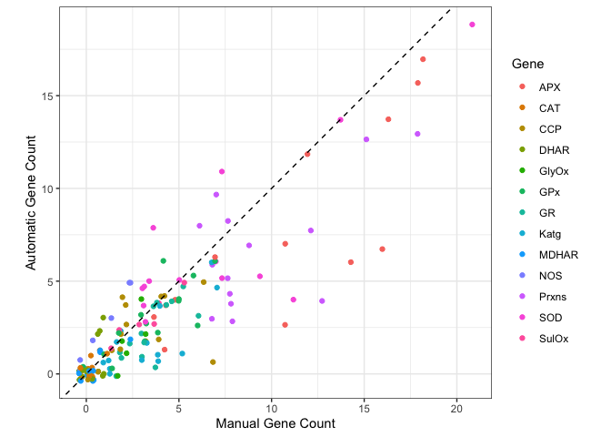

Figure 12: **Comparison of paired counts of particular genes encoding ROS Production or Scavenging from manual and automatic annotations taken from the same organism.** Data was drawn from a subset of genomes and transcriptomes which were both manually and automatically annotated. Colour corresponds to the ‘Gene’ Points are jittered to avoid overlapping, resulting in blocks around frequently occuring counts. Dashed line is placed at 1:1 where Manual and Automated counts would be equal. Citations for data sources in Supplemental Data Table S4.

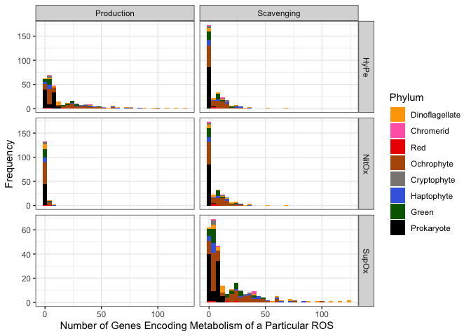

Figure 13: **Histogram of occurrences of number of total genes, in a genome or transcriptome, (y axis) that code for the production of enzymes that produce or scavenge H<sub>2</sub>O<sub>2</sub>, O<sub>2</sub><sup>•−</sup> or <sup>•</sup>NO *in vivo*.** Symbol color corresponds to taxon lineage (‘Taxa’)

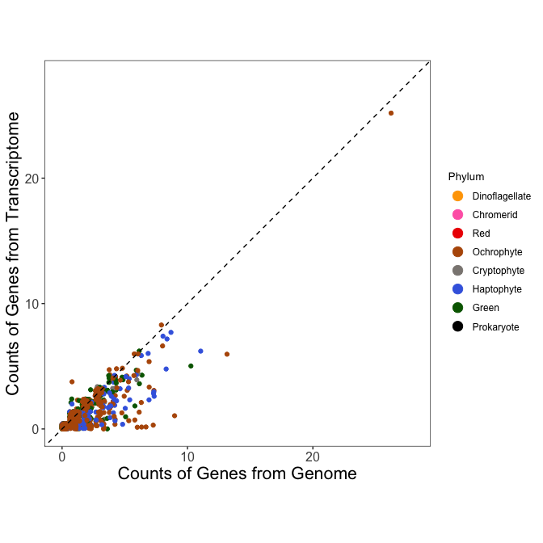

Figure 14: **Comparison of paired counts of particular genes encoding ROS Production or Scavenging from the genome (‘ROSGene_count.g’) or transcriptome (‘ROSGene_count.t’) taken from the same organism.** Data was drawn from a subset of analyzed organisms for which both genome and transcriptome were available. Colour corresponds to the taxonomic lineage (‘Phylum’) Points are jittered to avoid overlapping, resulting in blocks around frequently occuring counts. Dashed line is at 1:1 where ‘ROSGene_count.g’ and ‘ROSGene_count.t’ would be equal. Citations for data sources are in Supplementary Table S3.

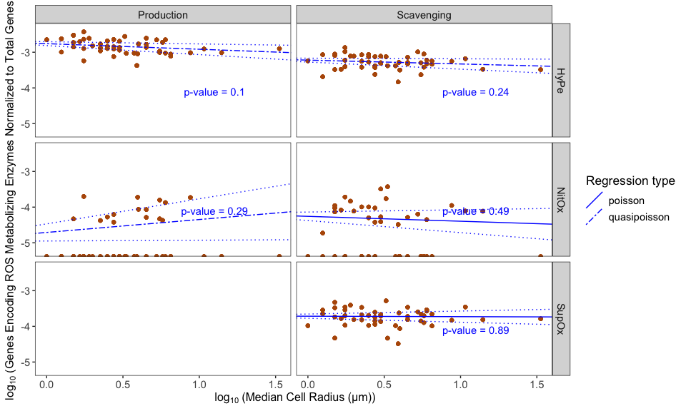

Figure 15: **Comparison of log<sub>10</sub> (Total number of genes encoding H<sub>2</sub>O<sub>2</sub>, O<sub>2</sub><sup>•−</sup> or <sup>•</sup>NO metabolizing enzymes normalized to the total number of genes present in each Ochrophyte) vs. the log<sub>10</sub>( median cell radius in µm).** Poisson (solid line) or Quasi-Poisson (dashed line) regressions fitted to data ± Standard Error (dotted line). Regressions were run without (blue line) ‘Colony’ and ‘Flagella’ as co-variates. Citations for data sources are in Supplementary Table S3.

## Supplementary Tables

Table 2: Variable names, definitions, units, and first location of occurence in code, used for our data.

| Variable | Units | Definition | CodeLocation |
| --- | --- | --- | --- |
| Genus |  | Genus of the organism | MergedData |
| species |  | Species of the organism | MergedData |
| Strain |  | Strain of the organism | MergedData |
| FileName |  | Name of source genome or transcriptome file composed of three components - Name, Nucleic acid and Genome or Transcriptome, separated by dashes | MergedData |
| Name |  | Combination of Genus, species, Strain | MergedData |
| Ome |  | Genome or Transcriptome | MergedData |
| Taxa |  | Taxonomic group that the organism falls in, typically phyla or superphyla | MergedData |
| Rad1_um | <b5>m | Smallest median radius (in <b5>m) along all three axes | MergedData |
| Rad2_um | <b5>m | Second largest median radius (in <b5>m) along all three axes | MergedData |
| Rad3_um | <b5>m | Largest median radius (in <b5>m) along all three axes | MergedData |
| Flagella |  | Refers to whether or not the organism has a flagella | MergedData |
| GenomeSize_mbp | mbp | Size of the genome in megabasepairs | MergedData |
| GeneModels_count | count | Total number of genes in genome | MergedData |
| Latitude | <a1> | Source latitude from which the organism was sampled in degrees | MergedData |
| Longitude | <a1> | Source longitude from which the organism was sampled in degrees | MergedData |
| Marine |  | States whether the organism is Marine or not | MergedData |
| Enzyme_abbrev |  |  | MergedData |
| ROSEnzymeName |  |  | MergedData |
| ProdOrScav |  |  | MergedData |
| ROSGene_count | count | Count of genes encoding an enzyme by EC number | MergedData |
| EnzymeParent |  |  | MergedData |
| PennateCentric |  | Solely for Diatoms, indicates whether the Diatom is a Pennate or a Centric Diatom | MergedData |
| SA_um2 | <b5>m<sup>2</sup> | Surface area in <b5>m<sup>2</sup> | MergedData |
| Volume_um3 | <b5>m<sup>3</sup> | Volume in <b5>m<sup>3</sup> | MergedData |
| SAVol_um | <b5>m<sup>-1</sup> | Surface area to Volume ratio in <b5>m<sup>-1</sup> | MergedData |
| Radius_um | <b5>m | Smallest median radius (in <b5>m) along all three axes | MergedData |
| log_Radius_um | <b5>m | log10 of Radius_<b5>m | MergedData |
| log_GenomeSize_mbp | mbp | log10 of GenomeSize_mbp | MergedData |
| log_GeneModels_count | count | log10 of GeneModel_count | MergedData |
| log_Gene_count | count | log10 of Gene_count | MergedData |

[output cut: 139 more lines]

Table 3: Enzyme Commission Number, Kegg Orthology Number, Enzyme Name and ROS Substrate Metabolised

| ECNumber | KO | EnzymeName | SupOx | HyPe | NitOx |
| --- | --- | --- | --- | --- | --- |
| 1.1.3.4 |  | Glucose oxidase |  | Production |  |
| 1.1.3.B4 |  | Glycerol oxidase |  | Production |  |
| 1.1.3.5 | K21840 | Hexose oxidase |  | Production |  |
| 1.1.3.6 | K03333 | Cholesterol oxidase |  | Production |  |
| 1.1.3.7 |  | Aryl-Alcohol oxidase |  | Production |  |
| 1.1.3.8 | K00103 | L-gulonolactone oxidase |  | Production |  |
| 1.1.3.9 | K04618 | Galactose oxidase |  | Production |  |
| 1.1.3.10 | K23272 | Pyranose oxidase |  | Production |  |
| 1.1.3.11 |  | L-sorbose oxidase |  | Production |  |
| 1.1.3.12 | K18607 | Pyridoxine 4-oxidase |  | Production |  |
| 1.1.3.13 | K17066 | Alcohol oxidase |  | Production |  |
| 1.1.3.15 | K00104;K11517 | (S)-2-hydroxy-acid oxidase |  | Production |  |
| 1.1.3.16 | K10724 | Ecdysone oxidase |  | Production |  |
| 1.1.3.17 | K17755 | choline oxidase |  | Production |  |
| 1.1.3.18 |  | secondary-alcohol oxidase |  | Production |  |
| 1.1.3.19 |  | 4-hydroxymandelate oxidase (decarboxylating) |  | Production |  |
| 1.1.3.20 | K17756 | long-chain-alcohol oxidase |  | Production |  |
| 1.1.3.21 | K00105 | glycerol-3-phosphate oxidase |  | Production |  |
| 1.1.3.27 |  | hydroxyphytanate oxidase |  | Production |  |
| 1.1.3.30 |  | polyvinyl-alcohol oxidase |  | Production |  |
| 1.1.3.37 | K00107 | D-arabinono-1,4-lactone oxidase |  | Production |  |
| 1.1.3.38 | K20153 | vanillyl-alcohol oxidase |  | Production |  |
| 1.1.3.39 |  | nucleoside oxidase (H2O2-forming) |  | Production |  |
| 1.1.3.40 |  | D-mannitol oxidase |  | Production |  |
| 1.1.3.41 | K00594 | alditol oxidase |  | Production |  |
| 1.1.3.42 | K20550 | prosolanapyrone-II oxidase |  | Production |  |
| 1.1.3.45 | K15949 | aclacinomycin-N oxidase |  | Production |  |
| 1.1.3.46 | K16422 | 4-hydroxymandelate oxidase |  | Production |  |
| 1.1.3.47 | K16873 | 5-(hydroxymethyl)furfural oxidase |  | Production |  |
| 1.1.3.48 | K19714 | 3-deoxy-alpha-D-manno-octulosonate 8-oxidase |  | Production |  |

[output cut: 127 more lines]

Table 4: Metadata for each organism

Genus

species

Strain

FileName

Marine

Ome

Taxa

PennateCentric

PennateCentric_citekey

Rad1_um

Rad2_um

Rad3_um

Rad_citekey

Flagella

Flagella_citekey

GenomeSize_mbp

GeneModels_count

Genome_ref

Genome_citekey

Database

AccessionInfo

LiveLink

Latitude

Longitude

LogLat_citekey

ColonySpecies

ColonyGenus

Colony_citekey

Notes

Guillardia

theta

CCMP2712

Guillardia_theta_CCMP2712-aa-gen

yes

Genome

Cryptophyte

2.500

2.500

4.750

[148]

yes

[149]

87.16000

24840

[150]

JGI

16067

https://mycocosm.jgi.doe.gov/Guith1/Guith1.home.html

41.22640

-73.063900

[148]

0

[148]

Guillardia

theta

CCMP2712

Guillardia_theta_CCMP2712-dna-trans

yes

Transcriptome

Cryptophyte

2.500

2.500

4.750

[148]

yes

[149]

1.00000

0

[150]

JGI

16067

https://mycocosm.jgi.doe.gov/Guith1/Guith1.home.html

41.22640

-73.063900

[148]

0

[148]

Phaeodactylum

tricornutum

CCAP1055/1

Phaeodactylum_tricornutum_CCAP10551-aa-gen

yes

Genome

Diatom

Pennate

[151]

1.750

1.750

21.000

[151]

no

[152]

27.45070

10402

[153]

NCBI

ASM15095v2

https://www.ncbi.nlm.nih.gov/assembly/GCF_000150955.2/

54.00000

4.000000

[148]

0

[154]

Phaeodactylum

tricornutum

CCAP1055/1

Phaeodactylum_tricornutum_CCAP10551-dna-trans

yes

Transcriptome

Diatom

Pennate

[151]

1.750

1.750

21.000

[151]

no

[152]

1.00000

0

[153]

NCBI

ASM15095v2

https://www.ncbi.nlm.nih.gov/assembly/GCF_000150955.2/

54.00000

4.000000

[148]

0

[154]

Fistulifera

solaris

JPCC_DA0580

Fistulifera_solaris_JPCCDA0580-aa-gen

yes

Genome

Diatom

Pennate

[155]

1.900

1.900

3.375

[155]

no

[156]

49.74000

20429

[157]

JGI

Fistulifera solaris JPCC DA0580: Fisso1_GeneCatalog_proteins_20200805.aa.fasta.gz

https://genome.jgi.doe.gov/portal/pages/dynamicOrganismDownload.jsf?organism=Fisso0

28.15000

129.240000

[155]

0

[155]

Fistulifera

solaris

JPCC_DA0580

Fistulifera_solaris_JPCCDA0580-dna-trans

yes

Transcriptome

Diatom

Pennate

[155]

1.900

1.900

3.375

[155]

no

[156]

1.00000

0

[157]

JGI

Fistulifera solaris JPCC DA0580: Fisso1_GeneCatalog_transcripts_20200805.nt.fasta.gz

https://genome.jgi.doe.gov/portal/pages/dynamicOrganismDownload.jsf?organism=Fisso1

28.15000

129.240000

[155]

0

[155]

Thalassiosira

pseudonana

CCMP1335

Thalassiosira_pseudonana_CCMP1335-aa-gen

yes

Genome

Diatom

Centric

[148]

2.250

2.250

2.500

[148]

no

[158]

32.10000

11776

[159]

PicoPlaza

proteome.tps.tfa.gz

https://bioinformatics.psb.ugent.be/plaza/versions/pico-plaza/download

40.75600

-72.820000

[148]

0

[160]

Thalassiosira

pseudonana

CCMP1335

Thalassiosira_pseudonana_CCMP1335-dna-trans

yes

Transcriptome

Diatom

Centric

[148]

2.250

2.250

2.500

[148]

no

[158]

1.00000

0

[159]

NCBI

ASM14940v2

[https://www.ncbi.nlm.nih.gov/genome/?term=txid35128[orgn]](https://www.ncbi.nlm.nih.gov/genome/?term=txid35128%5Borgn%5D)

40.75600

-72.820000

[148]

0

[160]

Thalassiosira

oceanica

CCMP1005

Thalassiosira_oceanica_CCMP1005-aa-gen

yes

Genome

Diatom

Centric

[148]

4.000

4.000

4.000

[148]

no

[156]

92.19000

34642

[161]

NCBI

PRJNA36595

https://www.ncbi.nlm.nih.gov/genome/3436

33.18330

-65.850000

[148]

0

[162]

Thalassiosira

oceanica

CCMP1005

Thalassiosira_oceanica_CCMP1005-dna-trans

yes

Transcriptome

Diatom

Centric

[148]

4.000

4.000

4.000

[148]

no

[156]

1.00000

0

[161]

NCBI

PRJNA36595

https://www.ncbi.nlm.nih.gov/genome/3437

33.18330

-65.850000

[148]

0

[162]

Coscinodiscus

wailesii

CCMP2513

Coscinodiscus_wailesii_CCMP2513-aa-trans

yes

Transcriptome

Diatom

Centric

[148]

44.000

44.000

44.000

[148]

no

[156]

1.00000

0

[163]

MMETSP

MMETSP1066

https://figshare.com/articles/dataset/Marine_Microbial_Eukaryotic_Transcriptome_Sequencing_Project_re-assemblies/3840153

31.43220

-80.358000

[148]

0

[164]

Chaetoceros

debilis

MM31A_1

Chaetoceros_debilis_MM31A_1-aa-trans

yes

Transcriptome

Diatom

Centric

[165]

6.500

7.500

12.000

[165]

no

[156]

1.00000

19453

[166]

iMicrobe

Chaetoceros-debilis-MM31A_1.pep.fa.gz

ftp://ftp.imicrobe.us/camera/combined_assemblies/

0

[167]

Conticribra_Thalassiosira

weissflogii

CCMP1010

Thalassiosira_weissflogii_CCMP1010-aa-trans

yes

Transcriptome

Diatom

Centric

[148]

5.500

5.500

7.750

[148]

no

[156]

1.00000

21329

[166]

iMicrobe

Thalassiosira-weissflogii-CCMP1010.pep.fa.gz

ftp://ftp.imicrobe.us/camera/combined_assemblies/

37.00000

-65.000000

[148]

0

[160]

Cyclotella

cryptica

CCMP332

Cyclotella_cryptica_CCMP332-aa-gen

yes

Genome

Diatom

Centric

[168]

4.500

4.500

7.000

[168]

no

[156]

161.70000

21121

[168]

UCLA

Nuclear genome

http://genomes.mcdb.ucla.edu/Cyclotella/download.html

41.35500

-70.655000

0

[160]

Nannochloropsis

oceanica

CCMP1779

Nannochloropsis_oceanica_CCMP1779-aa-gen

yes

Genome

Eustigmatophyte

1.500

1.500

1.500

[148]

no

[169]

28.74000

10641

[170]

JGI

1143084

https://mycocosm.jgi.doe.gov/Nanoce1779_2/Nanoce1779_2.home.html

29.00000

48.000000

[148]

0

[171]

Nannochloropsis

oceanica

CCMP1779

Nannochloropsis_oceanica_CCMP1779-dna-trans

yes

Transcriptome

Eustigmatophyte

1.500

1.500

1.500

[148]

no

[169]

1.00000

0

[170]

JGI

1143084

https://mycocosm.jgi.doe.gov/Nanoce1779_2/Nanoce1779_2.home.html

29.00000

48.000000

[148]

0

[171]

Nannochloropsis

gaditana

CCMP526

Nannochloropsis_gaditana_CCMP526-aa-gen

yes

Genome

Eustigmatophyte

1.500

1.500

2.500

[148]

no

[172]

30.30000

9052

[171]

NCBI

ASM24072v1

https://www.ncbi.nlm.nih.gov/assembly/GCF_000240725.1/

32.83330

-9.000000

[148]

0

[173]

Nannochloropsis

gaditana

CCMP526

Nannochloropsis_gaditana_CCMP526-dna-trans

yes

Transcriptome

Eustigmatophyte

1.500

1.500

2.500

[148]

no

[172]

1.00000

0

[171]

NCBI

ASM24072v1

https://www.ncbi.nlm.nih.gov/assembly/GCF_000240725.1/

32.83330

-9.000000

[148]

0

[173]

(Nannochloropsis) Microchloropsis

salina

CCMP1776

Nannochloropsis_salina_CCMP1776-aa-gen

yes

Genome

Eustigmatophyte

1.250

1.250

1.500

[148]

no

[174]

27.75730

10522

[175]

NCBI

ASM456527v1

https://www.ncbi.nlm.nih.gov/genome/75342?genome_assembly_id=739695

55.75000

-4.960000

[148]

0

[176]

Ostreococcus

tauri

RCC1115

Ostreococcus_tauri_RCC1115-aa-gen

yes

Genome

Green

0.500

0.500

0.500

[177]

no

[178]

14.76000

8218

[179]

NCBI

GCA_002158475.1

https://phycocosm.jgi.doe.gov/Ostta1115_2/Ostta1115_2.home.html

42.90000

3.030000

[177]

0

[180]

Ostreococcus

tauri

RCC1115

Ostreococcus_tauri_RCC1115-dna-trans

yes

Transcriptome

Green

0.500

0.500

0.500

[177]

no

[178]

1.00000

0

[179]

JGI

Ostreococcus tauri RCC1115 v1.0: Ostta1115_2_GeneCatalog_transcripts_20170131.nt.fasta.gz

https://phycocosm.jgi.doe.gov/Ostta1115_2/Ostta1115_2.home.html

42.90000

3.030000

[177]

0

[180]

Ostreococcus

tauri

RCC4221

Ostreococcus_tauri_RCC4221-aa-gen

yes

Genome

Green

0.500

0.500

0.500

[177]

no

[178]

13.03000

7669

NCBI

GCF_000214015.3

https://www.ncbi.nlm.nih.gov/assembly/GCF_000214015.3

42.40000

3.600000

[177]

0

[180]

Ostreococcus

tauri

RCC4221

Ostreococcus_tauri_RCC4221-dna-trans

yes

Transcriptome

Green

0.500

0.500

0.500

[177]

no

[178]

1.00000

0

NCBI

GCF_000214015.2

https://www.ncbi.nlm.nih.gov/assembly/GCF_000214015.3

42.40000

3.600000

[177]

0

[180]

Bathycoccus

prasinos

RCC1105

Bathycoccus_prasinos_RCC1105-aa-gen

yes

Genome

Green

0.750

0.750

0.750

[181]

no

[181]

15.07000

7900

[181]

NCBI

ASM222023v1

https://www.ncbi.nlm.nih.gov/genome/12309?genome_assembly_id=323984

42.45000

3.530000

[177]

0

[182]

Bathycoccus

prasinos

RCC1105

Bathycoccus_prasinos_RCC1105-dna-trans

yes

Transcriptome

Green

0.750

0.750

0.750

[181]

no

[181]

1.00000

0

[181]

NCBI

ASM222023v1

https://www.ncbi.nlm.nih.gov/genome/12309?genome_assembly_id=323984

42.45000

3.530000

[177]

0

[182]

Micromonas

pusilla

CCMP1545

Micromonas_pusilla_CCMP1545-aa-gen

yes

Genome

Green

1.250

1.250

1.500

[148]

yes

[183]

21.95830

10242

[184]

NCBI

GCA_000151265.1

https://www.ncbi.nlm.nih.gov/genome/501?genome_assembly_id=281477

50.36500

-4.170000

[148]

0

[185]

Micromonas

pusilla

CCMP1545

Micromonas_pusilla_CCMP1545-dna-trans

yes

Transcriptome

Green

1.250

1.250

1.500

[148]

yes

[183]

1.00000

0

[184]

NCBI

GCA_000151265.1

https://www.ncbi.nlm.nih.gov/genome/501?genome_assembly_id=281477

50.36500

-4.170000

[148]

0

[185]

Coccomyxa

subellipsoidea

C-169

Coccomyxa_sp_C169-aa-gen

yes

Genome

Green

2.400

2.400

3.600

[186]

no

[186]

49.00000

9629

[186]

JGI

Coccomyxa_C169_v2_filtered_proteins.fasta.gz

https://mycocosm.jgi.doe.gov/Coc_C169_1/Coc_C169_1.home.html

0

[187]

Coccomyxa

subellipsoidea

C-169

Coccomyxa_sp_C169-dna-trans

yes

Transcriptome

Green

2.400

2.400

3.600

[186]

no

[186]

1.00000

0

[186]

JGI

Coccomyxa_C169_v2_filtered_transcripts.fasta.gz

https://mycocosm.jgi.doe.gov/Coc_C169_1/Coc_C169_1.home.html

0

[187]

Dunaliella

salina

CCAP 19/18

Dunaliella_salina_CCAP1918-aa-gen

yes

Genome

Green

4.500

4.500

8.000

[188]

yes

[189]

343.70000

18801

[190]

JGI

Dunaliella salina CCAP19/18: Project: 1014865, Dunsal1_1_GeneCatalog_proteins_20200511.aa.fasta.gz

https://genome.jgi.doe.gov/portal/pages/dynamicOrganismDownload.jsf?organism=Dunsal1_1

0

[177]

Dunaliella

salina

CCAP 19/18

Dunaliella_salina_CCAP1918-dna-trans

yes

Transcriptome

Green

4.500

4.500

8.000

[188]

yes

[189]

1.00000

0

[190]

JGI

Dunaliella salina CCAP19/18: Project: 1014865, Dunsal1_1_GeneCatalog_transcripts_20200511.nt.fasta.gz

https://genome.jgi.doe.gov/portal/pages/dynamicOrganismDownload.jsf?organism=Dunsal1_1

0

[177]

Picocystis

salinarium

CCMP1897

Picocystis_salinarum_CCMP1897-aa-trans

yes

Transcriptome

Green

1.750

1.750

1.750

[148]

no

[191]

1.00000

6947

[166]

iMicrobe

Picocystis-salinarum-CCMP1897.pep.fa.gz

ftp://ftp.imicrobe.us/camera/combined_assemblies/

37.78000

-122.350000

[148]

0

[192]

Emiliania

huxleyi

CCMP1516

Emiliania_huxleyi_CCMP1516-aa-gen

yes

Genome

Haptophyte

3.250

3.250

3.250

[193]

yes

[193]

167.67600

38554

[194]

NCBI

GCA_000372725.1

https://www.ncbi.nlm.nih.gov/assembly/678008

-2.66670

-82.716700

[148]

0

[195]

Emiliania

huxleyi

CCMP1516

Emiliania_huxleyi_CCMP1516-dna-trans

yes

Transcriptome

Haptophyte

3.250

3.250

3.250

[193]

yes

[193]

1.00000

0

[194]

NCBI

GCA_000372725.1

https://www.ncbi.nlm.nih.gov/assembly/678008

-2.66670

-82.716700

[148]

0

[195]

Tisochrysis

lutea

Tisochrysis_lutea-aa-gen

yes

Transcriptome

Haptophyte

2.500

2.500

3.000

[196]

yes

[196]

54.40000

20582

[197]

SEANOE

Protein_sequencesV1

https://www.seanoe.org/data/00361/47171/

0

[196]

Aureococcus

anophagefferens

CCMP1984

Aureococcus_anophagefferens_CCMP1984-aa-gen

yes

Genome

Pelagophyte

1.750

1.750

1.750

[198]

no

[199]

56.66060

11522

[200]

NCBI

GCA_000186865.1¬†v 1.0

https://www.ncbi.nlm.nih.gov/assembly/GCF_000186865.1/

40.66670

-73.270000

[148]

0

[201]

Aureococcus

anophagefferens

CCMP1984

Aureococcus_anophagefferens_CCMP1984-dna-trans

yes

Transcriptome

Pelagophyte

1.750

1.750

1.750

[198]

no

[199]

1.00000

0

[200]

NCBI

GCA_000186865.1¬†v 1.0

https://www.ncbi.nlm.nih.gov/assembly/GCF_000186865.1/

40.66670

-73.270000

[148]

0

[201]

Pelagophyceae

sp.

CCMP2097

Pelagophyceae_sp_CCMP2097-aa-gen

yes

Genome

Pelagophyte

4.500

4.500

4.500

[148]

yes

[202]

85.82000

19402

JGI

Pelagophyceae sp. CCMP2097 v1.0: Project: 1020062, Pelago2097_1_GeneCatalog_proteins_20160408.aa.fasta.gz

https://genome.jgi.doe.gov/portal/pages/dynamicOrganismDownload.jsf?organism=Pelago2097_1

77.00140

-77.238300

[148]

0

[177]

Pelagophyceae

sp.

CCMP2097

Pelagophyceae_sp_CCMP2097-dna-trans

yes

Transcriptome

Pelagophyte

4.500

4.500

4.500

[148]

yes

[202]

1.00000

0

JGI

Pelagophyceae sp. CCMP2097 v1.0: Project: 1020062, Pelago2097_1_GeneCatalog_transcripts_20160408.nt.fasta.gz

https://genome.jgi.doe.gov/portal/pages/dynamicOrganismDownload.jsf?organism=Pelago2097_1

77.00140

-77.238300

[148]

0

[177]

Pelagococcus

subviridis

CCMP1429

Pelagococcus_subviridis_CCMP1429-aa-trans

yes

Transcriptome

Pelagophyte

1.500

1.500

1.500

[148]

yes

[203]

1.00000

21365

[166]

iMicrobe

Pelagococcus-subviridis-CCMP1429.pep.fa.gz

ftp://ftp.imicrobe.us/camera/combined_assemblies/

49.91660

-145.116600

[148]

0

[177]

Porphyridium

purpureum

CCMP1328

Porphyridium_purpureum_CCMP1328-aa-gen

yes

Genome

Red

3.250

3.250

3.250

[148]

no

[204]

19.70000

8355

[204]

RUTGERS

http://cyanophora.rutgers.edu/porphyridium/

41.52640

-70.670000

[148]

0

[205]

Minidiscus

variabilis

CCMP495

Minidiscus_variabilis_CCMP495-aa-gen

yes

Genome

Diatom

Centric

[148]

1.750

1.750

6.000

[148]

no

[156]

76.19000

25179

JGI

JGI

Minidiscus variabilis CCMP495 v1.0: Project: 1094205, Mintr2_GeneCatalog_proteins_20160618.aa.fasta.gz

https://genome.jgi.doe.gov/portal/pages/dynamicOrganismDownload.jsf?organism=Mintr2

43.00000

-68.000000

[148]

0

[164]

Minidiscus

variabilis

CCMP495

Minidiscus_variabilis_CCMP495-dna-trans

yes

Transcriptome

Diatom

Centric

[148]

1.750

1.750

6.000

[148]

no

[156]

1.00000

0

JGI

JGI

Minidiscus variabilis CCMP495 v1.0: Project: 1094205, Mintr2_GeneCatalog_transcripts_20160618.nt.fasta.gz

https://genome.jgi.doe.gov/portal/pages/dynamicOrganismDownload.jsf?organism=Mintr2

43.00000

-68.000000

[148]

0

[164]

Prochlorococcus

marinus

AS9601

Prochlorococcus_marinus_AS9601-aa-gen

yes

Genome

Prokaryote

0.350

0.350

0.550

[73]

no

[206]

1.67000

1899

[207]

NCBI

GCF_000015645.1

https://www.ncbi.nlm.nih.gov/nuccore/NC_008816.1

19.12000

67.100000

[73]

0

[208]

Prochlorococcus

marinus marinus

CCMP1375

Prochlorococcus_marinus_marinus_CCMP1375-aa-gen

yes

Genome

Prokaryote

0.350

0.350

0.550

[73]

no

[206]

1.75000

1897

[209]

NCBI

GCF_000007925.1

https://www.ncbi.nlm.nih.gov/assembly/GCF_000007925.1

30.00000

-60.000000

[148]

0

[208]

Prochlorococcus

marinus

MIT9313

Prochlorococcus_marinus_MIT9313-aa-gen

yes

Genome

Prokaryote

0.350

0.350

0.550

[73]

no

[206]

2.41000

2457

[210]

NCBI

GCF_000011485.1

https://www.ncbi.nlm.nih.gov/assembly/GCF_000011485.1

37.30000

-68.140000

[73]

0

[208]

Prochlorococcus

marinus

NATL2A

Prochlorococcus_marinus_NATL2A-aa-gen

yes

Genome

Prokaryote

0.350

0.350

0.550

[73]

no

[206]

1.84000

2010

[207]

NCBI

GCF_000012465.1

https://www.ncbi.nlm.nih.gov/nuccore/NC_007335.2

38.59000

40.330000

[73]

0

[208]

Prochlorococcus

marinus pastoris

CCMP1986

Prochlorococcus_marinus_pastoris_CCMP1986-aa-gen

yes

Genome

Prokaryote

0.350

0.350

0.700

[148]

no

[206]

1.66000

1908

[210]

NCBI

GCF_000011465.1

https://www.ncbi.nlm.nih.gov/nuccore/NC_005072.1

35.00000

20.000000

[148]

0

[208]

Alexandrium

fundyense

CCMP1719

Alexandrium_fundyense_CCMP1719-aa-trans

yes

Transcriptome

Dinoflagellate

17.500

17.500

17.500

[148]

yes

[203]

1.00000

11897

[166]

iMicrobe

Alexandrium-fundyense-CCMP1719.pep.fa

https://datacommons.cyverse.org/browse/iplant/home/shared/imicrobe/camera/camera_mmetsp_ncgr/combined_assemblies/Alexandrium-fundyense-CCMP1719

43.10000

-70.782000

[148]

0

[211]

Amphidinium

carterae

CCMP1314

Amphidinium_carterae_CCMP1314-aa-trans

yes

Transcriptome

Dinoflagellate

5.500

5.500

8.000

[148]

yes

[203]

1.00000

42459

[166]

iMicrobe

Amphidinium-carterae-CCMP1314/

ftp://ftp.imicrobe.us/camera/combined_assemblies/Amphidinium-carterae-CCMP1314/

41.56000

-70.583000

[148]

0

[212]

Aureoumbra

lagunensis

CCMP1510

Aureoumbra_lagunensis_CCMP1510-aa-trans

yes

Transcriptome

Pelagophyte

2.750

2.750

2.750

[148]

yes

[203]

1.00000

16737

[166]

iMicrobe

Aureoumbra-lagunensis-CCMP1510/

ftp://ftp.imicrobe.us/camera/combined_assemblies/Aureoumbra-lagunensis-CCMP1510/

27.47080

-97.320000

[148]

0

[213]

Chaetoceros

affinis

CCMP159

Chaetoceros_affinis_CCMP159-aa-trans

yes

Transcriptome

Diatom

Centric

[148]

3.750

3.750

11.000

[148]

no

[156]

1.00000

19072

[166]

iMicrobe

Chaetoceros-affinis-CCMP159/

ftp://ftp.imicrobe.us/camera/combined_assemblies/Chaetoceros-affinis-CCMP159/

29.42000

-86.105000

[148]

0

[177]

Chattonella

subsalsa

CCMP2191

Chattonella_subsalsa_CCMP2191-aa-trans

yes

Transcriptome

Raphidophyte

10.750

10.750

21.000

[148]

yes

1.00000

25803

[166]

iMicrobe

Chattonella-subsalsa-CCMP2191/

ftp://ftp.imicrobe.us/camera/combined_assemblies/Chattonella-subsalsa-CCMP2191/

38.59000

-75.100000

[148]

0

[177]

Heterosigma

akashiwo

CCMP2393

Heterosigma_akashiwo_CCMP2393-aa-trans

yes

Transcriptome

Raphidophyte

6.500

6.500

9.000

[148]

yes

[214]

1.00000

40801

[166]

iMicrobe

Heterosigma-akashiwo-CCMP2393/

ftp://ftp.imicrobe.us/camera/combined_assemblies/Heterosigma-akashiwo-CCMP2393/

38.69910

-75.109700

[148]

0

[215]

Heterosigma

akashiwo

CCMP452

Heterosigma_akashiwo_CCMP452-aa-trans

yes

Transcriptome

Raphidophyte

6.000

6.000

6.250

[148]

yes

[214]

1.00000

27465

[166]

iMicrobe

Heterosigma-akashiwo-CCMP452/

ftp://ftp.imicrobe.us/camera/combined_assemblies/Heterosigma-akashiwo-CCMP452/

41.00000

-73.000000

[148]

0

[215]

Isochrysis

galbana

CCMP1323

Isochrysis_galbana_CCMP1323-aa-trans

yes

Transcriptome

Haptophyte

1.500

1.500

2.500

[148]

yes

[216]

1.00000

45931

[166]

iMicrobe

Isochrysis-galbana-CCMP1323/

ftp://ftp.imicrobe.us/camera/combined_assemblies/Isochrysis-galbana-CCMP1323/

54.08500

-4.770000

[148]

0

[148]

Isochrysis

sp.

CCMP1244

Isochrysis_sp_CCMP1244-aa-trans

yes

Transcriptome

Haptophyte

2.000

2.000

2.000

[148]

yes

1.00000

38449

[166]

iMicrobe

Isochrysis-sp-CCMP1244/

ftp://ftp.imicrobe.us/camera/combined_assemblies/Isochrysis-sp-CCMP1244/

38.30480

-69.619200

[148]

0

[148]

Lingulodinium

polyedra

CCMP1738

Lingulodinium_polyedra_CCMP1738-aa-trans

yes

Transcriptome

Dinoflagellate

17.500

17.500

18.750

[148]

yes

[203]

1.00000

104588

[166]

iMicrobe

Lingulodinium-polyedra-CCMP1738/

ftp://ftp.imicrobe.us/camera/combined_assemblies/Lingulodinium-polyedra-CCMP1738/

27.80000

-97.130000

[148]

0

[177]

Rhodomonas

sp.

CCMP768

Rhodomonas_sp_CCMP768-aa-trans

yes

Transcriptome

Cryptophyte

4.750

4.750

8.750

[148]

yes

1.00000

31952

[166]

iMicrobe

Rhodomonas-sp-CCMP768/

ftp://ftp.imicrobe.us/camera/combined_assemblies/Rhodomonas-sp-CCMP768/

-39.00000

176.000000

[148]

0

[177]

Scrippsiella

trochoidea

CCMP3099

Scrippsiella_trochoidea_CCMP3099-aa-trans

yes

Transcriptome

Dinoflagellate

12.500

12.500

16.000

[148]

yes

[203]

1.00000

113860

[166]

iMicrobe

Scrippsiella-trochoidea-CCMP3099/

ftp://ftp.imicrobe.us/camera/combined_assemblies/Scrippsiella-trochoidea-CCMP3099/

27.31220

-82.601000

[148]

0

[217]

Cyanobium

sp.

NIES-981

Cyanobium_sp_NIES-981-aa-gen

yes

Genome

Prokaryote

0.380

0.380

0.650

[218]

no

[218]

3.02000

2883

[219]

NCBI

GCA_900088535.1 ASM90008853v1 scaffolds: 1 contigs: 1 N50: 3,021,545 L50: 1

https://www.ncbi.nlm.nih.gov/genome/13678?genome_assembly_id=319205

0

[220]

Lotharella

globosa

CCCM811

Lotharella_globosa_CCCM811-aa-trans

yes

Transcriptome

Green

4.600

4.600

4.600

[221]

yes

[221]

1.00000

29293

[166]

iMicrobe

Lotharella-globosa-CCCM811.pep.fa

ftp://ftp.imicrobe.us/camera/combined_assemblies/

13.83330

144.750000

[148]

0

[222]

CCCM811 is also known as CCMP2314 or CCMP1729

Prochlorococcus

sp.

MIT0601

Prochlorococcus_sp._MIT0601-aa-gen

yes

Genome

Prokaryote

0.350

0.350

0.550

[73]

no

[206]

1.71000

1854

[223]

NCBI

GCA_000760175.1

https://www.ncbi.nlm.nih.gov/genome/13712?genome_assembly_id=210094

22.75000

-158.000000

[223]

0

[208]

Prochlorococcus

marinus

GP2

Prochlorococcus_marinus_GP2-aa-gen

yes

Genome

Prokaryote

0.350

0.350

0.550

[73]

no

[206]

1.62000

1845

[223]

NCBI

GCA_000759885.1 ASM75988v1 scaffolds: 11 contigs: 11 N50: 416,038 L50: 2

https://www.ncbi.nlm.nih.gov/genome/164?genome_assembly_id=209980

8.00000

136.000000

[224]

0

[208]

Prochlorococcus

sp.

MIT0604

Prochlorococcus_sp._MIT0604-aa-gen

yes

Genome

Prokaryote

0.350

0.350

0.550

[73]

no

[206]

1.78000

2040

[223]

NCBI

GCA_000757845.1 ASM75784v1 scaffolds: 1 contigs: 1 N50: 1,780,061 L50: 1

https://www.ncbi.nlm.nih.gov/genome/13712?genome_assembly_id=209903

22.75000

-158.000000

[225]

0

[208]

Prochlorococcus

sp.

MIT0801

Prochlorococcus_sp._MIT0801-aa-gen

yes

Genome

Prokaryote

0.350

0.350

0.550

[73]

no

[206]

1.93000

2171

[223]

NCBI

GCA_000757865.1 ASM75786v1 scaffolds: 1 contigs: 1 N50: 1,929,203 L50: 1

https://www.ncbi.nlm.nih.gov/genome/13712?genome_assembly_id=209904

31.67000

-64.170000

[223]

0

[208]

Prochlorococcus

sp.

MIT0602

Prochlorococcus_sp._MIT0602-aa-gen

yes

Genome

Prokaryote

0.350

0.350

0.550

[73]

no

[206]

1.75092

1897

[223]

NCBI

GCA_000760195.1 ASM76019v1 scaffolds: 9 contigs: 9 N50: 511,704 L50: 2

https://www.ncbi.nlm.nih.gov/genome/13712?genome_assembly_id=210095

22.75000

-158.000000

[223]

0

[208]

Prochlorococcus

sp.

MIT0603

Prochlorococcus_sp._MIT0603-aa-gen

yes

Genome

Prokaryote

0.350

0.350

0.550

[73]

no

[206]

1.75248

1896

[223]

NCBI

GCA_000760215.1 ASM76021v1 scaffolds: 7 contigs: 7 N50: 434,668 L50: 2

https://www.ncbi.nlm.nih.gov/genome/13712?genome_assembly_id=210096

22.75000

-158.000000

[223]

0

[208]

Prochlorococcus

sp.

SS52

Prochlorococcus_sp._SS52-aa-gen

yes

Genome

Prokaryote

0.350

0.350

0.550

[73]

no

[206]

1.75405

1919

[223]

NCBI

GCA_000760375.1 ASM76037v1 scaffolds: 22 contigs: 22 N50: 124,224 L50: 5

https://www.ncbi.nlm.nih.gov/genome/13712?genome_assembly_id=210100

28.98000

-64.350000

[226]

0

[208]

Prochlorococcus

sp.

MIT0701

Prochlorococcus_sp._MIT0701-aa-gen

yes

Genome

Prokaryote

0.350

0.350

0.550

[73]

no

[206]

2.59257

2591

[223]

NCBI

GCA_000760295.1 ASM76029v1 scaffolds: 53 contigs: 53 N50: 84,463 L50: 9

https://www.ncbi.nlm.nih.gov/genome/13712?genome_assembly_id=210097

-13.45000

-0.040000

[223]

0

[208]

Prochlorococcus

sp.

MIT0702

Prochlorococcus_sp._MIT0702-aa-gen

yes

Genome

Prokaryote

0.350

0.350

0.550

[73]

no

[206]

2.58306

5288

[223]

NCBI

GCA_000760315.1 ASM76031v1 scaffolds: 61 contigs: 61 N50: 76,101 L50: 10

https://www.ncbi.nlm.nih.gov/genome/13712?genome_assembly_id=210098

-13.45000

-0.040000

[223]

0

[208]

Prochlorococcus

sp.

MIT0703

Prochlorococcus_sp._MIT0703-aa-gen

yes

Genome

Prokaryote

0.350

0.350

0.550

[73]

no

[206]

2.57506

2591

[223]

NCBI

GCA_000760335.1 ASM76033v1 scaffolds: 61 contigs: 61 N50: 81,186 L50: 10

https://www.ncbi.nlm.nih.gov/genome/13712?genome_assembly_id=210099

-13.45000

-0.040000

[223]

0

[208]

Prochlorococcus

marinus

SB

Prochlorococcus_marinus_SB-aa-gen

yes

Genome

Prokaryote

0.350

0.350

0.550

[73]

no

[206]

1.66982

1874

[223]

NCBI

GCA_000760115.1 ASM76011v1 scaffolds: 4 contigs: 4 N50: 1,237,529 L50: 1

https://www.ncbi.nlm.nih.gov/genome/164?genome_assembly_id=209989

35.00000

138.300000

[224]

0

[208]

Prochlorococcus

marinus

SS35

Prochlorococcus_marinus_SS35-aa-gen

yes

Genome

Prokaryote

0.350

0.350

0.550

[73]

no

[206]

1.75101

1895

[223]

NCBI

GCA_000760275.1 ASM76027v1 scaffolds: 9 contigs: 9 N50: 446,270 L50: 2

https://www.ncbi.nlm.nih.gov/genome/164?genome_assembly_id=209993

28.98000

-64.350000

[226]

0

[208]

Prochlorococcus

marinus

SS51

Prochlorococcus_marinus_SS51-aa-gen

yes

Genome

Prokaryote

0.350

0.350

0.550

[73]

no

[206]

1.74698

1908

[223]

NCBI

GCA_000760355.1 ASM76035v1 scaffolds: 12 contigs: 12 N50: 232,789 L50: 3

https://www.ncbi.nlm.nih.gov/genome/164?genome_assembly_id=209994

28.98000

-64.350000

[226]

0

[208]

Prochlorococcus

marinus

SS2

Prochlorococcus_marinus_SS2-aa-gen

yes

Genome

Prokaryote

0.350

0.350

0.550

[73]

no

[206]

1.75277

1903

[223]

NCBI

GCA_000760255.1 ASM76025v1 scaffolds: 19 contigs: 19 N50: 187,268 L50: 3

https://www.ncbi.nlm.nih.gov/genome/164?genome_assembly_id=209992

28.98000

-64.350000

[226]

0

[208]

Prochlorococcus

marinus

MIT9314

Prochlorococcus_marinus_MIT9314-aa-gen

yes

Genome

Prokaryote

0.350

0.350

0.550

[73]

no

[206]

1.69056

1937

[223]

NCBI

GCA_000760035.1 ASM76003v1 scaffolds: 16 contigs: 16 N50: 221,824 L50: 3

https://www.ncbi.nlm.nih.gov/genome/164?genome_assembly_id=209985

37.51000

-64.240000

[226]

0

[208]

Prochlorococcus

marinus

MIT9321

Prochlorococcus_marinus_MIT9321-aa-gen

yes

Genome

Prokaryote

0.350

0.350

0.550

[73]

no

[206]

1.65866

1903

[223]

NCBI

GCA_000760055.1 ASM76005v1 scaffolds: 10 contigs: 10 N50: 259,210 L50: 3

https://www.ncbi.nlm.nih.gov/genome/164?genome_assembly_id=209986

1.00000

-92.000000

[226]

0

[208]

Prochlorococcus

marinus

MIT9322

Prochlorococcus_marinus_MIT9322-aa-gen

yes

Genome

Prokaryote

0.350

0.350

0.550

[73]

no

[206]

1.65755

1901

[223]

NCBI

GCA_000760075.1 ASM76007v1 scaffolds: 11 contigs: 11 N50: 367,597 L50: 2

https://www.ncbi.nlm.nih.gov/genome/164?genome_assembly_id=209987

0.27000

-93.000000

[226]

0

[208]

Prochlorococcus

marinus

MIT9401

Prochlorococcus_marinus_MIT9401-aa-gen

yes

Genome

Prokaryote

0.350

0.350

0.550

[73]

no

[206]

1.66681

1919

[223]

NCBI

GCA_000760095.1 ASM76009v1 scaffolds: 17 contigs: 17 N50: 110,519 L50: 4

https://www.ncbi.nlm.nih.gov/genome/164?genome_assembly_id=209988

35.50000

-70.400000

[226]

0

[208]

Prochlorococcus

marinus

EQPAC1

Prochlorococcus_marinus_EQPAC1-aa-gen

yes

Genome

Prokaryote

0.350

0.350

0.550

[73]

no

[206]

1.65474

1907

[223]

NCBI

GCA_000759875.1 ASM75987v1 scaffolds: 8 contigs: 8 N50: 328,627 L50: 2

https://www.ncbi.nlm.nih.gov/genome/164?genome_assembly_id=209979

0.00000

-180.000000

[226]

0

[208]

Synechococcus

sp.

WH7803

Synechococcus_sp._WH7803-aa-gen

yes

Genome

Prokaryote

0.500

0.500

0.500

[177]

no

[227]

2.36698

2586

NCBI

GCA_000063505.1 ASM6350v1 scaffolds: 1 contigs: 1 N50: 2,366,980 L50: 1

https://www.ncbi.nlm.nih.gov/genome/13522?genome_assembly_id=174736

33.75000

-67.500000

[177]

0

[228]

Synechococcus

sp.

WH8101

Synechococcus_sp._WH8101-aa-gen

yes

Genome

Prokaryote

0.500

0.500

0.500

[229]

no

[227]

2.63029

2816

NCBI

GCA_004209775.1 ASM420977v1 scaffolds: 1 contigs: 1 N50: 2,630,292 L50: 1

https://www.ncbi.nlm.nih.gov/genome/13522?genome_assembly_id=451744

41.31410

-70.401300

[230]

0

[228]

Synechococcus

sp.

WH8103

Synechococcus_sp._WH8103-aa-gen

yes

Genome

Prokaryote

0.500

0.500

0.500

[229]

no

[227]

2.42969

2648

NCBI

GCA_001182765.1 WH8103.1 scaffolds: 1 contigs: 1 N50: 2,429,688 L50: 1

https://www.ncbi.nlm.nih.gov/genome/13522?genome_assembly_id=240763

28.50000

-67.390000

[177]

0

[228]

Synechococcus

sp.

WH8109

Synechococcus_sp._WH8109-aa-gen

yes

Genome

Prokaryote

0.500

0.500

0.500

[229]

no

[227]

2.11151

2363

NCBI

GCA_000161795.2 ASM16179v2 scaffolds: 1 contigs: 1 N50: 2,111,515 L50: 1

https://www.ncbi.nlm.nih.gov/genome/13522?genome_assembly_id=228479

39.48000

-70.460000

[177]

0

[228]

Synechococcus

sp.

PCC7002

Synechococcus_sp._PCC7002-aa-gen

yes

Genome

Prokaryote

0.500

0.500

0.500

[229]

no

[227]

3.40993

2872

NCBI

GCA_000019485.1 ASM1948v1 scaffolds: 7 contigs: 7 N50: 3,008,047 L50: 1

https://www.ncbi.nlm.nih.gov/genome/13522?genome_assembly_id=300956

0

[228]

Synechococcus

sp.

MEDNS5

Synechococcus_sp._MEDNS5-aa-gen

yes

Genome

Prokaryote

0.500

0.500

0.500

[177]

no

[227]

2.43587

2607

NCBI

GCA_014279875.1 ASM1427987v1 scaffolds: 1 contigs: 1 N50: 2,435,869 L50: 1

https://www.ncbi.nlm.nih.gov/genome/13522?genome_assembly_id=978542

41.00000

6.000000

[177]

0

[228]

Synechococcus

sp.

MITS9220

Synechococcus_sp._MITS9220-aa-gen

yes

Genome

Prokaryote

0.500

0.500

0.500

[177]

no

[227]

2.42417

2650

NCBI

GCA_014304815.1 ASM1430481v1 scaffolds: 1 contigs: 1 N50: 2,424,175 L50: 1

https://www.ncbi.nlm.nih.gov/genome/13522?genome_assembly_id=979223

0

[228]

Synechococcus

sp.

NIES-970

Synechococcus_sp._NIES970-aa-gen

yes

Genome

Prokaryote

0.750

0.750

0.750

no

[227]

3.12386

2685

[231]

NCBI

GCA_002356215.1 ASM235621v1 scaffolds: 5 contigs: 5 N50: 2,836,539 L50: 1

https://www.ncbi.nlm.nih.gov/genome/13522?genome_assembly_id=331806

27.00000

129.000000

[231]

0

[228]

Cyanobium

sp.

LEGE06143

Cyanobium_sp_LEGE06143-aa-gen

yes

Genome

Prokaryote

0.600

0.600

0.600

[232]

no

[233]

2.57073

2780

NCBI

GCA_015207535.1 ASM1520753v1 scaffolds: 317 contigs: 317 N50: 11,389 L50: 69

https://www.ncbi.nlm.nih.gov/genome/13678?genome_assembly_id=1482232

37.07156

-8.774722

[232]

0

[220]

Cyanobium

sp.

LEGE06113

Cyanobium_sp_LEGE06113-aa-gen

yes

Genome

Prokaryote

0.600

0.600

0.600

[232]

no

[233]

2.93701

3076

NCBI

GCA_015207615.1 ASM1520761v1 scaffolds: 18 contigs: 18 N50: 328,991 L50: 3

https://www.ncbi.nlm.nih.gov/genome/13678?genome_assembly_id=1482231

41.04954

-8.655339

[232]

0

[220]

Synechococcus

sp.

SynAce01

Synechococcus_sp._SynAce01-aa-gen

yes

Genome

Prokaryote

0.500

0.500

0.500

[229]

no

[227]

2.75000

2950

JGI

Synechococcus sp. SynAce01: 118502.assembled.fna

https://genome.jgi.doe.gov/portal/pages/dynamicOrganismDownload.jsf?organism=IMG_2718218441

-68.27000

78.120000

0

[228]

Gephyrocapsa

oceanica

RCC1303

Gephyrocapsa_oceanica_RCC1303-aa-trans

yes

Transcriptome

Haptophyte

2.300

2.300

2.300

[177]

no

[233]

1.00000

38577

[166]

iMicrobe

Gephyrocapsa-oceanica-RCC1303.pep

ftp://ftp.imicrobe.us/camera/combined_assemblies/

45.00000

-1.080000

[177]

0

[234]

Fragilariopsis

cylindrus

CCMP1102

Fragilariopsis_cylindrus_CCMP1102-aa-gen

yes

Genome

Diatom

Pennate

[235]

1.500

1.500

2.500

[148]

no

[156]

80.50000

27137

[235]

JGI

Fragilariopsis cylindrus CCMP 1102: Project: 16035, Fracy1_GeneModels_FilteredModels1_aa.fasta.gz

https://genome.jgi.doe.gov/portal/pages/dynamicOrganismDownload.jsf?organism=Fracy1

-64.08000

-48.703300

[148]

1

[236]

Fragilariopsis

cylindrus

CCMP1102

Fragilariopsis_cylindrus_CCMP1102-dna-trans

yes

Transcriptome

Diatom

Pennate

[235]

1.500

1.500

2.500

[148]

no

[156]

1.00000

0

[235]

JGI

Fragilariopsis cylindrus CCMP 1102: Project: 16035, Fracy1_GeneModels_FilteredModels1_nt.fasta.gz

https://mycocosm.jgi.doe.gov/Fracy1/Fracy1.home.html

-64.08000

-48.703300

[148]

1

[236]

Pseudo-nitzschia

multistriata

B856

Pseudo-nitzschia_multistriata_B856-aa-gen

yes

Genome

Diatom

Pennate

[237]

1.650

1.650

23.500

[237]

no

[237]

56.76520

12039

[238]

NCBI

ASM90066040v1

https://www.ncbi.nlm.nih.gov/assembly/GCA_900660405.1/

1

[239]

Pseudo-nitzschia

multiseries

CLN-47

Pseudo-nitzschia_multiseries_CLN-47-aa-gen

yes

Genome

Diatom

Pennate

[239]

2.250

2.250

33.300

[239]

no

[240]

218.73000

19703

JGI

1076539

https://genome.jgi.doe.gov/portal/PsenitmultiCLN47_FD/PsenitmultiCLN47_FD.info.html

1

[241]

Pseudo-nitzschia

multiseries

CLN-47

Pseudo-nitzschia_multiseries_CLN-47-dna-trans

yes

Transcriptome

Diatom

Pennate

[239]

2.250

2.250

33.300

[239]

no

[240]

1.00000

0

JGI

1076539

https://genome.jgi.doe.gov/portal/PsenitmultiCLN47_FD/PsenitmultiCLN47_FD.info.html

1

[241]

Nitzschia

palea

Nitzschia_palea-dna-trans

yes

Transcriptome

Diatom

Pennate

[242]

1.750

1.750

13.500

[242]

no

[156]

1.00000

15885

[243]

ENA

GHBX01000000

https://www.ebi.ac.uk/ena/data/view/GHBX01000000

1

[244]

Leptocylindrus

danicus

Leptocylindrus_danicus-dna-trans

yes

Transcriptome

Diatom

Centric

[165]

5.250

5.250

35.000

[165]

no

[156]

1.00000

15701

[245]

ENA

GAUB01000000

https://www.ebi.ac.uk/ena/data/view/GAUB01000000

1

[246]

Thalassiosira

antarctica

CCMP982

Thalassiosira_antarctica_CCMP982-aa-trans

yes

Transcriptome

Diatom

Centric

[148]

5.500

5.500

10.000

[148]

no

[156]

1.00000

31618

[166]

iMicrobe

Thalassiosira-antarctica-CCMP982.pep.fa.gz

ftp://ftp.imicrobe.us/camera/combined_assemblies/

59.50000

10.600000

[148]

1

[164]

Thalassiosira

rotula

CCMP3096

Thalassiosira_rotula_CCMP3096-aa-trans

yes

Transcriptome

Diatom

Centric

[148]

8.750

8.750

18.500

[148]

no

[156]

1.00000

26935

[166]

iMicrobe

Thalassiosira-rotula-CCMP3096.pep.fa.gz

ftp://ftp.imicrobe.us/camera/combined_assemblies/

49.65000

-127.433800

[148]

1

[247]

Chaetoceros

neogracile

CCMP1317

Chaetoceros_neogracile_CCMP1317-aa-trans

yes

Transcriptome

Diatom

Centric

[148]

1.750

1.750

4.750

[148]

no

[156]

1.00000

27860

[166]

iMicrobe

Chaetoceros-neogracile-CCMP1317.pep.fa.gz

ftp://ftp.imicrobe.us/camera/combined_assemblies/

32.85000

-117.350000

[148]

1

[248]

Thalassiosira

minuscula

CCMP1093

Thalassiosira_miniscula_CCMP1093-aa-trans

yes

Transcriptome

Diatom

Centric

[148]

6.000

6.000

7.500

[148]

no

[156]

1.00000

44803

[166]

iMicrobe

Thalassiosira-minuscula-CCMP1093.pep.fa.gz

ftp://ftp.imicrobe.us/camera/combined_assemblies/

32.90000

-117.255000

[148]

1

[249]

Ditylum

brightwellii

GSO103

Ditylum_brightwellii_GSO103-aa-trans

yes

Transcriptome

Diatom

Centric

[165]

33.500

33.500

85.000

[165]

no

[156]

1.00000

24623

[166]

iMicrobe

Ditylu-brightwellii-GSO103.pep.fa.gz

ftp://ftp.imicrobe.us/camera/combined_assemblies/

1

[250]

Chaetoceros

curvisetus

Chaetoceros_curvisetus-aa-trans

yes

Transcriptome

Diatom

Centric

[151]

5.750

8.750

11.250

[151]

no

[156]

1.00000

23542

[166]

iMicrobe

Chaetoceros-curvisetus .pep.fa.gz

ftp://ftp.imicrobe.us/camera/combined_assemblies/

1

[251]

(Symbiodinium) Breviolum

minutum

Symbiodinium_minutum-aa-gen

yes

Genome

Symbiodinium

3.750

3.750

3.750

[252]

yes

[253]

1500.00000

41925

[254]

MGU

symbB.v1.2.augustus.prot.fa.gz

https://marinegenomics.oist.jp/symb/viewer/download?project_id=21

1

[255]

(Symbiodinium) Breviolum

minutum

Symbiodinium_minutum-dna-trans

yes

Transcriptome

Symbiodinium

3.750

3.750

3.750

[252]

yes

[253]

1.00000

0

[254]

MGU

symbB1_v1.0.transcriptome_assembly.fa.gz

https://marinegenomics.oist.jp/symb/viewer/download?project_id=21

1

[255]

(Symbiodinium) Cladocopium

goreaui

Symbiodinium_goreaui-aa-gen

yes

Genome

Symbiodinium

3.350

3.350

4.150

[256]

yes

[203]

705.00000

65832

[254]

MGU

symC_aug_40.aa.gz

https://marinegenomics.oist.jp/symb/viewer/download?project_id=40

1

[257]

MesophyticColony

(Symbiodinium) Cladocopium

goreaui

Symbiodinium_goreaui-dna-trans

yes

Transcriptome

Symbiodinium

3.350

3.350

3.350

[256]

yes

[203]

1.00000

0

[254]

MGU

symC_transcriptome_40.fasta.gz

https://marinegenomics.oist.jp/symb/viewer/download?project_id=40

1

[257]

MesophyticColony

Polarella

glacialis

CCMP1383

Polarella_glacialis_CCMP1383-aa-gen

yes

Genome

Dinoflagellate

3.000

3.000

6.250

[148]

yes

[258]

2980.00000

58232

[259]

AARNET

Polarella_glacialis_CCMP1383_PredGene_v1.pep.fa

https://cloudstor.aarnet.edu.au/plus/s/Nx08JEMt7FjK3zY

-77.83330

163.000000

[148]

1

[260]

Polarella

glacialis

CCMP2088

Polarella_glacialis_CCMP2088-aa-gen

yes

Genome

Dinoflagellate

4.500

4.500

8.000

[148]

yes

[258]

2760.00000

51713

[259]

AARNET

Polarella_glacialis_CCMP2088_PredGene_v1.pep.fa

https://cloudstor.aarnet.edu.au/plus/s/Nx08JEMt7FjK3zY

78.59780

-74.499200

[148]

1

[260]

Phaeocystis

antarctica

CCMP1374

Phaeocystis_antarctica_CCMP1374-aa-gen

yes

Genome

Haptophyte

3.250

3.250

3.250

[261]

yes

[262]

198.94000

41088

JGI

JGI

Phaeocystis antarctica CCMP1374 v2.2: Project: 1070272, Phaant1_GeneCatalog_proteins_20181014.aa.fasta.gz

https://phycocosm.jgi.doe.gov/Phaant1/Phaant1.info.html

-77.83330

163.000000

[148]

1

[263]

Phaeocystis

antarctica

CCMP1374

Phaeocystis_antarctica_CCMP1374-dna-trans

yes

Transcriptome

Haptophyte

3.250

3.250

3.250

[261]

yes

[262]

1.00000

0

JGI

JGI

Phaeocystis antarctica CCMP1374 v2.2: Project: 1070272, Phaant1_GeneCatalog_transcripts_20181014.nt.fasta.gz

https://phycocosm.jgi.doe.gov/Phaant1/Phaant1.info.html

-77.83330

163.000000

[148]

1

[263]

Phaeocystis

globosa

Pg-G

Phaeocystis_globosa_Pg-G-aa-gen

yes

Genome

Haptophyte

3.450

3.450

3.450

[264]

yes

[264]

155.85000

32196

JGI

JGI

Phaeocystis globosa Pg-G v2.3: Project: 1070438,¬†Phaglo1_GeneModels_PhytozomeGeneModels_proteins_20190222.aa.fasta.gz

https://mycocosm.jgi.doe.gov/Phaglo1/Phaglo1.home.html

1

[148]

Phaeocystis

globosa

Pg-G

Phaeocystis_globosa_Pg-G-dna-trans

yes

Transcriptome

Haptophyte

3.450

3.450

3.450

[264]

yes

[264]

1.00000

0

JGI

JGI

Phaeocystis globosa Pg-G v2.3: Project: 1070438, Phaglo1_GeneCatalog_transcripts_20181013.nt.fasta.gz

https://mycocosm.jgi.doe.gov/Phaglo1/Phaglo1.home.html

1

[148]

Alexandrium

temarense

CCMP1771

Alexandrium_temarense_CCMP1771-aa-trans

yes

Transcriptome

Dinoflagellate

18.750

18.750

19.500

[148]

yes

[203]

1.00000

135584

[166]

iMicrobe

Alexandrium-temarense-CCMP1771/

ftp://ftp.imicrobe.us/camera/combined_assemblies/Alexandrium-temarense-CCMP1771/

50.36000

-4.150000

[148]

1

[265]

Amphora

coffeaeformis

CCMP127

Amphora_coffeaeformis_CCMP127-aa-trans

yes

Transcriptome

Diatom

Pennate

[148]

3.000

3.000

9.250

[148]

no

[156]

1.00000

15523

[166]

iMicrobe

Amphora-coffeaeformis-CCMP127/

ftp://ftp.imicrobe.us/camera/combined_assemblies/Amphora-coffeaeformis-CCMP127/

41.52500

-70.673600

[148]

1

[266]

Asterionellopsis

glacialis

CCMP134

Asterionellopsis_glacialis_CCMP134-aa-trans

yes

Transcriptome

Diatom

Pennate

[148]

4.500

4.500

9.500

[148]

no

[156]

1.00000

23387

[166]

iMicrobe

Asterionellopsis-glacialis-CCMP134/

ftp://ftp.imicrobe.us/camera/combined_assemblies/Asterionellopsis-glacialis-CCMP134/

32.65550

-117.140000

[148]

1

[267]

Extubocellulus

spinifer

CCMP396

Extubocellulus_spinifer_CCMP396-aa-trans

yes

Transcriptome

Diatom

Centric

[148]

1.250

1.250

2.750

[148]

no

[156]

1.00000

53419

[166]

iMicrobe

Extubocellulus-spinifer-CCMP396/

ftp://ftp.imicrobe.us/camera/combined_assemblies/Extubocellulus-spinifer-CCMP396/

31.31720

-113.560000

[148]

1

[268]

Skeletonema

menzelii

CCMP793

Skeletonema_menzelii_CCMP793-aa-trans

yes

Transcriptome

Diatom

Centric

[148]

2.750

2.750

3.000

[148]

no

[156]

1.00000

16088

[166]

iMicrobe

Skeletonema-menzelii-CCMP793/

ftp://ftp.imicrobe.us/camera/combined_assemblies/Skeletonema-menzelii-CCMP793/

41.56600

-70.584200

[148]

1

[148]

Cyanobium

sp.

PCC7001

Cyanobium_sp_PCC7001-aa-gen

yes

Genome

Prokaryote

0.380

0.380

0.650

[269]

no

[269]

2.83000

2725

NCBI

NCBI

GCA_000155635.1

https://www.ncbi.nlm.nih.gov/genome/13678?genome_assembly_id=175233

1

[220]

Prasinoderma

coloniale

CCMP1413

Prasinoderma_coloniale_CCMP1413-aa-gen

yes

Genome

Green

1.250

1.250

1.250

[148]

no

25.32000

7139

JGI

JGI

Prasinoderma coloniale CCMP1413: Praco1_ExternalModels_proteins_20200803.aa.fasta.gz

https://genome.jgi.doe.gov/portal/pages/dynamicOrganismDownload.jsf?organism=Praco1

35.00000

-70.000000

[148]

1

[270]

Nitzschia

frigida

Nitzschia_frigida-dna-trans

yes

Transcriptome

Diatom

Pennate

[271]

2.250

20.000

20.000

[272]

no

[156]

1.00000

0

[273]

Rokitta 2019

N.frigida contigs.fasta

https://zenodo.org/record/3361258#.YD1Uj5NKjDI

1

[274]

Thalassiosira

hyalina

Thalassiosira_hyalina-dna-trans

yes

Transcriptome

Diatom

Centric

[271]

9.500

9.500

16.000

[272]

no

[156]

1.00000

0

[273]

Rokitta 2019

T.hyalina contigs.fasta

https://zenodo.org/record/3361258#.YD1Uj5NKjDI

1

[275]

Crocosphaera

watsonii

WH8501

Crocosphaera_watsonii_WH8501-aa-gen

yes

Genome

Prokaryote

1.500

1.500

1.500

[276]

no

[233]

6.24000

6302

NCBI

[277]

NCBI

GCF_000167195.1_ASM16719v1_protein.faa

https://www.ncbi.nlm.nih.gov/genome/1130?genome_assembly_id=170600

-28.00000

-48.000000

[276]

1

[278]

Crocosphaera

watsonii

WH0401

Crocosphaera_watsonii_WH0401-aa-gen

yes

Genome

Prokaryote

1.470

1.470

1.470

[276]

no

[233]

4.55000

4718

NCBI

NCBI

GCF_001039615.1_WH0401_v1_protein.faa

https://www.ncbi.nlm.nih.gov/genome/1130?genome_assembly_id=233292

6.00000

-49.000000

[276]

1

[278]

Crocosphaera

watsonii

WH0003

Crocosphaera_watsonii_WH0003-aa-gen

yes

Genome

Prokaryote

2.540

2.540

2.540

[276]

no

[233]

5.89000

5877

NCBI

[277]

NCBI

GCA_000235665.2 ASM23566v2

https://www.ncbi.nlm.nih.gov/genome/1130?genome_assembly_id=170601

22.00000

-158.000000

[276]

1

[278]

Crocosphaera

watsonii

WH0402

Crocosphaera_watsonii_WH0402-aa-gen

yes

Genome

Prokaryote

2.280

2.280

2.280

[276]

no

[233]

5.88000

5963

NCBI

NCBI

GCA_001039635.1 WH0402_v1

https://www.ncbi.nlm.nih.gov/genome/1130?genome_assembly_id=233293

-11.00000

-32.000000

[276]

1

[278]

Crocosphaera

watsonii

WH0005

Crocosphaera_watsonii_WH0005-aa-gen

yes

Genome

Prokaryote

2.150

2.150

2.150

[276]

no

[233]

5.96000

6029

NCBI

NCBI

GCA_001050835.1 ASM105083v1

https://www.ncbi.nlm.nih.gov/genome/1130?genome_assembly_id=234839

21.00000

-157.000000

[276]

1

[278]

Crocosphaera

subtropica

ATCC51142

Crocosphaera_subtropica_ATCC51142-aa-gen

yes

Genome

Prokaryote

2.250

2.250

2.250

[279]

no

[233]

5.46038

5063

[280]

NCBI

GCA_000017845.1 ASM1784v1 scaffolds: 6 contigs: 6 N50: 4,934,271 L50: 1

[https://www.ncbi.nlm.nih.gov/genome/?term=txid43989[Organism:noexp](https://www.ncbi.nlm.nih.gov/genome/?term=txid43989%5BOrganism:noexp)]

27.78000

-97.110000

1

[281]

Fragilariopsis

kerguelensis

L2_C3

Fragilariopsis_kerguelensis_L2_C3-aa-trans

yes

Transcriptome

Diatom

Pennate

[282]

3.900

3.900

15.365

[283]

no

[156]

1.00000

61393

[166]

iMicrobe

Fragilariopsis-kerguelensis-L2_C3.pep

ftp://ftp.imicrobe.us/camera/combined_assemblies/

1

[284]

Pseudo-nitzschia

fradulenta

WWA7

Pseudo-nitzschia_fradulenta_WWA7-aa-trans

yes

Transcriptome

Diatom

Pennate

[239]

3.000

3.000

57.250

[285]

no

[156]

1.00000

51324

[166]

iMicrobe

Pseudo_nitzschia-fradulenta-WWA7.pep

ftp://ftp.imicrobe.us/camera/combined_assemblies/

1

[286]

Pseudo-nitzschia

australis

10249_10_AB

Pseudo-nitzschia_australis_10249_10_AB-aa-trans

yes

Transcriptome

Diatom

Pennate

[239]

3.325

3.325

51.500

[285]

no

[156]

1.00000

21468

[166]

iMicrobe

Pseudo_nitzschia-australis-10249_10_AB.pep

ftp://ftp.imicrobe.us/camera/combined_assemblies/

1

[287]

Another article: https://www.tandfonline.com/doi/pdf/10.2216/11-37.1?needAccess=true

Thalassiothrix

antarctica

L6_D1

Thalassiothrix_antarctica_L6_D1-aa-trans

yes

Transcriptome

Diatom

Pennate

[288]

2.750

2.750

680.000

[289]

no

[156]

1.00000

26469

[166]

iMicrobe

Thalassiothrix-antarctica-L6_D1.pep

ftp://ftp.imicrobe.us/camera/combined_assemblies/

1

[290]

Skeletonema

marinoi

SkelA

Skeletonema_marinoi_SkelA-aa-trans

yes

Transcriptome

Diatom

Centric

[291]

3.950

3.950

5.975

[292]

no

[292]

1.00000

21103

[166]

iMicrobe

Skeletonema-marinoi-SkelA.pep

ftp://ftp.imicrobe.us/camera/combined_assemblies/

1

[293]

Skeletonema

dohrnii

SkelB

Skeletonema_dohrnii_SkelB-aa-trans

yes

Transcriptome

Diatom

Centric

[148]

2.250

2.250

16.000

[294]

no

[294]

1.00000

23719

[166]

iMicrobe

Skeletonema-dohrnii-SkelB.pep

ftp://ftp.imicrobe.us/camera/combined_assemblies/

1

[295]

Symbiodinium

microadriaticum

CCMP2467

Symbiodinium_microadriaticum_CCMP2467-aa-gen

yes

Genome

Symbiodinium

4.250

4.250

4.250

[148]

yes

[296]

808.23000

43403

[297]

JGI

Symbiodinium microadriaticum CCMP2467

https://mycocosm.jgi.doe.gov/Symmic1/Symmic1.home.html

29.00000

34.750000

[148]

(Symbiodinium) Fugacium

kawagutii

Symbiodinium_kawagutii-aa-gen

yes

Genome

Symbiodinium

4.250

4.250

4.250

[148]

yes

[203]

1180.00000

36850

[298]

MALAB

Sequences: proteins

http://web.malab.cn/symka_new/download.jsp

Symbiodinium

tridacnidorum

Symbiodinium_tridacnidorum-aa-gen

yes

Genome

Symbiodinium

4.550

4.550

5.550

yes

[299]

766.60000

69018

[254]

MGU

symA3_37.fasta.gz

https://marinegenomics.oist.jp/symb/viewer/download?project_id=37

Symbiodinium

tridacnidorum

Symbiodinium_tridacnidorum-dna-trans

yes

Transcriptome

Symbiodinium

4.550

4.550

5.550

yes

[299]

1.00000

0

[254]

MGU

syma_transcriptome_37.fasta.gz

https://marinegenomics.oist.jp/symb/viewer/download?project_id=37

Ostreococcus

lucimarinus

CCE9901

Ostreococcus_lucimarinus_CCE9901-aa-gen

yes

Genome

Green

0.500

0.500

1.250

[148]

no

[178]

13.20000

7651

[178]

JGI

1077109

https://genome.jgi.doe.gov/portal/Ostnus_FD/Ostnus_FD.info.html

32.90000

-117.255000

[178]

0

[177]

Ostreococcus

lucimarinus

CCE9901

Ostreococcus_lucimarinus_CCE9901-dna-trans

yes

Transcriptome

Green

0.500

0.500

1.250

[148]

no

[178]

1.00000

0

[178]

JGI

1077109

https://genome.jgi.doe.gov/portal/Ostnus_FD/Ostnus_FD.info.html

32.90000

-117.255000

[178]

0

[177]

Ostreococcus

sp.

RCC809

Ostreococcus_sp_RCC809-aa-gen

yes

Genome

Green

1.000

1.000

1.000

[177]

no

[178]

13.30000

7492

JGI

16233

https://mycocosm.jgi.doe.gov/OstRCC809_2/OstRCC809_2.home.html

21.03000

-31.130000

[177]

0

[177]

Ostreococcus

sp.

RCC809

Ostreococcus_sp_RCC809-dna-trans

yes

Transcriptome

Green

1.000

1.000

1.000

[177]

no

[178]

1.00000

0

JGI

16233

https://mycocosm.jgi.doe.gov/OstRCC809_2/OstRCC809_2.home.html

21.03000

-31.130000

[177]

0

[177]

Micromonas

commoda

RCC299

Micromonas_commoda_RCC299-aa-gen

yes

Genome

Green

1.000

1.000

1.000

[177]

yes

[300]

21.10930

10137

[184]

NCBI

GCA_000090985.2

https://bioinformatics.psb.ugent.be/plaza/versions/pico-plaza/download

-22.33000

166.330000

[177]

0

[301]

Micromonas

commoda

RCC299

Micromonas_commoda_RCC299-dna-trans

yes

Transcriptome

Green

1.000

1.000

1.000

[177]

yes

[300]

1.00000

0

[184]

NCBI

GCA_000090985.2

https://bioinformatics.psb.ugent.be/plaza/versions/pico-plaza/download

-22.33000

166.330000

[177]

0

[301]

Pavlovales

sp.

CCMP2436

Pavlovales_sp_CCMP2436-aa-gen

yes

Genome

Haptophyte

3.750

3.750

5.000

[148]

yes

https://phycocosm.jgi.doe.gov/Pavlov2436_1/Pavlov2436_1.home.html

165.41000

26034

JGI

Pavlovales sp. CCMP2436 v1.0: Project: 1014533, Pavlov2436_1_GeneCatalog_proteins_20160817.aa.fasta.gz

https://genome.jgi.doe.gov/portal/pages/dynamicOrganismDownload.jsf?organism=Pavlov2436_1

76.32080

-75.817200

[148]

Pavlovales

sp.

CCMP2436

Pavlovales_sp_CCMP2436-dna-trans

yes

Transcriptome

Haptophyte

3.750

3.750

5.000

[148]

yes

https://phycocosm.jgi.doe.gov/Pavlov2436_1/Pavlov2436_1.home.html

1.00000

0

JGI

Pavlovales sp. CCMP2436 v1.0: Project: 1014533, Pavlov2436_1_GeneCatalog_transcripts_20160817.nt.fasta.gz

https://genome.jgi.doe.gov/portal/pages/dynamicOrganismDownload.jsf?organism=Pavlov2436_1

76.32080

-75.817200

[148]

Ochromonadaceae

sp.

CCMP2298

Ochromonadaceae_sp_CCMP2298-aa-gen

yes

Genome

Chrysophyte

5.750

5.750

5.750

[148]

yes

https://phycocosm.jgi.doe.gov/Ochro2298_1/Ochro2298_1.home.html

61.40000

20195

[302]

JGI

Ochromonadaceae sp. CCMP2298 v1.0

https://genome.jgi.doe.gov/portal/pages/dynamicOrganismDownload.jsf?organism=Ochro2298_1

77.00140

-77.238300

[148]

Ochromonadaceae

sp.

CCMP2298

Ochromonadaceae_sp_CCMP2298-dna-trans

yes

Transcriptome

Chrysophyte

5.750

5.750

5.750

[148]

yes

https://phycocosm.jgi.doe.gov/Ochro2298_1/Ochro2298_1.home.html

1.00000

0

[302]

JGI

Ochromonadaceae sp. CCMP2298 v1.0

https://genome.jgi.doe.gov/portal/pages/dynamicOrganismDownload.jsf?organism=Ochro2298_1

77.00140

-77.238300

[148]

Pelagomonas

calceolata

CCMP1756

Pelagomonas_calceolata_CCMP1756-aa-trans

yes

Transcriptome

Pelagophyte

1.000

1.000

1.500

[148]

yes

[188]

1.00000

19184

[166]

iMicrobe

Pelagomonas-calceolata-CCMP1756.pep.fa.gz

ftp://ftp.imicrobe.us/camera/combined_assemblies/

30.83330

-136.833300

[148]

0

[233]

Chrysochromulina

polylepis

CCMP1757

Chrysochromulina_polylepis_CCMP1757-aa-trans

yes

Transcriptome

Haptophyte

2.750

2.750

3.500

[148]

yes

1.00000

0

[166]

iMicrobe

Chrysochromulina-polylepis-CCMP1757/

ftp://ftp.imicrobe.us/camera/combined_assemblies/Chrysochromulina-polylepis-CCMP1757/

64.75000

21.333300

[148]

Dunaliella

tertiolecta

CCMP1320

Dunaliella_tertiolecta_CCMP1320-aa-trans

yes

Transcriptome

Green

3.750

3.750

3.750

[148]

yes

[216]

1.00000

17597

[166]

iMicrobe

Dunaliella-tertiolecta-CCMP1320/

ftp://ftp.imicrobe.us/camera/combined_assemblies/Dunaliella-tertiolecta-CCMP1320/

Goniomonas

pacifica

CCMP1869

Goniomonas_pacifica_CCMP1869-aa-trans

yes

Transcriptome

Cryptophyte

2.500

2.500

3.750

[148]

yes

1.00000

57820

[166]

iMicrobe

Goniomonas-pacifica-CCMP1869/

ftp://ftp.imicrobe.us/camera/combined_assemblies/Goniomonas-pacifica-CCMP1869/

-37.86000

144.930000

[148]

Karenia

brevis

CCMP2229

Karenia_brevis_CCMP2229-aa-trans

yes

Transcriptome

Dinoflagellate

11.000

11.000

12.000

[148]

yes

[203]

1.00000

95332

[166]

iMicrobe

Karenia-brevis-CCMP2229/

ftp://ftp.imicrobe.us/camera/combined_assemblies/Karenia-brevis-CCMP2229/

27.01710

-82.476300

[148]

[303]

Karlodinium

micrum

CCMP2283

Karlodinium_micrum_CCMP2283-aa-trans

yes

Transcriptome

Dinoflagellate

4.500

4.500

6.500

[148]

yes

[203]

1.00000

72309

[166]

iMicrobe

Karlodinium-micrum-CCMP2283/

ftp://ftp.imicrobe.us/camera/combined_assemblies/Karlodinium-micrum-CCMP2283/

32.21670

-80.735500

[148]

Micromonas

polaris

CCMP2099

Micromonas-polaris-CCMP2099-aa-trans

yes

Transcriptome

Green

1.000

1.000

1.250

[148]

yes

1.00000

10163

[166]

iMicrobe

Micromonas-sp-CCMP2099/

ftp://ftp.imicrobe.us/camera/combined_assemblies/Micromonas-sp-CCMP2099/

76.28330

-74.750000

[148]

0

[177]

Nitzschia

punctata

CCMP561

Nitzschia_punctata_CCMP561-aa-trans

yes

Transcriptome

Diatom

Pennate

[148]

2.750

2.750

3.500

[148]

no

[156]

1.00000

21173

[166]

iMicrobe

Nitzschia-punctata-CCMP561/

ftp://ftp.imicrobe.us/camera/combined_assemblies/Nitzschia-punctata-CCMP561/

32.99000

-117.255000

[148]

Ochromonas

sp.

CCMP1393

Ochromonas_sp_CCMP1393-aa-gen

yes

Genome

Chrysophyte

2.500

2.500

2.500

[148]

yes

56.49000

19713

JGI

Ochromonas sp. CCMP1393 v1.4: Project: 1070490, Ochro1393_1_4_GeneCatalog_proteins_20181204.aa.fasta.gz

https://genome.jgi.doe.gov/portal/pages/dynamicOrganismDownload.jsf?organism=Ochro1393_1_4

38.70200

-72.366700

[148]

Ochromonas

sp.

CCMP1393

Ochromonas_sp_CCMP1393-aa-trans

yes

Transcriptome

Chrysophyte

2.500

2.500

2.500

[148]

yes

1.00000

21479

[166]

iMicrobe

Ochromonas-sp-CCMP1393/

ftp://ftp.imicrobe.us/camera/combined_assemblies/Ochromonas-sp-CCMP1393/

38.70200

-72.366700

[148]

Pavlova

sp.

CCMP459

Pavlova_sp_CCMP459-aa-trans

yes

Transcriptome

Haptophyte

2.250

2.250

3.000

[148]

yes

1.00000

19266

[166]

iMicrobe

Pavlova-sp-CCMP459/

ftp://ftp.imicrobe.us/camera/combined_assemblies/Pavlova-sp-CCMP459/

38.70200

-72.366700

[148]

0

[177]

Pleurochrysis

carterae

CCMP645

Pleurochrysis_carterae_CCMP645-aa-trans

yes

Transcriptome

Haptophyte

5.000

5.000

5.000

[148]

no

1.00000

39174

[166]

iMicrobe

Pleurochrysis-carterae-CCMP645/

ftp://ftp.imicrobe.us/camera/combined_assemblies/Pleurochrysis-carterae-CCMP645/

41.52500

-70.673600

[148]

Prorocentrum

minimum

CCMP1329

Prorocentrum_minimum_CCMP1329-aa-trans

yes

Transcriptome

Dinoflagellate

5.500

5.500

65.750

[148]

yes

[203]

1.00000

96684

[166]

iMicrobe

Prorocentrum-minimum-CCMP1329/

ftp://ftp.imicrobe.us/camera/combined_assemblies/Prorocentrum-minimum-CCMP1329/

40.66670

-73.250000

[148]

0

[177]

Prorocentrum

minimum

CCMP2233

Prorocentrum_minimum_CCMP2233-aa-trans

yes

Transcriptome

Dinoflagellate

9.000

9.000

9.500

[148]

yes

[203]

1.00000

88621

[166]

iMicrobe

Prorocentrum-minimum-CCMP2233/

ftp://ftp.imicrobe.us/camera/combined_assemblies/Prorocentrum-minimum-CCMP2233/

38.59000

-75.100000

[148]

0

[177]

Rhodella

maculata

CCMP736

Rhodella_maculata_CCMP736-aa-trans

yes

Transcriptome

Red

5.750

5.750

5.750

[148]

no

1.00000

20890

[166]

iMicrobe

Rhodella-maculata-CCMP736/

ftp://ftp.imicrobe.us/camera/combined_assemblies/Rhodella-maculata-CCMP736/

51.53200

0.700000

[148]

Paraphysomonas

imperforata

CCMP1604

Paraphysomonas_imperforata_CCMP1604-aa-gen

yes

Genome

Chrysophyte

3.250

3.250

3.250

[148]

yes

[304]

67.19000

17326

JGI

JGI

Paraphysomonas imperforata CCMP1604 v1.4: Project: 1011391, Parimp1_4_GeneCatalog_proteins_20180208.aa.fasta.gz

https://phycocosm.jgi.doe.gov/Parimp1_4/Parimp1_4.home.html

22.75000

-158.000000

[148]

Paraphysomonas

imperforata

CCMP1604

Paraphysomonas_imperforata_CCMP1604-dna-trans

yes

Transcriptome

Chrysophyte

3.250

3.250

3.250

[148]

yes

[304]

1.00000

0

JGI

JGI

Paraphysomonas imperforata CCMP1604 v1.4: Project: 1011391, Parimp1_4_GeneCatalog_transcripts_20180208.nt.fasta.gz

https://phycocosm.jgi.doe.gov/Parimp1_4/Parimp1_4.home.html

22.75000

-158.000000

[148]

Chattonella

antiqua

Chattonella_antiqua-aa-trans

yes

Transcriptome

Raphidophyte

14.000

14.000

48.000

[305]

no

[305]

1.00000

39031

[306]

NIBB

Translated contigs

http://hab.nibb.ac.jp/

Heterocapsa

circularisquama

Heterocapsa_circularisquama-aa-trans

yes

Transcriptome

Dinoflagellate

8.650

8.650

11.950

[307]

yes

[203]

1.00000

71125

[306]

NIBB

Translated contigs

http://hab.nibb.ac.jp/

Seminavis

robusta

D6

Seminavis_robusta_D6-aa-gen

yes

Genome

Diatom

Pennate

[308]

3.000

3.000

15.000

[308]

no

[308]

125.57000

37455

JGI

[309]

JGI

Seminavis robusta D6

Seminavis robusta D6: Semro1_GeneCatalog_proteins_20200811.aa.fasta.gz

Baffinella

sp.

CCMP2293

Cryptophyceae_sp_CCMP2293-aa-gen

yes

Genome

Cryptophyte

2.250

2.250

4.500

[148]

yes

534.37000

33051

[302]

JGI

Cryptophyceae sp. CCMP2293 v1.0

https://genome.jgi.doe.gov/portal/pages/dynamicOrganismDownload.jsf?organism=Crypto2293_1

78.59220

-74.492200

[148]

Baffinella

sp.

CCMP2293

Cryptophyceae_sp_CCMP2293-dna-trans

yes

Transcriptome

Cryptophyte

2.250

2.250

4.500

[148]

yes

1.00000

0

[302]

JGI

Cryptophyceae sp. CCMP2293 v1.0

https://genome.jgi.doe.gov/portal/pages/dynamicOrganismDownload.jsf?organism=Crypto2293_1

78.59220

-74.492200

[148]

Nitzschia

inconspicua

GAI-293

Nitzschia_inconspicua_GAI293-aa-gen

yes

Genome

Diatom

Pennate

[175]

2.000

2.000

3.750

[175]

no

[156]

99.71000

38785

[175]

NCBI

GCA_019154785.2

https://www.ncbi.nlm.nih.gov/genome/104419

Nitzschia

inconspicua

GAI-293

Nitzschia_inconspicua_GAI293-dna-trans

yes

Transcriptome

Diatom

Pennate

[175]

2.000

2.000

3.750

[175]

no

[156]

1.00000

0

[175]

JGI

Nitzschia inconspicua GAI-293 v2.0: Nithil2_ExternalModels_transcripts_20201125.nt.fasta.gz

https://genome.jgi.doe.gov/portal/pages/dynamicOrganismDownload.jsf?organism=Nithil2

Kryptoperidinium

foliaceum

CCMP1326

Kryptoperidinium_foliaceum_CCMP1326-aa-trans

yes

Transcriptome

Dinoflagellate

12.250

12.250

13.250

[310]

yes

[203]

1.00000

172694

[166]

iMicrobe

Kryptoperidinium-foliaceum-CCMP1326.pep.fa

ftp://ftp.imicrobe.us/camera/combined_assemblies/

32.83000

-117.270000

[311]

Thalassionema

nitzschioides

L26_B

Thalassionema_nitzschioides_L26_B-aa-trans

yes

Transcriptome

Diatom

Pennate

[165]

2.500

2.750

30.000

[165]

no

[156]

1.00000

19904

[166]

iMicrobe

Thalassionema-nitzschioides-L26_B.pep

ftp://ftp.imicrobe.us/camera/combined_assemblies/

1

[290]

Picochlorum

sp.

SENEW3

Picochlorum_sp._SENEW3-aa-gen

yes

Genome

Green

1.250

1.250

1.250

[312]

no

13.47000

7014

[313]

Cyanophora

Picochlorum_SENEW3_v2.0

http://cyanophora.rutgers.edu/picochlorum/

33.00000

-117.270000

0

[177]

Also known as Picochlorum SE3

Picochlorum

oculata

UTEXLB1998

Picochlorum_oculata_UTEXLB1998-aa-gen

yes

Genome

Green

1.000

1.000

1.000

[314]

no

[314]

14.52000

6340

[313]

Cyanophora

Picochlorum_oculata

http://cyanophora.rutgers.edu/picochlorum/

37.24000

-76.500000

Picochlorum

sp.

NBRC102739

Picochlorum_sp._NBRC102739-aa-gen

yes

Genome

Green

1.250

1.250

1.250

[312]

no

22.76000

12018

[313]

Cyanophora

Picochlorum_NBRC102739

http://cyanophora.rutgers.edu/picochlorum/

0

[177]

Formerly known as Picochlorum (Nannochloris) MBIC10091

Diacronema

lutheri

NIVA-4/92

Diacronema_lutheri_NIVA492-aa-gen

yes

Genome

Haptophyte

2.500

2.500

2.500

[315]

yes

[315]

30.88910

14446

[315]

NCBI

MSCA_Paluth_1.1

https://www.ncbi.nlm.nih.gov/genome/97098

59.29000

10.569000

Chaetoceros

tenuissimus

NIES-3715

Chaetoceros_tenuissimus_NIES3715-aa-gen

yes

Genome

Diatom

Centric

2.500

2.500

2.500

[316]

no

41.15380

18866

[316]

NCBI

Cten210_1.0

https://www.ncbi.nlm.nih.gov/genome/110089

34.62889

135.035250

0

Vitrella

brassicaformis

CCMP3155

Vitrella_brassicaformis_CCMP3155-aa-gen

yes

Genome

Chromerid

12.500

12.500

12.500

[148]

yes

[317]

72.70000

23034

[318]

NCBI

GCA_001179505.1

https://www.ncbi.nlm.nih.gov/genome/13390

-23.50000

152.000000

[148]

1

[319]

Chromera

velia

CCMP2878

Chromera_velia_CCMP2878-aa-gen

yes

Genome

Chromerid

3.000

3.000

3.000

[148]

yes

https://www.nies.go.jp/chiiki1/protoz/morpho/flagella/chromera.htm

193.89000

24133

[318]

JGI

Chromera velia CCMP2878: Chrveli1_GeneCatalog_proteins_20200809.aa.fasta.gz

https://genome.jgi.doe.gov/portal/pages/dynamicOrganismDownload.jsf?organism=Chrveli1

-33.84410

151.278900

[148]

Chloropicon

primus

CCMP1205

Chloropicon_primus_CCMP1205-aa-gen

yes

Genome

Green

2.000

2.000

2.000

[148]

no

[320]

17.40000

8327

[320]

JGI

Chloropicon primus CCMP1205: Chlpri1_GeneCatalog_genes_20200307.gff.gz

https://genome.jgi.doe.gov/portal/pages/dynamicOrganismDownload.jsf?organism=Chlpri1

Table 5: Comparison of Manual and Automated Gene Counts

| Ome | Genus | species | ProdOrScav | ROSEnzymeName | ROSEnzymeAbbrev | Manual_count | Automated_count |
| --- | --- | --- | --- | --- | --- | --- | --- |
| Fragilariopsis_cylindrus_CCMP1102-aa-gen | Fragilariopsis | cylindrus | Scavenging | Ascorbate peroxidase | APX | 4 | 4 |
| Fragilariopsis_cylindrus_CCMP1102-aa-gen | Fragilariopsis | cylindrus | Scavenging | Catalase | CAT | 0 | 0 |
| Fragilariopsis_cylindrus_CCMP1102-aa-gen | Fragilariopsis | cylindrus | Scavenging | Cytochrome C peroxidase | CCP | 2 | 3 |
| Fragilariopsis_cylindrus_CCMP1102-aa-gen | Fragilariopsis | cylindrus | Scavenging | Dehydroascorbate reductase | DHAR | 1 | 0 |
| Fragilariopsis_cylindrus_CCMP1102-aa-gen | Fragilariopsis | cylindrus | Scavenging | Glutathione peroxidase | GPx | 4 | 6 |
| Fragilariopsis_cylindrus_CCMP1102-aa-gen | Fragilariopsis | cylindrus | Scavenging | Glutathione reductase | GR | 2 | 1 |
| Fragilariopsis_cylindrus_CCMP1102-aa-gen | Fragilariopsis | cylindrus | Scavenging | Catalase peroxidase | Katg | 2 | 2 |
| Fragilariopsis_cylindrus_CCMP1102-aa-gen | Fragilariopsis | cylindrus | Scavenging | Monodehydroascorbate reductase | MDHAR | 0 | 0 |
| Fragilariopsis_cylindrus_CCMP1102-aa-gen | Fragilariopsis | cylindrus | Scavenging | Peroxiredoxin | Prxns | 7 | 6 |
| Fragilariopsis_cylindrus_CCMP1102-aa-gen | Fragilariopsis | cylindrus | Scavenging | Superoxide Dismutase (Fe, Mn, Cu/Zn, Ni) | SOD | 3 | 5 |
| Guillardia_theta_CCMP2712-aa-gen | Guillardia | theta | Scavenging | Ascorbate peroxidase | APX | 4 | 3 |
| Guillardia_theta_CCMP2712-aa-gen | Guillardia | theta | Scavenging | Catalase | CAT | 0 | 1 |
| Guillardia_theta_CCMP2712-aa-gen | Guillardia | theta | Scavenging | Cytochrome C peroxidase | CCP | 2 | 4 |
| Guillardia_theta_CCMP2712-aa-gen | Guillardia | theta | Scavenging | Dehydroascorbate reductase | DHAR | 1 | 3 |
| Guillardia_theta_CCMP2712-aa-gen | Guillardia | theta | Scavenging | Glutathione peroxidase | GPx | 3 | 3 |
| Guillardia_theta_CCMP2712-aa-gen | Guillardia | theta | Scavenging | Glutathione reductase | GR | 2 | 0 |
| Guillardia_theta_CCMP2712-aa-gen | Guillardia | theta | Scavenging | Catalase peroxidase | Katg | 1 | 0 |
| Guillardia_theta_CCMP2712-aa-gen | Guillardia | theta | Scavenging | Monodehydroascorbate reductase | MDHAR | 0 | 0 |
| Guillardia_theta_CCMP2712-aa-gen | Guillardia | theta | Scavenging | Peroxiredoxin | Prxns | 8 | 4 |
| Guillardia_theta_CCMP2712-aa-gen | Guillardia | theta | Scavenging | Superoxide Dismutase (Fe, Mn, Cu/Zn, Ni) | SOD | 7 | 6 |
| Phaeodactylum_tricornutum_CCAP10551-aa-gen | Phaeodactylum | tricornutum | Scavenging | Ascorbate peroxidase | APX | 5 | 4 |
| Phaeodactylum_tricornutum_CCAP10551-aa-gen | Phaeodactylum | tricornutum | Scavenging | Catalase | CAT | 1 | 1 |
| Phaeodactylum_tricornutum_CCAP10551-aa-gen | Phaeodactylum | tricornutum | Scavenging | Cytochrome C peroxidase | CCP | 4 | 2 |
| Phaeodactylum_tricornutum_CCAP10551-aa-gen | Phaeodactylum | tricornutum | Scavenging | Dehydroascorbate reductase | DHAR | 1 | 0 |
| Phaeodactylum_tricornutum_CCAP10551-aa-gen | Phaeodactylum | tricornutum | Scavenging | Glutathione peroxidase | GPx | 3 | 3 |
| Phaeodactylum_tricornutum_CCAP10551-aa-gen | Phaeodactylum | tricornutum | Scavenging | Glutathione reductase | GR | 2 | 2 |
| Phaeodactylum_tricornutum_CCAP10551-aa-gen | Phaeodactylum | tricornutum | Scavenging | Catalase peroxidase | Katg | 1 | 1 |
| Phaeodactylum_tricornutum_CCAP10551-aa-gen | Phaeodactylum | tricornutum | Scavenging | Monodehydroascorbate reductase | MDHAR | 0 | 0 |
| Phaeodactylum_tricornutum_CCAP10551-aa-gen | Phaeodactylum | tricornutum | Scavenging | Peroxiredoxin | Prxns | 8 | 4 |
| Phaeodactylum_tricornutum_CCAP10551-aa-gen | Phaeodactylum | tricornutum | Scavenging | Superoxide Dismutase (Fe, Mn, Cu/Zn, Ni) | SOD | 3 | 3 |

[output cut: 125 more lines]

# References

1.

Finkel ZV, Beardall J, Flynn KJ, Quigg A, Rees TAV, Raven JA. Phytoplankton in a changing world: Cell size and elemental stoichiometry. Journal of Plankton Research. 2010;32: 119–137. doi:10.1093/plankt/fbp098

2.

Andersen KH, Aksnes DL, Berge T, Fiksen Ø, Visser A. Modelling emergent trophic strategies in plankton. Journal of Plankton Research. 2015;37: 862–868. doi:10.1093/plankt/fbv054

3.

Finkel ZV. Light absorption and size scaling of light-limited metabolism in marine diatoms. Limnology and Oceanography. 2001;46: 86–94. doi:10.4319/lo.2001.46.1.0086

4.

Geider R, Piatt T, Raven J. Size dependence of growth and photosynthesis in diatoms: A synthesis. Mar Ecol Prog Ser. 1986;30: 93–104. doi:10.3354/meps030093

5.

Strom SL, Macri EL, Olson MB. Microzooplankton grazing in the coastal Gulf of Alaska: Variations in top-down control of phytoplankton. Limnology and Oceanography. 2007;52: 1480–1494. doi:10.4319/lo.2007.52.4.1480

6.

Litchman E, de Tezanos Pinto P, Klausmeier CA, Thomas MK, Yoshiyama K. Linking traits to species diversity and community structure in phytoplankton. In: Naselli-Flores L, Rossetti G, editors. Fifty years after the “Homage to Santa Rosalia”: Old and new paradigms on biodiversity in aquatic ecosystems. Dordrecht: Springer Netherlands; 2010. pp. 15–28. doi:10.1007/978-90-481-9908-2_3

7.

Diaz JM, Plummer S. Production of extracellular reactive oxygen species by phytoplankton: Past and future directions. J Plankton Res. 2018;40: 655–666. doi:10.1093/plankt/fby039

8.

Schneider R. KINETICS OF BIOLOGICAL HYDROGEN PEROXIDE PRODUCTION. Doctor of {{Philosophy}} ({{Geochemistry}}), Colorado School of Mines. 2015.

9.

Lesser MP. OXIDATIVE STRESS IN MARINE ENVIRONMENTS: Biochemistry and Physiological Ecology. Annu Rev Physiol. 2006;68: 253–278. doi:10.1146/annurev.physiol.68.040104.110001

10.

Bienert GP, Chaumont F. Aquaporin-facilitated transmembrane diffusion of hydrogen peroxide. Biochim Biophys Acta. 2014;1840: 1596–1604. doi:10.1016/j.bbagen.2013.09.017

11.

Almasalmeh A, Krenc D, Wu B, Beitz E. Structural determinants of the hydrogen peroxide permeability of aquaporins. FEBS J. 2014;281: 647–656. doi:10.1111/febs.12653

12.

Wang H, Schoebel S, Schmitz F, Dong H, Hedfalk K. Characterization of aquaporin-driven hydrogen peroxide transport. Biochimica et Biophysica Acta (BBA) - Biomembranes. 2020;1862: 183065. doi:10.1016/j.bbamem.2019.183065

13.

Miller EW, Dickinson BC, Chang CJ. Aquaporin-3 mediates hydrogen peroxide uptake to regulate downstream intracellular signaling. PNAS. 2010;107: 15681–15686. doi:10.1073/pnas.1005776107

14.

Zinser ER. The microbial contribution to reactive oxygen species dynamics in marine ecosystems. Environmental Microbiology Reports. 2018;10: 412–427. doi:10.1111/1758-2229.12626

15.

Tjell AØ, Almdal K. Diffusion rate of hydrogen peroxide through water-swelled polyurethane membranes. Sensing and Bio-Sensing Research. 2018;21: 35–39. doi:10.1016/j.sbsr.2018.10.001

16.

Adesina AO, Sakugawa H. Photochemically generated nitric oxide in seawater: The peroxynitrite sink and its implications for daytime air quality. Science of The Total Environment. 2021;781: 146683. doi:10.1016/j.scitotenv.2021.146683

17.

Korshunov SS, Imlay JA. A potential role for periplasmic superoxide dismutase in blocking the penetration of external superoxide into the cytosol of Gram-negative bacteria. Molecular Microbiology. 2002;43: 95–106. doi:10.1046/j.1365-2958.2002.02719.x

18.

Reinsberg PH, Koellisch A, Bawol PP, Baltruschat H. K <sub>2</sub> electrochemistry: Achieving highly reversible peroxide formation. Phys Chem Chem Phys. 2019;21: 4286–4294. doi:10.1039/C8CP06362A

19.

Tian Y, Yang G-P, Liu C-Y, Li P-F, Chen H-T, Bange HW. Photoproduction of nitric oxide in seawater. Ocean Sci. 2020;16: 135–148. doi:10.5194/os-16-135-2020

20.

Olasehinde EF, Takeda K, Sakugawa H. Photochemical Production and Consumption Mechanisms of Nitric Oxide in Seawater. Environ Sci Technol. 2010;44: 8403–8408. doi:10.1021/es101426x

21.

del Río LA, Puppo A, editors. Reactive oxygen species in plant signaling. Dordrecht ; New York: Springer Verlag; 2009.

22.

Zacharia IG, Deen WM. Diffusivity and Solubility of Nitric Oxide in Water and Saline. Ann Biomed Eng. 2005;33: 214–222. doi:10.1007/s10439-005-8980-9

23.

Sunday MO, Takeda K, Sakugawa H. Singlet Oxygen Photogeneration in Coastal Seawater: Prospect of Large-Scale Modeling in Seawater Surface and Its Environmental Significance. Environ Sci Technol. 2020;54: 6125–6133. doi:10.1021/acs.est.0c00463

24.

Dill KA, Bromberg S. Molecular driving forces: Statistical thermodynamics in biology, chemistry, physics, and nanoscience. 2nd ed. London ; New York: Garland Science; 2011.

25.

Zielonka J, Sikora A, Joseph J, Kalyanaraman B. Peroxynitrite Is the Major Species Formed from Different Flux Ratios of Co-generated Nitric Oxide and Superoxide: DIRECT REACTION WITH BORONATE-BASED FLUORESCENT PROBE *. Journal of Biological Chemistry. 2010;285: 14210–14216. doi:10.1074/jbc.M110.110080

26.

Marla SS, Lee J, Groves JT. Peroxynitrite rapidly permeates phospholipid membranes. PNAS. 1997;94: 14243–14248. doi:10.1073/pnas.94.26.14243

27.

Hayyan M, Hashim MA, AlNashef IM. Superoxide Ion: Generation and Chemical Implications. Chem Rev. 2016;116: 3029–3085. doi:10.1021/acs.chemrev.5b00407

28.

Fridovich I. Oxygen toxicity: A radical explanation. Journal of Experimental Biology. 1998;201: 1203–1209. doi:10.1242/jeb.201.8.1203

29.

Winterbourn CC, Hampton MB. Thiol chemistry and specificity in redox signaling. Free Radical Biology and Medicine. 2008;45: 549–561. doi:10.1016/j.freeradbiomed.2008.05.004

30.

Roe KL, Barbeau KA. Uptake mechanisms for inorganic iron and ferric citrate in *Trichodesmium* *Erythraeum* IMS101. Metallomics. 2014;6: 2042–2051. doi:10.1039/c4mt00026a

31.

Rose A. The Influence of Extracellular Superoxide on Iron Redox Chemistry and Bioavailability to Aquatic Microorganisms. Frontiers in Microbiology. 2012;3: 124. doi:10.3389/fmicb.2012.00124

32.

Kustka AB, Shaked Y, Milligan AJ, King DW, Morel FMM. Extracellular production of superoxide by marine diatoms: Contrasting effects on iron redox chemistry and bioavailability. Limnology and Oceanography. 2005;50: 1172–1180. doi:10.4319/lo.2005.50.4.1172

33.

Kozuleva MA, Ivanov BN, Vetoshkina DV, Borisova-Mubarakshina MM. Minimizing an Electron Flow to Molecular Oxygen in Photosynthetic Electron Transfer Chain: An Evolutionary View. Frontiers in Plant Science. 2020;11: 211. doi:10.3389/fpls.2020.00211

34.

Blokhina O, Fagerstedt KV. Reactive oxygen species and nitric oxide in plant mitochondria: Origin and redundant regulatory systems. Physiologia Plantarum. 2010;138: 447–462. doi:10.1111/j.1399-3054.2009.01340.x

35.

Asada K, Kiso K, Yoshikawa K. Univalent Reduction of Molecular Oxygen by Spinach Chloroplasts on Illumination. Journal of Biological Chemistry. 1974;249: 2175–2181. doi:10.1016/S0021-9258(19)42815-9

36.

Kozuleva MA, Ivanov BN. Evaluation of the participation of ferredoxin in oxygen reduction in the photosynthetic electron transport chain of isolated pea thylakoids. Photosynth Res. 2010;105: 51–61. doi:10.1007/s11120-010-9565-5

37.

Pospíšil P. Production of reactive oxygen species by photosystem II. Biochimica et Biophysica Acta (BBA) - Bioenergetics. 2009;1787: 1151–1160. doi:10.1016/j.bbabio.2009.05.005

38.

Pospíšil P. The Role of Metals in Production and Scavenging of Reactive Oxygen Species in Photosystem II. Plant and Cell Physiology. 2014;55: 1224–1232. doi:10.1093/pcp/pcu053

39.

Solomon EI, Augustine AJ, Yoon J. O2 Reduction to H2O by the Multicopper Oxidases. Dalton Trans. 2008; 3921–3932. doi:10.1039/b800799c

40.

Messner KR, Imlay JA. Mechanism of Superoxide and Hydrogen Peroxide Formation by Fumarate Reductase, Succinate Dehydrogenase, and Aspartate Oxidase. Journal of Biological Chemistry. 2002;277: 42563–42571. doi:10.1074/jbc.M204958200

41.

Mittler R. Oxidative stress, antioxidants and stress tolerance. Trends in Plant Science. 2002;7: 405–410. doi:10.1016/S1360-1385(02)02312-9

42.

Zhang T, Hansel CM, Voelker BM, Lamborg CH. Extensive Dark Biological Production of Reactive Oxygen Species in Brackish and Freshwater Ponds. Environ Sci Technol. 2016;50: 2983–2993. doi:10.1021/acs.est.5b03906

43.

Diaz JM, Hansel CM, Voelker BM, Mendes CM, Andeer PF, Zhang T. Widespread Production of Extracellular Superoxide by Heterotrophic Bacteria. Science. 2013;340: 1223–1226. doi:10.1126/science.1237331

44.

Diaz JM, Plummer S, Tomas C, Alves-de-Souza C. Production of extracellular superoxide and hydrogen peroxide by five marine species of harmful bloom-forming algae. J Plankton Res. 2018;40: 667–677. doi:10.1093/plankt/fby043

45.

Rose AL, Webb EA, Waite TD, Moffett JW. Measurement and Implications of Nonphotochemically Generated Superoxide in the Equatorial Pacific Ocean. Environ Sci Technol. 2008;42: 2387–2393. doi:10.1021/es7024609

46.

Schneider RJ, Roe KL, Hansel CM, Voelker BM. Species-Level Variability in Extracellular Production Rates of Reactive Oxygen Species by Diatoms. Frontiers in Chemistry. 2016;4. doi:10.3389/fchem.2016.00005

47.

Sutherland KM, Coe A, Gast RJ, Plummer S, Suffridge CP, Diaz JM, et al. Extracellular superoxide production by key microbes in the global ocean. Limnol Oceanogr. 2019;64: 2679–2693. doi:10.1002/lno.11247

48.

Hansel CM, Buchwald C, Diaz JM, Ossolinski JE, Dyhrman ST, Mooy BASV, et al. Dynamics of extracellular superoxide production by Trichodesmium colonies from the Sargasso Sea. Limnology and Oceanography. 2016;61: 1188–1200. doi:10.1002/lno.10266

49.

Hansel CM, Diaz JM, Plummer S. Tight Regulation of Extracellular Superoxide Points to Its Vital Role in the Physiology of the Globally Relevant Roseobacter Clade. mBio. 2019;10: e02668–18. doi:10.1128/mBio.02668-18

50.

Marshall J-A, de Salas M, Oda T, Hallegraeff G. Superoxide production by marine microalgae. Marine Biology. 2005;147: 533–540. doi:10.1007/s00227-005-1596-7

51.

Sutherland KM, Grabb KC, Karolewski JS, Plummer S, Farfan GA, Wankel SD, et al. Spatial Heterogeneity in Particle-Associated, Light-Independent Superoxide Production Within Productive Coastal Waters. Journal of Geophysical Research: Oceans. 2020;125: e2020JC016747. doi:10.1029/2020JC016747

52.

Zafiriou OC. Chemistry of superoxide ion-radical (O2-) in seawater. I. (HOO) and uncatalyzed dismutation kinetics studied by pulse radiolysis. Marine Chemistry. 1990;30: 31–43. doi:10.1016/0304-4203(90)90060-P

53.

Sutherland KM, Wankel SD, Hansel CM. Dark biological superoxide production as a significant flux and sink of marine dissolved oxygen. PNAS. 2020;117: 3433–3439. doi:10.1073/pnas.1912313117

54.

Zafiriou OC, Voelker BM, Sedlak DL. Chemistry of the Superoxide Radical (O2-) in Seawater: Reactions with Inorganic Copper Complexes. J Phys Chem A. 1998;102: 5693–5700. doi:10.1021/jp980709g

55.

Heller MI, Croot PL. Superoxide Decay Kinetics in the Southern Ocean. Environ Sci Technol. 2010;44: 191–196. doi:10.1021/es901766r

56.

Wuttig K, Heller MI, Croot PL. Pathways of Superoxide (O <sub>2</sub> ) Decay in the Eastern Tropical North Atlantic. Environ Sci Technol. 2013; 130826150409004. doi:10.1021/es401658t

57.

Scanlan DJ, Ostrowski M, Mazard S, Dufresne A, Garczarek L, Hess WR, et al. Ecological Genomics of Marine Picocyanobacteria. Microbiol Mol Biol Rev. 2009;73: 249–299. doi:10.1128/MMBR.00035-08

58.

Yuan J, Shiller AM. The distribution of hydrogen peroxide in the southern and central Atlantic ocean. Deep Sea Research Part II: Topical Studies in Oceanography. 2001;48: 2947–2970. doi:10.1016/S0967-0645(01)00026-1

59.

Halliwell B, Gutteridge JMC. Free radicals in biology and medicine. 3rd ed. Oxford : New York: Clarendon Press ; Oxford University Press; 1999.

60.

Seaver LC, Imlay JA. Hydrogen peroxide fluxes and compartmentalization inside growing *Escherichia* *Coli*. J Bacteriol. 2001;183: 7182–7189. doi:10.1128/JB.183.24.7182-7189.2001

61.

Fedurayev PV, Mironov KS, Gabrielyan DA, Bedbenov VS, Zorina AA, Shumskaya M, et al. Hydrogen Peroxide Participates in Perception and Transduction of Cold Stress Signal in Synechocystis. Plant and Cell Physiology. 2018;59: 1255–1264. doi:10.1093/pcp/pcy067

62.

Morris JJ, Johnson ZI, Wilhelm SW, Zinser ER. Diel regulation of hydrogen peroxide defenses by open ocean microbial communities. Journal of Plankton Research. 2016;38: 1103–1114. doi:10.1093/plankt/fbw016

63.

Avery GB, Cooper WJ, Kieber RJ, Willey JD. Hydrogen peroxide at the Bermuda Atlantic Time Series Station: Temporal variability of seawater hydrogen peroxide. Marine Chemistry. 2005;97: 236–244. doi:10.1016/j.marchem.2005.03.006

64.

Sengupta D, Mazumder S, Cole JV, Lowry S. Controlling Non-Catalytic Decomposition of High Concentration Hydrogen Peroxide: Fort Belvoir, VA: Defense Technical Information Center; 2004 Feb. doi:10.21236/ADA426795

65.

Moffett JW, Zajiriou OC. An investigation of hydrogen peroxide chemistry in surface waters of Vineyard Sound with H218O2 and 18O2. Limnol Oceanogr. 1990;35: 1221–1229. doi:10.4319/lo.1990.35.6.1221

66.

Millero FJ, Sharma VK, Karn B. The rate of reduction of copper(II) with hydrogen peroxide in seawater. Marine Chemistry. 1991;36: 71–83. doi:10.1016/S0304-4203(09)90055-X

67.

Moffett JW, Zika RG. Reaction kinetics of hydrogen peroxide with copper and iron in seawater. Environ Sci Technol. 1987;21: 804–810. doi:10.1021/es00162a012

68.

Bond RJ, Hansel CM, Voelker BM. Heterotrophic Bacteria Exhibit a Wide Range of Rates of Extracellular Production and Decay of Hydrogen Peroxide. Frontiers in Marine Science. 2020;7: 72. doi:10.3389/fmars.2020.00072

69.

Zinser ER. Cross-protection from hydrogen peroxide by helper microbes: The impacts on the cyanobacterium *Prochlorococcus* and other beneficiaries in marine communities. Environmental Microbiology Reports. 2018;0. doi:10.1111/1758-2229.12625

70.

Morris JJ, Johnson ZI, Szul MJ, Keller M, Zinser ER. Dependence of the Cyanobacterium *Prochlorococcus* on Hydrogen Peroxide Scavenging Microbes for Growth at the Ocean’s Surface. Rodriguez-Valera F, editor. PLoS ONE. 2011;6: e16805. doi:10.1371/journal.pone.0016805

71.

Morris JJ, Kirkegaard R, Szul MJ, Johnson ZI, Zinser ER. Facilitation of Robust Growth of *Prochlorococcus* Colonies and Dilute Liquid Cultures by "Helper" Heterotrophic Bacteria. Applied and Environmental Microbiology. 2008;74: 4530–4534. doi:10.1128/AEM.02479-07

72.

Coe A, Ghizzoni J, LeGault K, Biller S, Roggensack SE, Chisholm SW. Survival of Prochlorococcus in extended darkness. Limnology and Oceanography. 2016;61: 1375–1388. doi:10.1002/lno.10302

73.

Partensky F, Hess WR, Vaulot D. *Prochlorococcus*, a Marine Photosynthetic Prokaryote of Global Significance. Microbiol Mol Biol Rev. 1999;63: 106–127.

74.

Omar NM, Prášil O, McCain JSP, Campbell DA. Diffusional Interactions among Marine Phytoplankton and Bacterioplankton: Modelling H2O2 as a Case Study. Microorganisms. 2022;10: 821. doi:10.3390/microorganisms10040821

75.

Vardi A, Bidle KD, Kwityn C, Hirsh DJ, Thompson SM, Callow JA, et al. A Diatom Gene Regulating Nitric-Oxide Signaling and Susceptibility to Diatom-Derived Aldehydes. Current Biology. 2008;18: 895–899. doi:10.1016/j.cub.2008.05.037

76.

Jahnová J, Luhová L, Petřivalský M. S-Nitrosoglutathione Reductase of Protein S-Nitrosation in Plant NO Signaling. Plants (Basel). 2019;8: 48. doi:10.3390/plants8020048

77.

Chen X, Tian D, Kong X, Chen Q, E. F. A, Hu X, et al. The role of nitric oxide signalling in response to salt stress in Chlamydomonas reinhardtii. Planta. 2016;244: 651–669. doi:10.1007/s00425-016-2528-0

78.

Vardi A, Formiggini F, Casotti R, De Martino A, Ribalet F, Miralto A, et al. A Stress Surveillance System Based on Calcium and Nitric Oxide in Marine Diatoms. PLoS Biol. 2006;4: e60. doi:10.1371/journal.pbio.0040060

79.

Thomson PG. Ecophysiology of the brine dinoflagellate, *Polarella* *Glacialis*, and Antarctic fast ice brine communities. PhD thesis, University of Tasmania. 2000.

80.

Zhang Z. Study on patterns and chemical features of NO effect on marine phytoplankton growth. Sci China Ser B. 2005;48: 376. doi:10.1360/03yb0166

81.

Kehrer JP. The Haber reaction and mechanisms of toxicity. Toxicology. 2000;149: 43–50. doi:10.1016/S0300-483X(00)00231-6

82.

Collin F. Chemical Basis of Reactive Oxygen Species Reactivity and Involvement in Neurodegenerative Diseases. Int J Mol Sci. 2019;20. doi:10.3390/ijms20102407

83.

Marusawa H, Ichikawa K, Narita N, Murakami H, Ito K, Tezuka T. Hydroxyl radical as a strong electrophilic species. Bioorganic & Medicinal Chemistry. 2002;10: 2283–2290. doi:10.1016/S0968-0896(02)00048-2

84.

Gutteridge JM. Reactivity of hydroxyl and hydroxyl-like radicals discriminated by release of thiobarbituric acid-reactive material from deoxy sugars, nucleosides and benzoate. Biochem J. 1984;224: 761–767.

85.

McGill MR, Jaeschke H. Chapter 4 - Oxidant Stress, Antioxidant Defense, and Liver Injury. In: Kaplowitz N, DeLeve LD, editors. Drug-Induced Liver Disease (Third Edition). Boston: Academic Press; 2013. pp. 71–84. doi:10.1016/B978-0-12-387817-5.00004-2

86.

Davies KJ, Goldberg AL. Proteins damaged by oxygen radicals are rapidly degraded in extracts of red blood cells. Journal of Biological Chemistry. 1987;262: 8227–8234. doi:10.1016/S0021-9258(18)47553-9

87.

Brezonik PL, Fulkerson-Brekken J. Nitrate-Induced Photolysis in Natural Waters: Controls on Concentrations of Hydroxyl Radical Photo-Intermediates by Natural Scavenging Agents. Environ Sci Technol. 1998;32: 3004–3010. doi:10.1021/es9802908

88.

Morris JJ, Lenski RE, Zinser ER. The Black Queen Hypothesis: Evolution of Dependencies through Adaptive Gene Loss. mBio. 2012;3: e00036-12-e00036-12. doi:10.1128/mBio.00036-12

89.

Bergamini C, Gambetti S, Dondi A, Cervellati C. Oxygen, Reactive Oxygen Species and Tissue Damage. CPD. 2004;10: 1611–1626. doi:10.2174/1381612043384664

90.

Mitchell JG, Seuront L, Doubell MJ, Losic D, Voelcker NH, Seymour J, et al. The Role of Diatom Nanostructures in Biasing Diffusion to Improve Uptake in a Patchy Nutrient Environment. PLoS One. 2013;8: e59548. doi:10.1371/journal.pone.0059548

91.

Database resources of the National Center for Biotechnology Information. Nucleic Acids Res. 2016;44: D7–D19. doi:10.1093/nar/gkv1290

92.

Grigoriev IV, Nordberg H, Shabalov I, Aerts A, Cantor M, Goodstein D, et al. The Genome Portal of the Department of Energy Joint Genome Institute. Nucleic Acids Research. 2012;40: D26–D32. doi:10.1093/nar/gkr947

93.

Nordberg H, Cantor M, Dusheyko S, Hua S, Poliakov A, Shabalov I, et al. The genome portal of the Department of Energy Joint Genome Institute: 2014 updates. Nucleic Acids Res. 2014;42: D26–31. doi:10.1093/nar/gkt1069

94.

Youens-Clark K, Bomhoff M, Ponsero AJ, Wood-Charlson EM, Lynch J, Choi I, et al. iMicrobe: Tools and data-driven discovery platform for the microbiome sciences. GigaScience. 2019;8. doi:10.1093/gigascience/giz083

95.

Leinonen R, Akhtar R, Birney E, Bower L, Cerdeno-Tárraga A, Cheng Y, et al. The European Nucleotide Archive. Nucleic Acids Res. 2011;39: D28–D31. doi:10.1093/nar/gkq967

96.

Vandepoele K, Van Bel M, Richard G, Van Landeghem S, Verhelst B, Moreau H, et al. Pico-PLAZA, a genome database of microbial photosynthetic eukaryotes. Environ Microbiol. 2013;15: 2147–2153. doi:10.1111/1462-2920.12174

97.

Matasci N, Hung L-H, Yan Z, Carpenter EJ, Wickett NJ, Mirarab S, et al. Data access for the 1,000 Plants (1KP) project. Gigascience. 2014;3: 17. doi:10.1186/2047-217X-3-17

98.

Liew YJ, Aranda M, Voolstra CR. Reefgenomics.Org - a repository for marine genomics data. Database (Oxford). 2016;2016. doi:10.1093/database/baw152

99.

Mölder F, Jablonski KP, Letcher B, Hall MB, Tomkins-Tinch CH, Sochat V, et al. Sustainable data analysis with Snakemake. F1000Research; 2021. doi:10.12688/f1000research.29032.2

100.

Huerta-Cepas J, Szklarczyk D, Heller D, Hernández-Plaza A, Forslund SK, Cook H, et al. eggNOG 5.0: A hierarchical, functionally and phylogenetically annotated orthology resource based on 5090 organisms and 2502 viruses. Nucleic Acids Research. 2019;47: D309–D314. doi:10.1093/nar/gky1085

101.

Huerta-Cepas J, Forslund K, Coelho LP, Szklarczyk D, Jensen LJ, von Mering C, et al. Fast Genome-Wide Functional Annotation through Orthology Assignment by eggNOG-Mapper. Mol Biol Evol. 2017;34: 2115–2122. doi:10.1093/molbev/msx148

102.

Cantalapiedra CP, Hernández-Plaza A, Letunic I, Bork P, Huerta-Cepas J. eggNOG-mapper v2: Functional Annotation, Orthology Assignments, and Domain Prediction at the Metagenomic Scale. Bioinformatics; 2021 Jun. doi:10.1101/2021.06.03.446934

103.

Buchfink B, Xie C, Huson DH. Fast and sensitive protein alignment using DIAMOND. Nat Methods. 2015;12: 59–60. doi:10.1038/nmeth.3176

104.

Team RC. R: A Language and Environment for Statistical Computing. R Foundation for Statistical Computing; 2019.

105.

RStudio Team. RStudio: Integrated Development Environment for R. Boston, MA: RStudio, Inc.; 2015.

106.

Wickham H. Tidyverse: Easily Install and Load the ’Tidyverse’. 2017.

107.

Robinson D, Hayes A. Broom: Convert Statistical Analysis Objects into Tidy Tibbles. 2019.

108.

Bache SM, Wickham H. Magrittr: A Forward-Pipe Operator for R. 2014.

109.

Wickham H, François R, Henry L, Müller K. Dplyr: A Grammar of Data Manipulation. 2018.

110.

Fong Y, Huang Y, Gilbert P, Permar S. Chngpt: Threshold regression model estimation and inference. BMC Bioinformatics. 2017;DOI:10.1186/s12859-017-1863-x.

111.

Mangiafico S. Rcompanion: Functions to Support Extension Education Program Evaluation. 2020.

112.

Warnes GR, Bolker B, Lumley T, Johnson R. Gmodels: Various R Programming Tools for Model Fitting. 2018.

113.

Warton DI, Duursma RA, Falster DS, Taskinen S. Smatr 3 - an R package for estimation and inference about allometric lines. Methods in Ecology and Evolution. 2012;3: 257–259.

114.

Wickham H. Ggplot2: Elegant Graphics for Data Analysis. Springer-Verlag New York; 2016.

115.

Wilke CO. Cowplot: Streamlined Plot Theme and Plot Annotations for ’Ggplot2’. 2019.

116.

Hester J. Glue: Interpreted String Literals. 2018.

117.

Zhu H. kableExtra: Construct Complex Table with ’kable’ and Pipe Syntax. 2019.

118.

Wei T, Simko V. R package "corrplot": Visualization of a Correlation Matrix. 2017.

119.

Tang Y, Horikoshi M, Li W. Ggfortify: Unified Interface to Visualize Statistical Result of Popular R Packages. The R Journal. 2016;8: 478–489.

120.

Horikoshi M, Tang Y. Ggfortify: Data Visualization Tools for Statistical Analysis Results. 2018.

121.

Kleiber C, Zeileis A. AER: Applied Econometrics with R. 2020.

122.

Pedersen TL, RStudio. Ggforce: Accelerating ’Ggplot2’. 2021.

123.

Aust F. Citr: ’RStudio’ Add-in to Insert Markdown Citations. 2018.

124.

Xie Y. Knitr: A Comprehensive Tool for Reproducible Research in R. Implementing Reproducible Research. Chapman and Hall/CRC; 2014.

125.

Xie Y. Dynamic Documents with R and knitr. Second. Boca Raton, Florida: Chapman and Hall/CRC; 2015.

126.

Xie Y. Knitr: A General-Purpose Package for Dynamic Report Generation in R. 2018.

127.

Xie Y. Bookdown: Authoring books and technical documents with R markdown. 2019.

128.

Chang A, Jeske L, Ulbrich S, Hofmann J, Koblitz J, Schomburg I, et al. BRENDA, the ELIXIR core data resource in 2021: New developments and updates. Nucleic Acids Research. 2021;49: D498–D508. doi:10.1093/nar/gkaa1025

129.

Fleury K. Reactive Oxygen Detoxification Genes in Phytoplankton. Bachelor of {{Science}}, {{Honors}} Thesis, Mount Allison University. 2019.

130.

Omar N. Reactive Oxygen Production and Scavenging in Marine Phytoplankton. Bachelor of {{Science}}, {{Honors}} Thesis, Mount Allison University. 2020.

131.

Lundgren CAK, Sjöstrand D, Biner O, Bennett M, Rudling A, Johansson A-L, et al. Scavenging of superoxide by a membrane-bound superoxide oxidase. Nat Chem Biol. 2018;14: 788–793. doi:10.1038/s41589-018-0072-x

132.

Matlashov ME, Belousov VV, Enikolopov G. How Much H2O2 Is Produced by Recombinant D-Amino Acid Oxidase in Mammalian Cells? Antioxid Redox Signal. 2014;20: 1039–1044. doi:10.1089/ars.2013.5618

133.

Bou-Abdallah F, Yang H, Awomolo A, Cooper B, Woodhall MR, Andrews SC, et al. Functionality of the Three-Site Ferroxidase Center of *Escherichia* *Coli* Bacterial Ferritin (EcFtnA). Biochemistry. 2014;53: 483–495. doi:10.1021/bi401517f

134.

Shapiro SS, Wilk MB. An Analysis of Variance Test for Normality (Complete Samples). Biometrika. 1965;52: 591. doi:10.2307/2333709

135.

Anova.glm function - RDocumentation.

136.

Groussman RD, Parker MS, Armbrust EV. Diversity and Evolutionary History of Iron Metabolism Genes in Diatoms. PLOS ONE. 2015;10: e0129081. doi:10.1371/journal.pone.0129081

137.

Randhawa V, Thakkar M, Wei L. Applicability of Hydrogen Peroxide in Brown Tide Control Culture and Microcosm Studies. PLOS ONE. 2012;7: e47844. doi:10.1371/journal.pone.0047844

138.

Zweier JL, Samouilov A, Kuppusamy P. Non-enzymatic nitric oxide synthesis in biological systems. Biochim Biophys Acta. 1999;1411: 250–262. doi:10.1016/s0005-2728(99)00018-3

139.

Chen Y-C, Chen Y-H, Chiu H, Ko Y-H, Wang R-T, Wang W-P, et al. Cell-Penetrating Delivery of Nitric Oxide by Biocompatible Dinitrosyl Iron Complex and Its Dermato-Physiological Implications. International Journal of Molecular Sciences. 2021;22: 10101. doi:10.3390/ijms221810101

140.

Lampe RH, Wang S, Cassar N, Marchetti A. Strategies among phytoplankton in response to alleviation of nutrient stress in a subtropical gyre. ISME J. 2019;13: 2984–2997. doi:10.1038/s41396-019-0489-6

141.

Picciano AL, Crane BR. A nitric oxide synthaselike protein from *Synechococcus* produces NO/NO3- from l-arginine and NAPDH in a tetrahydrobiopterin- and Ca2+-dependent manner. Journal of Biological Chemistry. 2019;294: 10708–10719. doi:10.1074/jbc.RA119.008399

142.

Peifeng L, Min Z, Chunying L, Guipeng Y. Effects of Nitric Oxide On The Growth of The Marine Microalgae And The Parameters of Carbonate Chemistry. In Review; 2021 May. doi:10.21203/rs.3.rs-521371/v1

143.

Thompson SEM, Taylor AR, Brownlee C, Callow ME, Callow JA. The Role of Nitric Oxide in Diatom Adhesion in Relation to Substratum Properties. Journal of Phycology. 2008;44: 967–976. doi:10.1111/j.1529-8817.2008.00531.x

144.

Hunsucker KZ, Swain GW. In situ measurements of diatom adhesion to silicone-based ship hull coatings. J Appl Phycol. 2016;28: 269–277. doi:10.1007/s10811-015-0584-7

145.

Di Dato V, Musacchia F, Petrosino G, Patil S, Montresor M, Sanges R, et al. Transcriptome sequencing of three Pseudo-nitzschia species reveals comparable gene sets and the presence of Nitric Oxide Synthase genes in diatoms. Scientific Reports. 2015;5: 1–14. doi:10.1038/srep12329

146.

del Río LA, López-Huertas E. ROS Generation in Peroxisomes and its Role in Cell Signaling. Plant and Cell Physiology. 2016;57: 1364–1376. doi:10.1093/pcp/pcw076

147.

Vihtakari M. ggOceanMaps: Plot Data on Oceanographic Maps using ’Ggplot2’. Zenodo; 2021. doi:10.5281/zenodo.4554715

148.

Re3data.Org. Bigelow National Center for Algae and Microbiota. 2017. doi:10.17616/R3PN76

149.

Hill DRA, Wetherbee R. *Guillardia Theta* gen. Et sp.nov. (Cryptophyceae). Can J Bot. 1990;68: 1873–1876. doi:10.1139/b90-245

150.

Curtis BA, Tanifuji G, Burki F, Gruber A, Irimia M, Maruyama S, et al. Algal genomes reveal evolutionary mosaicism and the fate of nucleomorphs. Nature. 2012;492: 59–65. doi:10.1038/nature11681

151.

Karlson B, Andreasson A, Johansen M, Karlberg M, Loo A, Skjevik A-T. Nordic Microalgae. http://nordicmicroalgae.org; 2020.

152.

Iwasa K, Shimizu A. Motility of the diatom, *Phaeodactylum* *Tricornutum*. Experimental Cell Research. 1972;74: 552–558. doi:10.1016/0014-4827(72)90416-8

153.

Bowler C, Allen AE, Badger JH, Grimwood J, Jabbari K, Kuo A, et al. The *Phaeodactylum* genome reveals the evolutionary history of diatom genomes. Nature. 2008;456: 239–244. doi:10.1038/nature07410

154.

Ova Ozcan D, Ovez B. Evaluation of the interaction of temperature and light intensity on the growth of *Phaeodactylum* *Tricornutum*: Kinetic modeling and optimization. Biochemical Engineering Journal. 2020;154: 107456. doi:10.1016/j.bej.2019.107456

155.

Matsumoto M, Mayama S, Nemoto M, Fukuda Y, Muto M, Yoshino T, et al. Morphological and molecular phylogenetic analysis of the high triglyceride-producing marine diatom, *Fistulifera* *Solaris Sp. Nov. (**Bacillariophyceae**)*. Phycological Research. 2014;62: 257–268. doi:10.1111/pre.12066

156.

Nanjappa D, Sanges R, Ferrante MI, Zingone A. Diatom flagellar genes and their expression during sexual reproduction in *Leptocylindrus* *Danicus*. BMC Genomics. 2017;18: 813. doi:10.1186/s12864-017-4210-8

157.

Tanaka T, Maeda Y, Veluchamy A, Tanaka M, Abida H, Maréchal E, et al. Oil accumulation by the oleaginous diatom *Fistulifera* *Solaris* as revealed by the genome and transcriptome. Plant Cell. 2015;27: 162–176. doi:10.1105/tpc.114.135194

158.

Misumi O, Yoshida Y, Nishida K, Fujiwara T, Sakajiri T, Hirooka S, et al. Genome analysis and its significance in four unicellular algae, *Cyanidioshyzon* *Merolae*, *Ostreococcus* *Tauri*, *Chlamydomonas* *Reinhardtii*, and *Thalassiosira* *Pseudonana*. Journal of Plant Research. 2008;121: 3–17. doi:10.1007/s10265-007-0133-9

159.

Armbrust EV, Berges JA, Bowler C, Green BR, Martinez D, Putnam NH, et al. The Genome of the Diatom *Thalassiosira Pseudonana*: Ecology, Evolution, and Metabolism. Science. 2004;306: 79–86. doi:10.1126/science.1101156

160.

Hevia-Orube J, Orive E, David H, Díez A, Laza-Martínez A, Miguel I, et al. Molecular and morphological analyses of solitary forms of brackish Thalassiosiroid diatoms (Coscinodiscophyceae), with emphasis on their phenotypic plasticity. European Journal of Phycology. 2016;51: 11–30. doi:10.1080/09670262.2015.1077394

161.

Lommer M, Roy A-S, Schilhabel M, Schreiber S, Rosenstiel P, LaRoche J. Recent Transfer of an Iron-Regulated Gene from the Plastid to the Nuclear Genome in an Oceanic Diatom Adapted to Chronic Iron Limitation. BMC Genomics. 2010;11: 718. doi:10.1186/1471-2164-11-718

162.

Bucciarelli E, Pondaven P, Sarthou G. Effects of an iron-light co-limitation on the elemental composition (Si, C, N) of the marine diatoms &lt;i&gt;Thalassiosira oceanica&lt;/i&gt; and &lt;i&gt;Ditylum brightwellii&lt;/i&gt; Biogeochemistry: Open Ocean; 2009 Jul. doi:10.5194/bgd-6-7175-2009

163.

Johnson LK, Alexander H, Brown CT. Re-assembly, quality evaluation, and annotation of 678 microbial eukaryotic reference transcriptomes. GigaScience. 2019;8. doi:10.1093/gigascience/giy158

164.

Miklasz KA. Physical Constraints on the Size and Shape of Microalgae. PhD thesis, Stanford University. 2012.

165.

Phyto’pedia. Phyto’pedia - The Phytoplankton Encyclopedia Project. https://www.eoas.ubc.ca/research/phytoplankton/index.html; 2012.

166.

Keeling PJ, Burki F, Wilcox HM, Allam B, Allen EE, Amaral-Zettler LA, et al. The Marine Microbial Eukaryote Transcriptome Sequencing Project (MMETSP): Illuminating the Functional Diversity of Eukaryotic Life in the Oceans through Transcriptome Sequencing. PLOS Biology. 2014;12: e1001889. doi:10.1371/journal.pbio.1001889

167.

Gaonkar CC, Piredda R, Sarno D, Zingone A, Montresor M, Kooistra WHCF. Species detection and delineation in the marine planktonic diatoms Chaetoceros and Bacteriastrum through metabarcoding: Making biological sense of haplotype diversity. Environmental Microbiology. 2020;22: 1917–1929. doi:10.1111/1462-2920.14984

168.

Traller JC, Cokus SJ, Lopez DA, Gaidarenko O, Smith SR, McCrow JP, et al. Genome and methylome of the oleaginous diatom *Cyclotella* *Cryptica* reveal genetic flexibility toward a high lipid phenotype. Biotechnology for Biofuels. 2016;9: 258. doi:10.1186/s13068-016-0670-3

169.

Guo L, Liang S, Zhang Z, Liu H, Wang S, Pan K, et al. Genome assembly of Nannochloropsis oceanica provides evidence of host nucleus overthrow by the symbiont nucleus during speciation. Communications Biology. 2019;2: 1–12. doi:10.1038/s42003-019-0500-9

170.

Vieler A, Wu G, Tsai C-H, Bullard B, Cornish AJ, Harvey C, et al. Genome, Functional Gene Annotation, and Nuclear Transformation of the Heterokont Oleaginous Alga Nannochloropsis oceanica CCMP1779. PLOS Genetics. 2012;8: e1003064. doi:10.1371/journal.pgen.1003064

171.

Suda S, Atsumi M, Miyashita H. Taxonomic characterization of a marine *Nannochloropsis* species, *N**. Oceanica Sp.* Nov. (Eustigmatophyceae). Phycologia. 2002;41: 273–279. doi:10.2216/i0031-8884-41-3-273.1

172.

Radakovits R, Jinkerson RE, Fuerstenberg SI, Tae H, Settlage RE, Boore JL, et al. Draft genome sequence and genetic transformation of the oleaginous alga *Nannochloropis* *Gaditana*. Nat Commun. 2012;3: 686. doi:10.1038/ncomms1688

173.

Mitra M, Patidar SK, George B, Shah F, Mishra S. A euryhaline *Nannochloropsis* *Gaditana* with potential for nutraceutical (EPA) and biodiesel production. Algal Research. 2015;8: 161–167. doi:10.1016/j.algal.2015.02.006

174.

Ohan JA, Hovde BT, Zhang XL, Davenport KW, Chertkov O, Han C, et al. Nuclear Genome Assembly of the Microalga *Nannochloropsis* *Salina* CCMP1776. Microbiology Resource Announcements. 2019;8: e00750–19. doi:10.1128/MRA.00750-19

175.

Oliver A, Podell S, Pinowska A, Traller JC, Smith SR, McClure R, et al. Diploid genomic architecture of *Nitzschia* *Inconspicua*, an elite biomass production diatom. Sci Rep. 2021;11: 15592. doi:10.1038/s41598-021-95106-3

176.

Krienitz L, Krienitz D, Dadheech PK, Hübener T, Kotut K, Luo W, et al. Food algae for Lesser Flamingos: A stocktaking. Hydrobiologia. 2016;775: 21–50. doi:10.1007/s10750-016-2706-x

177.

Vaulot D, Gall F, Le Marie D, Guillou L, Partensky F. The Roscoff Culture Collection (RCC): A collection dedicated to marine picoplankton. nova_hedwigia. 2004;79: 49–70. doi:10.1127/0029-5035/2004/0079-0049

178.

Palenik B, Grimwood J, Aerts A, Rouzé P, Salamov A, Putnam N, et al. The tiny eukaryote *Ostreococcus* provides genomic insights into the paradox of plankton speciation. PNAS. 2007;104: 7705–7710. doi:10.1073/pnas.0611046104

179.

Blanc-Mathieu R, Krasovec M, Hebrard M, Yau S, Desgranges E, Martin J, et al. Population genomics of picophytoplankton unveils novel chromosome hypervariability. Sci Adv. 2017;3: e1700239. doi:10.1126/sciadv.1700239

180.

Ooijen G van, Knox K, Kis K, Bouget F-Y, Millar AJ. Genomic Transformation of the Picoeukaryote Ostreococcus tauri. JoVE (Journal of Visualized Experiments). 2012; e4074. doi:10.3791/4074

181.

Moreau H, Verhelst B, Couloux A, Derelle E, Rombauts S, Grimsley N, et al. Gene functionalities and genome structure in *Bathycoccus* *Prasinos* reflect cellular specializations at the base of the green lineage. Genome Biology. 2012;13: R74. doi:10.1186/gb-2012-13-8-r74

182.

Marin B, Melkonian M. Molecular Phylogeny and Classification of the Mamiellophyceae class. Nov. (Chlorophyta) based on Sequence Comparisons of the Nuclear- and Plastid-encoded rRNA Operons. Protist. 2010;161: 304–336. doi:10.1016/j.protis.2009.10.002

183.

Throndsen J. The Planktonic Marine Flagellates. Identifying Marine Phytoplankton. Elsevier; 1997. pp. 591–729. doi:10.1016/B978-012693018-4/50007-0

184.

Worden AZ, Lee J-H, Mock T, Rouzé P, Simmons MP, Aerts AL, et al. Green evolution and dynamic adaptations revealed by genomes of the marine picoeukaryotes *Micromonas*. Science. 2009;324: 268–272. doi:10.1126/science.1167222

185.

Šlapeta J, López-García P, Moreira D. Global Dispersal and Ancient Cryptic Species in the Smallest Marine Eukaryotes. Molecular Biology and Evolution. 2006;23: 23–29. doi:10.1093/molbev/msj001

186.

Blanc G, Agarkova I, Grimwood J, Kuo A, Brueggeman A, Dunigan DD, et al. The genome of the polar eukaryotic microalga *Coccomyxa* *Subellipsoidea* reveals traits of cold adaptation. Genome Biol. 2012;13: R39. doi:10.1186/gb-2012-13-5-r39

187.

Takahashi K, Ide Y, Hayakawa J, Yoshimitsu Y, Fukuhara I, Abe J, et al. Lipid productivity in TALEN-induced starchless mutants of the unicellular green alga *Coccomyxa* *Sp.* Strain Obi. Algal Research. 2018;32: 300–307. doi:10.1016/j.algal.2018.04.020

188.

Heimann K, Huerlimann R. Chapter 3 - Microalgal Classification: Major Classes and Genera of Commercial Microalgal Species. In: Kim S-K, editor. Handbook of Marine Microalgae. Boston: Academic Press; 2015. pp. 25–41. doi:10.1016/B978-0-12-800776-1.00003-0

189.

Oren A. A hundred years of *Dunaliella* research: 1905. Saline Systems. 2005;1: 2. doi:10.1186/1746-1448-1-2

190.

Polle JEW, Barry K, Cushman J, Schmutz J, Tran D, Hathwaik LT, et al. Draft Nuclear Genome Sequence of the Halophilic and Beta-Carotene-Accumulating Green Alga *Dunaliella* *Salina* Strain CCAP19/18. Genome Announcements. 2017;5. doi:10.1128/genomeA.01105-17

191.

dos Santos AL, Pollina T, Gourvil P, Corre E, Marie D, Garrido JL, et al. Chloropicophyceae, a New Class of Picophytoplanktonic Prasinophytes. Scientific Reports. 2017;7: 1–20. doi:10.1038/s41598-017-12412-5

192.

Krienitz L, Bock C, Kotut K, Luo W. *Picocystis Salinarum* (Chlorophyta) in saline lakes and hot springs of East Africa. Phycologia. 2012;51: 22–32. doi:10.2216/11-28.1

193.

Borowitzka MA. Biology of Microalgae. Microalgae in Health and Disease Prevention. Elsevier; 2018. pp. 23–72. doi:10.1016/B978-0-12-811405-6.00003-7

194.

Read BA, Kegel J, Klute MJ, Kuo A, Lefebvre SC, Maumus F, et al. Pan genome of the phytoplankton *Emiliania* underpins its global distribution. Nature. 2013;499: 209–213. doi:10.1038/nature12221

195.

Sekino K, Kobayashi H, Shiraiwa Y. Role of Coccoliths in the Utilization of Inorganic Carbon by a Marine Unicellular Coccolithophorid, *Emiliania* *Huxleyi*: A Survey Using Intact Cells and Protoplasts. Plant and Cell Physiology. 1996;37: 123–127. doi:10.1093/oxfordjournals.pcp.a028921

196.

Bendif EM, Probert I, Schroeder DC, de Vargas C. On the Description of *Tisochrysis* *Lutea* Gen. Nov. Sp. Nov. And *Isochrysis* *Nuda* Sp. Nov. In the Isochrysidales, and the Transfer of *Dicrateria* to the Prymnesiales (Haptophyta). Journal of Applied Phycology. 2013;25: 1763–1776. doi:10.1007/s10811-013-0037-0

197.

Carrier G, Baroukh C, Rouxel C, Duboscq-Bidot L, Schreiber N, Bougaran G. Draft genomes of the algae Tisochrysis lutea strains. SEANOE; 2017. doi:10.17882/47171

198.

Beltrami E. Chapter 9 - Viral Outbreaks and Blood Clots. In: Beltrami E, editor. Mathematical Models for Society and Biology (Second Edition). Boston: Academic Press; 2013. pp. 159–186. doi:10.1016/B978-0-12-404624-5.00009-1

199.

Caron DA, Dennett MR, Moran DM, Schaffner RA, Lonsdale DJ, Gobler CJ, et al. Development and Application of a Monoclonal-Antibody Technique for Counting Aureococcus anophagefferens, an Alga Causing Recurrent Brown Tides in the Mid-Atlantic United States. Applied and Environmental Microbiology. 2003;69: 5492–5502. doi:10.1128/AEM.69.9.5492-5502.2003

200.

Gobler CJ, Berry DL, Dyhrman ST, Wilhelm SW, Salamov A, Lobanov AV, et al. Niche of harmful alga Aureococcus anophagefferens revealed through ecogenomics. Proc Natl Acad Sci U S A. 2011;108: 4352–4357. doi:10.1073/pnas.1016106108

201.

Sieburth JMcN, Johnson PW, Hargraves PE. Ultrastructure and Ecology of *Aureococcus* *Anophageferens* Gen. Et Sp. Nov. (Chrysophyceae): The Dominant Picoplankter During a Bloom in Narragansett Bay, Rhode Island, Summer 19851. Journal of Phycology. 1988;24: 416–425. doi:10.1111/j.1529-8817.1988.tb04485.x

202.

Ribeiro CG, Santos AL dos, Gourvil P, Gall FL, Marie D, Tragin M, et al. Culturable diversity of Arctic phytoplankton during pack ice melting. bioRxiv. 2019; 642264. doi:10.1101/642264

203.

Roy S, editor. Phytoplankton pigments: Characterization, chemotaxonomy, and applications in oceanography. Cambridge ; New York: Cambridge University Press; 2011.

204.

Bhattacharya D, Price DC, Chan CX, Qiu H, Rose N, Ball S, et al. Genome of the red alga *Porphyridium* *Purpureum*. Nature Communications. 2013;4: 1941. doi:10.1038/ncomms2931

205.

Markina ZV, Orlova TYu, Vasyanovich YA, Vardavas AI, Stivaktakis PD, Vardavas CI, et al. Porphyridium purpureum microalga physiological and ultrastructural changes under copper intoxication. Toxicology Reports. 2021;8: 988–993. doi:10.1016/j.toxrep.2021.04.015

206.

Aguilo-Ferretjans M del M, Bosch R, Puxty RJ, Latva M, Zadjelovic V, Chhun A, et al. Pili allow dominant marine cyanobacteria to avoid sinking and evade predation. Nat Commun. 2021;12: 1857. doi:10.1038/s41467-021-22152-w

207.

Kettler GC, Martiny AC, Huang K, Zucker J, Coleman ML, Rodrigue S, et al. Patterns and implications of gene gain and loss in the evolution of *Prochlorococcus*. PLoS Genet. 2007;3: e231. doi:10.1371/journal.pgen.0030231

208.

Park JS, Han J, Suh S-S, Kim H-J, Lee T-K, Jung SW. Characterization of bacterial community structure in two alcyonacean soft corals (*Litophyton* *Sp.* And *Sinularia* *Sp.*) From Chuuk, Micronesia. Coral Reefs. 2021. doi:10.1007/s00338-021-02176-w

209.

Dufresne A, Salanoubat M, Partensky F, Artiguenave F, Axmann IM, Barbe V, et al. Genome sequence of the cyanobacterium Prochlorococcus marinus SS120, a nearly minimal oxyphototrophic genome. Proc Natl Acad Sci USA. 2003;100: 10020–10025. doi:10.1073/pnas.1733211100

210.

Rocap G, Larimer FW, Lamerdin J, Malfatti S, Chain P, Ahlgren NA, et al. Genome divergence in two *Prochlorococcus* ecotypes reflects oceanic niche differentiation. Nature. 2003;424: 1042–1047. doi:10.1038/nature01947

211.

Gu H, Zeng N, Xie Z, Wang D, Wang W, Yang W. Morphology, phylogeny, and toxicity of Atama complex (Dinophyceae) from the Chukchi Sea. Polar Biol. 2013;36: 427–436. doi:10.1007/s00300-012-1273-5

212.

Lim AS, Jeong HJ, Ok JH, Kim SJ. Feeding by the harmful phototrophic dinoflagellate *Takayama* *Tasmanica* (Family Kareniaceae). Harmful Algae. 2018;74: 19–29. doi:10.1016/j.hal.2018.03.009

213.

Sharma VK, Rhudy KB, Millero FJ. Diurnal variation of texas “brown tide” (*Aureoumbra* *Lagunensis*) in relation to metals. Journal of Environmental Science and Health, Part A. 2000;35: 1077–1088. doi:10.1080/10934520009377021

214.

Harvey EL, Menden-Deuer S, Rynearson TA. Persistent Intra-Specific Variation in Genetic and Behavioral Traits in the Raphidophyte, Heterosigma akashiwo. Frontiers in Microbiology. 2015;6.

215.

Dursun F, Taş S, Koray T. Spring bloom of the raphidophycean Heterosigma akashiwo in the Golden Horn Estuary at the northeast of Sea of Marmara. EgeJFAS. 2016;33: 201. doi:10.12714/egejfas.2016.33.3.03

216.

Wang C, Lan CQ. Effects of shear stress on microalgae A review. Biotechnology Advances. 2018;36: 986–1002. doi:10.1016/j.biotechadv.2018.03.001

217.

Iba W. ISOLATION AND GROWTH OF DINOFLAGELLATE, *Scrippsiella* *Sp.* AND DIATOM, *Melosira* *Cf. Moniliformis* IN CONTROLLED CONDITIONS. Indonesian Aquaculture Journal. 2014;9: 55–63. doi:10.15578/iaj.9.1.2014.55-63

218.

Kawachi M. Microbial Culture Collection, National Institute for Environmental Studies. National Institute of Genetics, ROIS; 2021. doi:10.15468/8RML10

219.

Yamaguchi H, Shimura Y, Suzuki S, Yamagishi T, Tatarazako N, Kawachi M. Complete Genome Sequence of *Cyanobium* *Sp.* NIES-981, a Marine Strain Potentially Useful for Ecotoxicological Bioassays. Genome Announc. 2016;4: e00736–16. doi:10.1128/genomeA.00736-16

220.

Albrecht M, Pröschold T, Schumann R. Identification of Cyanobacteria in a Eutrophic Coastal Lagoon on the Southern Baltic Coast. Frontiers in Microbiology. 2017;8: 923. doi:10.3389/fmicb.2017.00923

221.

Hirakawa Y, Howe A, James ER, Keeling PJ. Morphological Diversity between Culture Strains of a Chlorarachniophyte, *Lotharella* *Globosa*. PLOS ONE. 2011;6: e23193. doi:10.1371/journal.pone.0023193

222.

Ota S, Vaulot D, Gall FL, Yabuki A, Ishida K. *Partenskyella Glossopodia* gen. Et sp. Nov., The First Report of a Chlorarachniophyte that Lacks a Pyrenoid. Protist. 2009;160: 137–150. doi:10.1016/j.protis.2008.09.003

223.

Biller SJ, Berube PM, Berta-Thompson JW, Kelly L, Roggensack SE, Awad L, et al. Genomes of diverse isolates of the marine cyanobacterium *Prochlorococcus*. Sci Data. 2014;1: 140034. doi:10.1038/sdata.2014.34

224.

Shimada A, Nishijima M, Maruyama T. Seasonal appearance of *Prochlorococcus* in Suruga Bay, Japan in 1992. J Oceanogr. 1995;51: 289–300. doi:10.1007/BF02285167

225.

Urbach E, Scanlan DJ, Distel DL, Waterbury JB, Chisholm SW. Rapid Diversification of Marine Picophytoplankton with Dissimilar Light-Harvesting Structures Inferred from Sequences of *Prochlorococcus* and *Synechococcus* (Cyanobacteria). J Mol Evol. 1998;46: 188–201. doi:10.1007/PL00006294

226.

Rocap G, Distel DL, Waterbury JB, Chisholm SW. Resolution of *Prochlorococcus* and *Synechococcus* Ecotypes by Using 16S-23S Ribosomal DNA Internal Transcribed Spacer Sequences. Appl Environ Microbiol. 2002;68: 1180–1191. doi:10.1128/AEM.68.3.1180-1191.2002

227.

Brahamsha B. An abundant cell-surface polypeptide is required for swimming by the nonflagellated marine cyanobacterium *Synechococcus*. Proc Natl Acad Sci U S A. 1996;93: 6504–6509.

228.

Rosales N, Ortega J, Mora R, Morales E. Influence of salinity on the growth and biochemical composition of the cyanobacterium *Synechococcus* *Sp.* Ciencias Marinas. 2005;31: 349–355. doi:10.7773/cm.v31i2.59

229.

Wei Y, Sun J, Zhang X, Wang J, Huang K. Picophytoplankton size and biomass around equatorial eastern Indian Ocean. Microbiologyopen. 2018;8: e00629. doi:10.1002/mbo3.629

230.

Marston MF, Polson SW. Whole-Genome Sequence of the Cyanobacterium *Synechococcus* sp. Strain WH 8101. Stewart FJ, editor. Microbiol Resour Announc. 2020;9. doi:10.1128/MRA.01593-19

231.

Shimura Y, Hirose Y, Misawa N, Wakazuki S, Fujisawa T, Nakamura Y, et al. Complete Genome Sequence of a Coastal Cyanobacterium, *Synechococcus* *Sp.* Strain NIES-970. Genome Announc. 2017;5: e00139–17. doi:10.1128/genomeA.00139-17

232.

Ramos V, Morais J, Castelo-Branco R, Pinheiro Â, Martins J, Regueiras A, et al. Cyanobacterial diversity held in microbial biological resource centers as a biotechnological asset: The case study of the newly established LEGE culture collection. J Appl Phycol. 2018;30: 1437–1451. doi:10.1007/s10811-017-1369-y

233.

Wilde A, Mullineaux CW. Motility in cyanobacteria: Polysaccharide tracks and Type IV pilus motors. Molecular Microbiology. 2015;98: 998–1001. doi:10.1111/mmi.13242

234.

Vogt RA, Ignoffo TR, Sullivan LJ, Herndon J, Stillman JH, Kimmerer WJ. Feeding capabilities and limitations in the nauplii of two pelagic estuarine copepods, *Pseudodiaptomus* *Marinus* and *Oithona* *Davisae*. Limnology and Oceanography. 2013;58: 2145–2157. doi:10.4319/lo.2013.58.6.2145

235.

Mock T, Otillar RP, Strauss J, McMullan M, Paajanen P, Schmutz J, et al. Evolutionary genomics of the cold-adapted diatom *Fragilariopsis* *Cylindrus*. Nature. 2017;541: 536–540. doi:10.1038/nature20803

236.

Findlay CR, Wiens R, Rak M, Sedlmair J, J. Hirschmugl C, Morrison J, et al. Rapid biodiagnostic ex vivo imaging at 1 $M$m pixel resolution with thermal source FTIR FPA. Analyst. 2015;140: 2493–2503. doi:10.1039/C4AN01982B

237.

D’Alelio D, Amato A, Luedeking A, Montresor M. Sexual and vegetative phases in the planktonic diatom Pseudo-nitzschia multistriata. Harmful Algae. 2009;8: 225–232. doi:10.1016/j.hal.2008.05.004

238.

Ferrante IM. Pseudo-nitzschia multistriata strain B856, whole genome shotgun sequencing project. NCBI Direct Sumbission. 2019.

239.

Orlova TYu, Stonik IV, Aizdaicher NA, Bates SS, Léger C, Fehling J. Toxicity, morphology and distribution of *Pseudo-nitzschia* *Calliantha*, *P**. Multistriata* and *P**. Multiseries* (Bacillariophyta) from the northwestern Sea of Japan. Botanica Marina. 2008;51. doi:10.1515/BOT.2008.035

240.

Davidovich NA, Bates SS. Patterns of Sexual Reproduction in the Pennate Diatoms Pseudo-nitzschia multiseries AND P. pseudodelicatissima. 1998; 4.

241.

Lundholm N, Daugbjerg N, Moestrup Ø. Phylogeny of the Bacillariaceae with emphasis on the genus *Pseudo* - *Nitzschia* (Bacillariophyceae) based on partial LSU rDNA. European Journal of Phycology. 2002;37: 115–134. doi:10.1017/S096702620100347X

242.

Kociolek P. Nitzschia palea. In Diatoms of North America. https://diatoms.org/species/nitzschia_palea; 2011.

243.

Garacci M, Barret M, Folgoas C, Flahaut E, Chimowa G, Bertucci A, et al. Transcriptomic response of the benthic freshwater diatom *Nitzschia* *Palea* exposed to Few Layer Graphene. Environmental Science: Nano. 2019;6: 1363–1381. doi:10.1039/C8EN00987B

244.

Crowell RM, Nienow JA, Cahoon AB. The complete chloroplast and mitochondrial genomes of the diatom Nitzschia palea (Bacillariophyceae) demonstrate high sequence similarity to the endosymbiont organelles of the dinotom Durinskia baltica. Journal of Phycology. 2019;55: 352–364. doi:10.1111/jpy.12824

245.

Kessenich CR, Ruck EC, Schurko AM, Wickett NJ, Alverson AJ. Transcriptomic Insights into the Life History of Bolidophytes, the Sister Lineage to Diatoms. Journal of Phycology. 2014;50: 977–983. doi:10.1111/jpy.12222

246.

Mahadik GA, Castellani C, Mazzocchi MG. Effect of diatom morphology on the small-scale behavior of the copepod Temora stylifera (Dana, 1849). Journal of Experimental Marine Biology and Ecology. 2017;493: 41–48. doi:10.1016/j.jembe.2017.05.001

247.

Gérikas Ribeiro C, dos Santos AL, Gourvil P, Le Gall F, Marie D, Tragin M, et al. Culturable diversity of Arctic phytoplankton during pack ice melting. Deming JW, Michel C, editors. Elementa: Science of the Anthropocene. 2020;8. doi:10.1525/elementa.401

248.

Balzano S, Percopo I, Siano R, Gourvil P, Chanoine M, Marie D, et al. Morphological and genetic diversity of Beaufort Sea diatoms with high contributions from the *Chaetoceros* *Neogracilis* species complex. Journal of Phycology. 2017;53: 161–187. doi:10.1111/jpy.12489

249.

Fernandes LF, Frassão-Santos EK. Mucilaginous species of Thalassiosira Cleve emend: Hasle (Diatomeae) in South Brazilian waters. Acta Bot Bras. 2011;25: 31–42. doi:10.1590/S0102-33062011000100006

250.

McFarland M, Nayak AR, Stockley N, Twardowski M, Sullivan J. Enhanced Light Absorption by Horizontally Oriented Diatom Colonies. Frontiers in Marine Science. 2020;7: 494. doi:10.3389/fmars.2020.00494

251.

Finenko ZZ, Krupatkina-Akinina DK. Effect of inorganic phosphorus on the growth rate of diatoms. Mar Biol. 1974;26: 193–201. doi:10.1007/BF00389251

252.

Lajeunesse TC, Parkinson JE, Reimer JD. A Genetics-Based Description of *Symbiodinium* *Minutum* Sp. Nov. And *S**. Psygmophilum* Sp. Nov. (Dinophyceae), Two Dinoflagellates Symbiotic with Cnidaria. Journal of Phycology. 2012;48: 1380–1391. doi:10.1111/j.1529-8817.2012.01217.x

253.

Shinzato C, Mungpakdee S, Satoh N, Shoguchi E. A genomic approach to coral-dinoflagellate symbiosis: Studies of *Acropora* *Digitifera* and *Symbiodinium* *Minutum*. Front Microbiol. 2014;5. doi:10.3389/fmicb.2014.00336

254.

Shoguchi E, Shinzato C, Kawashima T, Gyoja F, Mungpakdee S, Koyanagi R, et al. Draft Assembly of the *Symbiodinium* *Minutum* Nuclear Genome Reveals Dinoflagellate Gene Structure. Current Biology. 2013;23: 1399–1408. doi:10.1016/j.cub.2013.05.062

255.

Kirk AL, Clowez S, Lin F, Grossman AR, Xiang T. Transcriptome Reprogramming of Symbiodiniaceae *Breviolum* *Minutum* in Response to Casein Amino Acids Supplementation. Front Physiol. 2020;11: 574654. doi:10.3389/fphys.2020.574654

256.

Chen W-NU, Hsiao Y-J, Mayfield AB, Young R, Hsu L-L, Peng S-E. Transmission of a heterologous clade C Symbiodinium in a model anemone infection system via asexual reproduction. PeerJ. 2016;4. doi:10.7717/peerj.2358

257.

Martinez S, Kolodny Y, Shemesh E, Scucchia F, Nevo R, Levin-Zaidman S, et al. Energy Sources of the Depth-Generalist Mixotrophic Coral Stylophora pistillata. Front Mar Sci. 2020;7: 988. doi:10.3389/fmars.2020.566663

258.

Montresor M, Lovejoy C, Orsini L, Procaccini G, Roy S. Bipolar distribution of the cyst-forming dinoflagellate *Polarella* *Glacialis*. Polar Biology. 2003;26: 186–194. doi:10.1007/s00300-002-0473-9

259.

Stephens TG, González-Pech RA, Cheng Y, Mohamed AR, Bhattacharya D, Ragan MA, et al. *Polarella Glacialis* genomes encode tandem repeats of single-exon genes with functions critical to adaptation of dinoflagellates. bioRxiv. 2019; 704437. doi:10.1101/704437

260.

Thomson PG, Wright SW, Bolch CJS, Nichols PD, Skerratt JH, McMinn A. Antarctic Distribution, Pigment and Lipid Composition, and Molecular Identification of the Brine Dinoflagellate *Polarella* *Glacialis* (dinophyceae)1. Journal of Phycology. 2004;40: 867–873. doi:10.1111/j.1529-8817.2004.03169.x

261.

Wang J, Zhu J, Liu S, Liu B, Gao Y, Wu Z. Generation of reactive oxygen species in cyanobacteria and green algae induced by allelochemicals of submerged macrophytes. Chemosphere. 2011;85: 977–982. doi:10.1016/j.chemosphere.2011.06.076

262.

Zingone A, Forlani G, Percopo I, Montresor M. Morphological characterization of *Phaeocystis* *Antarctica* (Prymnesiophyceae). Phycologia. 2011;50: 650–660. doi:10.2216/11-36.1

263.

Shields AR, Smith WO. Size-fractionated photosynthesis/irradiance relationships during Phaeocystis antarctica-dominated blooms in the Ross Sea, Antarctica. Journal of Plankton Research. 2009;31: 701–712. doi:10.1093/plankt/fbp022

264.

Peperzak L, Colijn F, Vrieling EG, Gieskes WWC, Peeters JCH. Observations of flagellates in colonies of *Phaeocystis* *Globosa* (Prymnesiophyceae); a hypothesis for their position in the life cycle. J Plankton Res. 2000;22: 2181–2203. doi:10.1093/plankt/22.12.2181

265.

Smayda TJ. Turbulence, watermass stratification and harmful algal blooms: An alternative view and frontal zones as “pelagic seed banks.” Harmful Algae. 2002;1: 95–112. doi:10.1016/S1568-9883(02)00010-0

266.

Garduño RA, Hall BD, Brown L, Robinson MG. Two Distinct Colonial Morphotypes of Amphora Coffeaeformis (bacillariophyceae) Cultured on Solid Media1. Journal of Phycology. 1996;32: 469–478. doi:10.1111/j.0022-3646.1996.00469.x

267.

Kaczmarska I, Mather L, Luddington IA, Muise F, Ehrman JM. Cryptic diversity in a cosmopolitan diatom known as *Asterionellopsis* *Glacialis* (Fragilariaceae): Implications for ecology, biogeography, and taxonomy. American Journal of Botany. 2014;101: 267–286. doi:10.3732/ajb.1300306

268.

Dąbek P, Ashworth MP, Górecka E, Krzywda M, Bornman TG, Sato S, et al. Toward a multigene phylogeny of the Cymatosiraceae (Bacillariophyta, Mediophyceae) II: Morphological and molecular insights into the taxonomy of the forgotten species Campylosira africana and of Extubocellulus, with a description of two new taxa. Journal of Phycology. 2019;55: 425–441. doi:10.1111/jpy.12831

269.

Rae BD, Long BM, Whitehead LF, Förster B, Badger MR, Price GD. Cyanobacterial Carboxysomes: Microcompartments that Facilitate CO <sub>2</sub> Fixation. J Mol Microbiol Biotechnol. 2013;23: 300–307. doi:10.1159/000351342

270.

Chung I-K, Kang Y-H. A Marine Picophytoplankter from Korea: Pycnococcus provasolii Guillard. Journal of the korean society of oceanography. 1996;31: 150–154.

271.

Kvernvik AC, Rokitta SD, Leu E, Harms L, Gabrielsen TM, Rost B, et al. Higher sensitivity towards light stress and ocean acidification in an Arctic sea-ice-associated diatom compared to a pelagic diatom. New Phytologist. 2020;226: 1708–1724. doi:10.1111/nph.16501

272.

Olenina I, Hajdu S, Edler L, Andersson A, Wasmund N, Busch S, et al. Biovolumes and Size-Casses of Phytoplankton in the Baltic Sea. Baltic Marine Environment Protection Commission; 2006. Report No.: 106.

273.

Rokitta S. Transcriptome assemblies of *Thalassiosira* *Hyalina* and *Nitzschia* *Frigida*. Zenodo; 2019. doi:10.5281/zenodo.3361258

274.

Rozanska M, Gosselin M, Poulin M, Wiktor J, Michel C. Influence of environmental factors on the development of bottom ice protist communities during the winterspring transition. Mar Ecol Prog Ser. 2009;386: 43–59. doi:10.3354/meps08092

275.

Hegseth EN, Sundfjord A. Intrusion and blooming of Atlantic phytoplankton species in the high Arctic. Journal of Marine Systems. 2008;74: 108–119. doi:10.1016/j.jmarsys.2007.11.011

276.

Webb EA, Ehrenreich IM, Brown SL, Valois FW, Waterbury JB. Phenotypic and genotypic characterization of multiple strains of the diazotrophic cyanobacterium, *Crocosphaera* *Watsonii* , isolated from the open ocean. Environmental Microbiology. 2009;11: 338–348. doi:10.1111/j.1462-2920.2008.01771.x

277.

Bench S, Ilikchyan I, Tripp H, Zehr J. Two Strains of *Crocosphaera* *Watsonii* with Highly Conserved Genomes are Distinguished by Strain-Specific Features. Frontiers in Microbiology. 2011;2: 261. doi:10.3389/fmicb.2011.00261

278.

Foster RA, Sztejrenszus S, Kuypers MMM. Measuring carbon and N2 fixation in field populations of colonial and free-living unicellular cyanobacteria using nanometer-scale secondary ion mass Spectrometry1. Journal of Phycology. 2013;49: 502–516. doi:10.1111/jpy.12057

279.

Beer S, Björk M, Beardall J. Photosynthesis in the marine environment. Second edition. Ames, Iowa : Chichester, West Sussex, UK: John Wiley & Sons, Inc; 2014.

280.

Welsh EA, Liberton M, Stöckel J, Loh T, Elvitigala T, Wang C, et al. The genome of *Cyanothece* 51142, a unicellular diazotrophic cyanobacterium important in the marine nitrogen cycle. Proc Natl Acad Sci U S A. 2008;105: 15094–15099. doi:10.1073/pnas.0805418105

281.

Mareš J, Johansen JR, Hauer T, Zima Jr. J, Ventura S, Cuzman O, et al. Taxonomic resolution of the genus *Cyanothece* (Chroococcales, Cyanobacteria), with a treatment on *Gloeothece* and three new genera, *Crocosphaera*, *Rippkaea*, and *Zehria*. Journal of Phycology. 2019;55: 578–610. doi:10.1111/jpy.12853

282.

Kloster M, Kauer G, Esper O, Fuchs N, Beszteri B. Morphometry of the diatom *Fragilariopsis* *Kerguelensis* from Southern Ocean sediment: High-throughput measurements show second morphotype occurring during glacials. Marine Micropaleontology. 2018;143: 70–79. doi:10.1016/j.marmicro.2018.07.002

283.

Cortese G, Gersonde R. Morphometric variability in the diatom Fragilariopsis kerguelensis: Implications for Southern Ocean paleoceanography. Earth and Planetary Science Letters. 2007;257: 526–544. doi:10.1016/j.epsl.2007.03.021

284.

Cefarelli AO, Ferrario ME, Almandoz GO, Atencio AG, Akselman R, Vernet M. Diversity of the diatom genus Fragilariopsis in the Argentine Sea and Antarctic waters: Morphology, distribution and abundance. Polar Biol. 2010;33: 1463–1484. doi:10.1007/s00300-010-0794-z

285.

Cusack C, Raine R, Patching JW. Occurrence of Species from the Genus Pseudo-nitzschia Peragallo in Irish Waters. Biology and Environment: Proceedings of the Royal Irish Academy. 2004;104B: 55–74.

286.

Rines J, Donaghay P, Dekshenieks M, Sullivan J, Twardowski M. Thin layers and camouflage: Hidden *Pseudo-nitzschia* *Spp.* (Bacillariophyceae) populations in a fjord in the San Juan Islands, Washington, USA. Mar Ecol Prog Ser. 2002;225: 123–137. doi:10.3354/meps225123

287.

Hernández-Becerril DU. Species of the planktonic diatom genus *Pseudo-nitzschia* of the Pacific coasts of Mexico. Hydrobiologia. 1998;379: 77–84. doi:10.1023/A:1003471828302

288.

Shetye SS, Mohan R, Patil S, Kumar A. Diatom distribution in the Enderby Basin, East Antarctica. Polar Science. 2021; 100748. doi:10.1016/j.polar.2021.100748

289.

Hasle GR, Semina HJ. THE MARINE PLANKTONIC DIATOMS *THALASSIOTHRIX LONGISSIMA AND THALASSIOTHRIX ANTARCTICA* WITH COMMENTS ON *THALASSIONEMA* SPP. AND *SYNEDRA REINBOLDII*. Diatom Research. 1987;2: 175–192. doi:10.1080/0269249X.1987.9704996

290.

Hasle GR. THE MARINE, PLANKTONIC DIATOM FAMILY THALASSIONEMATACEAE: MORPHOLOGY, TAXONOMY AND DISTRIBUTION. Diatom Research. 2001;16: 1–82. doi:10.1080/0269249X.2001.9705509

291.

Johansson ON, Pinder MIM, Ohlsson F, Egardt J, Töpel M, Clarke AK. Friends With Benefits: Exploring the Phycosphere of the Marine Diatom *Skeletonema* *Marinoi*. Frontiers in Microbiology. 2019;10: 1828. doi:10.3389/fmicb.2019.01828

292.

Bo W, Baihui C, Qi L, Quanxi W. Morphological description of the Genus *Skeletonema* *(**Bacillariophyceae**)* in Yangtze River Estuary，China. Journal of Shanghai Normal University( Natural Sciences). 2013;42: 6.

293.

Amato A, Sabatino V, Nylund GM, Bergkvist J, Basu S, Andersson MX, et al. Grazer-induced transcriptomic and metabolomic response of the chain-forming diatom *Skeletonema* *Marinoi*. ISME J. 2018;12: 1594–1604. doi:10.1038/s41396-018-0094-0

294.

Jung S-W, Yun S-M, Lee S-D, Kim Y-O, Lee J-H. Morphological Characteristics of Four Species in the Genus *Skeletonema* in Coastal Waters of South Korea. ALGAE. 2009;24: 195–203. doi:10.4490/ALGAE.2009.24.4.195

295.

Cheng J, Li Y, Liang J, Gao Y, Wang P, Kin-Chung H, et al. Morphological variability and genetic diversity in five species of Skeletonema (Bacillariophyta). Progress in Natural Science. 2008;18: 1345–1355. doi:10.1016/j.pnsc.2008.05.002

296.

Biquand E, Okubo N, Aihara Y, Rolland V, Hayward DC, Hatta M, et al. Acceptable symbiont cell size differs among cnidarian species and may limit symbiont diversity. The ISME Journal. 2017;11: 1702–1712. doi:10.1038/ismej.2017.17

297.

Aranda M, Li Y, Liew YJ, Baumgarten S, Simakov O, Wilson MC, et al. Genomes of coral dinoflagellate symbionts highlight evolutionary adaptations conducive to a symbiotic lifestyle. Scientific Reports. 2016;6. doi:10.1038/srep39734

298.

Lin S, Cheng S, Song B, Zhong X, Lin X, Li W, et al. The *Symbiodinium* *Kawagutii* genome illuminates dinoflagellate gene expression and coral symbiosis. Science. 2015;350: 691–694. doi:10.1126/science.aad0408

299.

Lee SY, Jeong HJ, Kang NS, Jang TY, Jang SH, Lajeunesse TC. Symbiodinium tridacnidorum Sp. Nov., A Dinoflagellate Common to Indo-Pacific Giant Clams, and a Revised Morphological Description of Symbiodinium Microadriaticum Freudenthal, Emended Trench & Blank. European Journal of Phycology. 2015;50: 155–172. doi:10.1080/09670262.2015.1018336

300.

van Baren MJ, Bachy C, Reistetter EN, Purvine SO, Grimwood J, Sudek S, et al. Evidence-based green algal genomics reveals marine diversity and ancestral characteristics of land plants. BMC Genomics. 2016;17. doi:10.1186/s12864-016-2585-6

301.

Simon N, Foulon E, Grulois D, Six C, Desdevises Y, Latimier M, et al. Revision of the Genus Micromonas Manton et Parke (Chlorophyta, Mamiellophyceae), of the Type Species *M**. Pusilla* (Butcher) Manton & Parke and of the Species *M**. Commoda* van Baren, Bachy and Worden and Description of Two New Species Based on the Genetic and Phenotypic Characterization of Cultured Isolates. Protist. 2017;168: 612–635. doi:10.1016/j.protis.2017.09.002

302.

Lovejoy C. Small Planktonic single celled eukaryotes from the Arctic Ocean. 2010. doi:10.25585/1488049

303.

Figueroa R, Garcés E, Massana R, Camp J. Description, Host-specificity, and Strain Selectivity of the Dinoflagellate Parasite Parvilucifera sinerae sp. Nov. (Perkinsozoa). Protist. 2008;159: 563–578. doi:10.1016/j.protis.2008.05.003

304.

Thomsen HA. An ultrastructural survey of the chrysophycean genus *Paraphysomonas* under natural conditions. British Phycological Journal. 1975;10: 113–127. doi:10.1080/00071617500650111

305.

Demura M, Noël M-H, Kasai F, Watanabe MM, Kawachi M. Taxonomic revision of Chattonella antiqua, C. Marina and C. Ovata (Raphidophyceae) based on their morphological characteristics and genetic diversity. Phycologia. 2009;48: 518–535. doi:10.2216/08-98.1

306.

Shikata T, Takahashi F, Nishide H, Shigenobu S, Kamei Y, Sakamoto S, et al. RNA-Seq Analysis Reveals Genes Related to Photoreception, Nutrient Uptake, and Toxicity in a Noxious Red-Tide Raphidophyte Chattonella antiqua. Front Microbiol. 2019;10. doi:10.3389/fmicb.2019.01764

307.

Horiguchi T. *Heterocapsa Circularisquama* sp. Nov. (Peridiniales, Dinophyceae): A new marine dinoflagellate causing mass mortality of bivalves in Japan. Phycological Research. 1995;43: 129–136. doi:10.1111/j.1440-1835.1995.tb00016.x

308.

Chepurnov VA, Mann DG, Dassow P von, Vanormelingen P, Gillard J, Inzé D, et al. In search of new tractable diatoms for experimental biology. BioEssays. 2008;30: 692–702. doi:10.1002/bies.20773

309.

Osuna-Cruz CM, Bilcke G, Vancaester E, De Decker S, Bones AM, Winge P, et al. The *Seminavis* *Robusta* genome provides insights into the evolutionary adaptations of benthic diatoms. Nat Commun. 2020;11: 3320. doi:10.1038/s41467-020-17191-8

310.

Figueroa RI, Bravo I, Fraga S, Garcés E, Llaveria G. The Life History and Cell Cycle of Kryptoperidinium foliaceum, A Dinoflagellate with Two Eukaryotic Nuclei. Protist. 2009;160: 285–300. doi:10.1016/j.protis.2008.12.003

311.

Moldrup M, Moestrup Ø, Hansen PJ. Loss of Phototaxis and Degeneration of an Eyespot in Long-term Algal Cultures: Evidence from Ultrastructure and Behaviour in the Dinoflagellate *Kryptoperidinium* *Foliaceum*. Journal of Eukaryotic Microbiology. 2013;60: 327–334. doi:10.1111/jeu.12036

312.

Foflonker F, Price DC, Qiu H, Palenik B, Wang S, Bhattacharya D. Genome of the halotolerant green alga *Picochlorum* *Sp.* Reveals strategies for thriving under fluctuating environmental conditions. Environmental Microbiology. 2015;17: 412–426. doi:10.1111/1462-2920.12541

313.

Foflonker F, Mollegard D, Ong M, Yoon HS, Bhattacharya D. Genomic Analysis of Picochlorum Species Reveals How Microalgae May Adapt to Variable Environments. Molecular Biology and Evolution. 2018;35: 2702–2711. doi:10.1093/molbev/msy167

314.

Oliveira M. Magnetic Stimulation on the Growth of the Microalga *Nannochloropsis* *Oculata*. Master of {{Engineering Science}} Degree in {{Chemical}} and {{Biochemical Engineering}}, The University of Western Ontario. 2017.

315.

Hulatt CJ, Wijffels RH, Posewitz MC. The Genome of the Haptophyte Diacronema lutheri (Pavlova lutheri, Pavlovales): A Model for Lipid Biosynthesis in Eukaryotic Algae. Genome Biology and Evolution. 2021;13: evab178. doi:10.1093/gbe/evab178

316.

Hongo Y, Kimura K, Takaki Y, Yoshida Y, Baba S, Kobayashi G, et al. The genome of the diatom Chaetoceros tenuissimus carries an ancient integrated fragment of an extant virus. Sci Rep. 2021;11: 22877. doi:10.1038/s41598-021-00565-3

317.

Füssy Z, Masařová P, Kručinská J, Esson HJ, Oborník M. Budding of the Alveolate Alga Vitrella brassicaformis Resembles Sexual and Asexual Processes in Apicomplexan Parasites. Protist. 2017;168: 80–91. doi:10.1016/j.protis.2016.12.001

318.

Woo YH, Ansari H, Otto TD, Klinger CM, Kolisko M, Michálek J, et al. Chromerid genomes reveal the evolutionary path from photosynthetic algae to obligate intracellular parasites. eLife. 2015;4: e06974. doi:10.7554/eLife.06974

319.

Oborník M, Modrý D, Lukeš M, Černotíková-Stříbrná E, Cihlář J, Tesařová M, et al. Morphology, Ultrastructure and Life Cycle of Vitrella brassicaformis n. Sp., N. Gen., A Novel Chromerid from the Great Barrier Reef. Protist. 2012;163: 306–323. doi:10.1016/j.protis.2011.09.001

320.

Lemieux C, Turmel M, Otis C, Pombert J-F. A streamlined and predominantly diploid genome in the tiny marine green alga Chloropicon primus. Nat Commun. 2019;10: 4061. doi:10.1038/s41467-019-12014-x

321.

Hasle GR. The Marine, Planktonic Diatom Family Thalassionemataceae: Morphology, Taxonomy and Distribution. Diatom Research. 2001;16: 1–82. doi:10.1080/0269249X.2001.9705509